# ESS voting pattern study Version 3

## Introduction

This document presents preliminary descriptive and multivariate analysis of voter turnout at the last national elections among respondents aged 50+ using data from the European Social Survey - Round 11 (2023-24). [^1]

## 1. Variables included

Table 1: Original and derived variables used in the analysis

[output not shown]

## 2. Variables recoding and operationalisation notes

The original dataset includes 46,162 observations, of which 897 respondents aged 50 and over.

1. Integrated household composition variable `hhdtypb` was constructed using the household grid variables `rshipa*`, and household size information.
2. No information was available on the presence of grandchilddren
3. There is no clear variable recording exclusively caring for dependents: it is either amalgamated with housework (`hwrk`) or with helping others more broadly: `hlpfmly`.
4. Whether respondents had internet connection was approximated using frequency of internet use.
5. Marital status was constructed in order to include informal partnership/cohabitation.
6. There are no variables measuring difficulties/limitations with daily life activities. A variable was constructed recording the number of health conditions instead.

## 3. Univariates results

Results are presented as follows, under each tab below:

1. Unweighted frequencies and proportions of the original variables, unrecoded
2. Weighted frequencies and proportions of the recoded (ie missing/invalid values removed) variables

In the case of derived variables created for the purpose of this analysis 1. and 2. are identical.

**Whether voter at the last GE**

#### **Unweighted frequency table of unrecoded *vote.f***

| Category | Frequency | Percent |
| --- | --- | --- |
| [1] Yes | 723 | 80.6 |
| [2] No | 161 | 17.9 |
| [3] Not eligible to vote | 5 | 0.6 |
| [NA] Don’t know | 7 | 0.8 |
| [NA] Refusal | 1 | 0.1 |
| Total | 897 | 100.0 |

#### **Weighted frequency table of recoded *vote.fr***

| vote.fr | Frequency | Percent |
| --- | --- | --- |
| Did not vote | 403.1242 | 16.8 |
| Voted | 1998.1973 | 83.2 |

**Subjective financial situation**

#### **Unweighted frequency table of unrecoded *hincfel.f***

| Category | Frequency | Percent |
| --- | --- | --- |
| [1] Living comfortably on present income | 422 | 47.0 |
| [2] Coping on present income | 350 | 39.0 |
| [3] Difficult on present income | 93 | 10.4 |
| [4] Very difficult on present income | 23 | 2.6 |
| [NA] Refusal | 7 | 0.8 |
| [NA] Don’t know | 2 | 0.2 |
| Total | 897 | 100.0 |

#### **Weighted frequency table of recoded *hincfel.fr***

| hincfel.fr | Frequency | Percent |
| --- | --- | --- |
| Living comfortably on present income | 1163.5466 | 48.5 |
| Coping on present income | 937.9762 | 39.1 |
| Difficult on present income | 233.4184 | 9.7 |
| Very difficult on present income | 63.6013 | 2.7 |

**Loneliness**

#### **Unweighted frequency table of unrecoded *fltlnl.f***

| Category | Frequency | Percent |
| --- | --- | --- |
| [1] None or almost none of the time | 612 | 68.2 |
| [2] Some of the time | 214 | 23.9 |
| [3] Most of the time | 30 | 3.3 |
| [4] All or almost all of the time | 38 | 4.2 |
| [NA] Refusal | 3 | 0.3 |
| Total | 897 | 99.9 |

#### **Weighted frequency table of recoded *fltlnl.fr***

| fltlnl.fr | Frequency | Percent |
| --- | --- | --- |
| Most/all of the time | 151.0059 | 6.3 |
| None/almost none of the time | 1748.4062 | 72.5 |
| Some of the time | 511.5102 | 21.2 |

**Sex**

#### **Unweighted frequency table of unrecoded *gndr.f***

| Category | Frequency | Percent |
| --- | --- | --- |
| [1] Male | 442 | 49.3 |
| [2] Female | 455 | 50.7 |
| Total | 897 | 100.0 |

#### **Weighted frequency table of recoded *gndr.fr***

| gndr.fr | Frequency | Percent |
| --- | --- | --- |
| [1] Male | 1142.243 | 47.2 |
| [2] Female | 1275.977 | 52.8 |

**Happiness**

#### **Unweighted frequency table of unrecoded *happy.f***

| Category | Frequency | Percent |
| --- | --- | --- |
| Extremely unhappy | 9 | 1.0 |
| 1 | 3 | 0.3 |
| 2 | 14 | 1.6 |
| 3 | 19 | 2.1 |
| 4 | 28 | 3.1 |
| 5 | 58 | 6.5 |
| 6 | 64 | 7.1 |
| 7 | 144 | 16.1 |
| 8 | 260 | 29.0 |
| 9 | 153 | 17.1 |
| Extremely happy | 142 | 15.8 |
| Don’t know | 2 | 0.2 |
| Refusal | 1 | 0.1 |
| Total | 897 | 100.0 |

#### **Weighted frequency table of recoded *happy.fr***

| happy.fr | Frequency | Percent |
| --- | --- | --- |
| 1st quartile - least happy | 333.3967 | 13.8 |
| 2nd qtile | 525.0366 | 21.8 |
| 3rd qtile | 677.2899 | 28.1 |
| 4th qtile | 876.2883 | 36.3 |

**Social life intensity**

#### **Unweighted frequency table of unrecoded *sclmeet.f***

| Category | Frequency | Percent |
| --- | --- | --- |
| [1] Never | 31 | 3.5 |
| [2] Less than once a month | 81 | 9.0 |
| [3] Once a month | 88 | 9.8 |
| [4] Several times a month | 131 | 14.6 |
| [5] Once a week | 181 | 20.2 |
| [6] Several times a week | 281 | 31.3 |
| [7] Every day | 103 | 11.5 |
| [NA] Don’t know | 1 | 0.1 |
| Total | 897 | 100.0 |

#### **Weighted frequency table of recoded *sclmeet.fr***

| sclmeet.fr | Frequency | Percent |
| --- | --- | --- |
| Daily or less | 991.3002 | 41 |
| Monthly or less | 531.2154 | 22 |
| Weekly or less | 893.8763 | 37 |

**Religious attendence**

#### **Unweighted frequency table of unrecoded *rlgatnd.f***

| Category | Frequency | Percent |
| --- | --- | --- |
| [1] Every day | 6 | 0.7 |
| [2] More than once a week | 33 | 3.7 |
| [3] Once a week | 71 | 7.9 |
| [4] At least once a month | 47 | 5.2 |
| [5] Only on special holy days | 84 | 9.4 |
| [6] Less often | 190 | 21.2 |
| [7] Never | 465 | 51.8 |
| [NA] Refusal | 1 | 0.1 |
| Total | 897 | 100.0 |

#### **Weighted frequency table of recoded *rlgatnd.fr***

| rlgatnd.fr | Frequency | Percent |
| --- | --- | --- |
| Less than weekly | 410.8408 | 17.0 |
| Once a week or more | 308.5979 | 12.8 |
| Rarely or never | 1697.0307 | 70.2 |

**Trade union or similar membership**

#### **Unweighted frequency table of unrecoded *mbtru.f***

| Category | Frequency | Percent |
| --- | --- | --- |
| [1] Yes, currently | 94 | 10.5 |
| [2] Yes, previously | 325 | 36.2 |
| [3] No | 469 | 52.3 |
| [NA] Refusal | 7 | 0.8 |
| [NA] Don’t know | 2 | 0.2 |
| Total | 897 | 100.0 |

#### **Weighted frequency table of recoded *mbtru.fr***

| mbtru.fr | Frequency | Percent |
| --- | --- | --- |
| Yes, currently | 272.7296 | 11.4 |
| Yes, previously | 850.8323 | 35.5 |
| No | 1272.5856 | 53.1 |

**Whether doing house- or care work**

#### **Unweighted frequency table of unrecoded *hswrk.f***

| Category | Frequency | Percent |
| --- | --- | --- |
| [0] Not marked | 843 | 94 |
| [1] Marked | 54 | 6 |
| Total | 897 | 100 |

#### **Weighted frequency table of recoded *hswrk.fr***

| hswrk.fr | Frequency | Percent |
| --- | --- | --- |
| Did housework/cared for someone | 172.0752 | 7.1 |
| Did not report | 2246.1445 | 92.9 |

**Type of organisation working/worked for**

#### **Unweighted frequency table of unrecoded *tporgwk.f***

| Category | Frequency | Percent |
| --- | --- | --- |
| [1] Central or local government | 106 | 11.8 |
| [2] Other public sector (such as education and health) | 177 | 19.7 |
| [3] A state owned enterprise | 21 | 2.3 |
| [4] A private firm | 453 | 50.5 |
| [5] Self employed | 74 | 8.2 |
| [6] Other | 28 | 3.1 |
| [NA] Not applicable | 21 | 2.3 |
| [NA] Refusal | 12 | 1.3 |
| [NA] Don’t know | 5 | 0.6 |
| Total | 897 | 99.8 |

#### **Weighted frequency table of recoded *tporgwk.fr***

| tporgwk.fr | Frequency | Percent |
| --- | --- | --- |
| Government (inc. local) | 284.72823 | 12.2 |
| Other public | 484.13218 | 20.8 |
| Other/DNA | 88.26491 | 3.8 |
| Private sector | 1198.57293 | 51.5 |
| Self-employed | 221.37770 | 9.5 |
| State-owned | 50.33669 | 2.2 |

**Whether volunteered**

#### **Unweighted frequency table of unrecoded *volunfp.f***

| Category | Frequency | Percent |
| --- | --- | --- |
| [1] Yes | 223 | 24.9 |
| [2] No | 674 | 75.1 |
| Total | 897 | 100.0 |

#### **Weighted frequency table of recoded *volunfp.fr***

| volunfp.fr | Frequency | Percent |
| --- | --- | --- |
| Yes | 637.5265 | 26.4 |
| No | 1780.6932 | 73.6 |

**Interest for politics**

#### **Unweighted frequency table of unrecoded *polintr.f***

| Category | Frequency | Percent |
| --- | --- | --- |
| [1] Very interested | 157 | 17.5 |
| [2] Quite interested | 384 | 42.8 |
| [3] Hardly interested | 183 | 20.4 |
| [4] Not at all interested | 172 | 19.2 |
| [NA] Don’t know | 1 | 0.1 |
| Total | 897 | 100.0 |

#### **Weighted frequency table of recoded *polintr.fr***

| polintr.fr | Frequency | Percent |
| --- | --- | --- |
| Interested in politics | 1507.7489 | 62.4 |
| Not interested in politics | 908.9772 | 37.6 |

**Internet usage**

#### **Unweighted frequency table of unrecoded *netusoft.f***

| Category | Frequency | Percent |
| --- | --- | --- |
| [1] Never | 145 | 16.2 |
| [2] Only occasionally | 49 | 5.5 |
| [3] A few times a week | 43 | 4.8 |
| [4] Most days | 108 | 12.0 |
| [5] Every day | 552 | 61.5 |
| Total | 897 | 100.0 |

#### **Weighted frequency table of recoded *netusoft.fr***

| netusoft.fr | Frequency | Percent |
| --- | --- | --- |
| Most days/ every day | 1899.7019 | 78.6 |
| Never | 299.6782 | 12.4 |
| Occasionally/ a few times a week | 218.8395 | 9.0 |

**Marital/relationship status**

#### **Unweighted frequency table of unrecoded *maritalb.f***

| Category | Frequency | Percent |
| --- | --- | --- |
| [1] Legally married | 450 | 50.2 |
| [2] In a legally registered civil union | 12 | 1.3 |
| [3] Legally separated | 7 | 0.8 |
| [4] Legally divorced/Civil union dissolved | 147 | 16.4 |
| [5] Widowed/Civil partner died | 150 | 16.7 |
| [6] None of these (NEVER married or in legally registered civil union) | 121 | 13.5 |
| [NA] Refusal | 9 | 1.0 |
| [NA] Don’t know | 1 | 0.1 |
| Total | 897 | 100.0 |

#### **Weighted frequency table of recoded *maritalb.fr***

| maritalb.fr | Frequency | Percent |
| --- | --- | --- |
| Divorced/separated | 293.2179 | 12.2 |
| Married/SP | 1583.9157 | 66.0 |
| Single | 256.2024 | 10.7 |
| Widowed | 268.1917 | 11.2 |

**Educational level**

#### **Unweighted frequency table of unrecoded *eisced.f***

| Category | Frequency | Percent |
| --- | --- | --- |
| [1] ES-ISCED I , less than lower secondary | 208 | 23.2 |
| [2] ES-ISCED II, lower secondary | 132 | 14.7 |
| [3] ES-ISCED IIIb, lower tier upper secondary | 84 | 9.4 |
| [4] ES-ISCED IIIa, upper tier upper secondary | 112 | 12.5 |
| [5] ES-ISCED IV, advanced vocational, sub-degree | 133 | 14.8 |
| [6] ES-ISCED V1, lower tertiary education, BA level | 103 | 11.5 |
| [7] ES-ISCED V2, higher tertiary education, >= MA level | 96 | 10.7 |
| [55] Other | 18 | 2.0 |
| [NA] Don’t know | 8 | 0.9 |
| [NA] Refusal | 3 | 0.3 |
| Total | 897 | 100.0 |

#### **Weighted frequency table of recoded *eisced.fr***

| eisced.fr | Frequency | Percent |
| --- | --- | --- |
| Below secondary | 488.00962 | 20.4 |
| Further/Degree level | 946.31744 | 39.6 |
| Other | 55.96569 | 2.3 |
| Secondary | 898.91269 | 37.6 |

**Self-reported general health V1**

#### **Unweighted frequency table of unrecoded *health.f***

| Category | Frequency | Percent |
| --- | --- | --- |
| [1] Very good | 143 | 15.9 |
| [2] Good | 364 | 40.6 |
| [3] Fair | 268 | 29.9 |
| [4] Bad | 90 | 10.0 |
| [5] Very bad | 30 | 3.3 |
| [NA] Refusal | 1 | 0.1 |
| [NA] Don’t know | 1 | 0.1 |
| Total | 897 | 99.9 |

#### **Weighted frequency table of recoded *health.fr***

| health.fr | Frequency | Percent |
| --- | --- | --- |
| Fair | 699.7010 | 29.0 |
| Poor | 294.5286 | 12.2 |
| Very good/good | 1420.7982 | 58.8 |

**High blood pressure**

#### **Unweighted frequency table of unrecoded *hltphhb.f***

| Category | Frequency | Percent |
| --- | --- | --- |
| [0] Not marked | 844 | 94.1 |
| [1] Marked | 53 | 5.9 |
| Total | 897 | 100.0 |

#### **Weighted frequency table of recoded *hltphhb.fr***

| hltphhb.fr | Frequency | Percent |
| --- | --- | --- |
| [0] Not marked | 2292.5915 | 94.8 |
| [1] Marked | 125.6282 | 5.2 |

**Allergies**

#### **Unweighted frequency table of unrecoded *hltphal.f***

| Category | Frequency | Percent |
| --- | --- | --- |
| [0] Not marked | 873 | 97.3 |
| [1] Marked | 24 | 2.7 |
| Total | 897 | 100.0 |

#### **Weighted frequency table of recoded *hltphal.fr***

| hltphal.fr | Frequency | Percent |
| --- | --- | --- |
| [0] Not marked | 2360.5187 | 97.6 |
| [1] Marked | 57.7009 | 2.4 |

**Back or neck pain**

#### **Unweighted frequency table of unrecoded *hltphbn.f***

| Category | Frequency | Percent |
| --- | --- | --- |
| [0] Not marked | 744 | 82.9 |
| [1] Marked | 153 | 17.1 |
| Total | 897 | 100.0 |

#### **Weighted frequency table of recoded *hltphbn.fr***

| hltphbn.fr | Frequency | Percent |
| --- | --- | --- |
| [0] Not marked | 1989.723 | 82.3 |
| [1] Marked | 428.497 | 17.7 |

**Muscular or joint pain in hand or arm**

#### **Unweighted frequency table of unrecoded *hltphpa.f***

| Category | Frequency | Percent |
| --- | --- | --- |
| [0] Not marked | 774 | 86.3 |
| [1] Marked | 123 | 13.7 |
| Total | 897 | 100.0 |

#### **Weighted frequency table of recoded *hltphpa.fr***

| hltphpa.fr | Frequency | Percent |
| --- | --- | --- |
| [0] Not marked | 2085.973 | 86.3 |
| [1] Marked | 332.247 | 13.7 |

**Muscular or joint pain in foot or leg**

#### **Unweighted frequency table of unrecoded *hltphpf.f***

| Category | Frequency | Percent |
| --- | --- | --- |
| [0] Not marked | 715 | 79.7 |
| [1] Marked | 182 | 20.3 |
| Total | 897 | 100.0 |

#### **Weighted frequency table of recoded *hltphpf.fr***

| hltphpf.fr | Frequency | Percent |
| --- | --- | --- |
| [0] Not marked | 1952.3465 | 80.7 |
| [1] Marked | 465.8732 | 19.3 |

**Stomach or digestion related**

#### **Unweighted frequency table of unrecoded *hltphsd.f***

| Category | Frequency | Percent |
| --- | --- | --- |
| [0] Not marked | 827 | 92.2 |
| [1] Marked | 70 | 7.8 |
| Total | 897 | 100.0 |

#### **Weighted frequency table of recoded *hltphsd.fr***

| hltphsd.fr | Frequency | Percent |
| --- | --- | --- |
| [0] Not marked | 2234.4121 | 92.4 |
| [1] Marked | 183.8075 | 7.6 |

**Skin condition related**

#### **Unweighted frequency table of unrecoded *hltphsc.f***

| Category | Frequency | Percent |
| --- | --- | --- |
| [0] Not marked | 871 | 97.1 |
| [1] Marked | 26 | 2.9 |
| Total | 897 | 100.0 |

#### **Weighted frequency table of recoded *hltphsc.fr***

| hltphsc.fr | Frequency | Percent |
| --- | --- | --- |
| [0] Not marked | 2355.27059 | 97.4 |
| [1] Marked | 62.94904 | 2.6 |

**Severe headaches**

#### **Unweighted frequency table of unrecoded *hltphsh.f***

| Category | Frequency | Percent |
| --- | --- | --- |
| [0] Not marked | 864 | 96.3 |
| [1] Marked | 33 | 3.7 |
| Total | 897 | 100.0 |

#### **Weighted frequency table of recoded *hltphsh.fr***

| hltphsh.fr | Frequency | Percent |
| --- | --- | --- |
| [0] Not marked | 2325.88658 | 96.2 |
| [1] Marked | 92.33304 | 3.8 |

**Diabetes**

#### **Unweighted frequency table of unrecoded *hltphdi.f***

| Category | Frequency | Percent |
| --- | --- | --- |
| [0] Not marked | 861 | 96 |
| [1] Marked | 36 | 4 |
| Total | 897 | 100 |

#### **Weighted frequency table of recoded *hltphdi.fr***

| hltphdi.fr | Frequency | Percent |
| --- | --- | --- |
| [0] Not marked | 2334.23246 | 96.5 |
| [1] Marked | 83.98717 | 3.5 |

**Economic activity**

#### **Unweighted frequency table of unrecoded *mnactic.f***

| Category | Frequency | Percent |
| --- | --- | --- |
| [1] Paid work | 265 | 29.5 |
| [3] Unemployed, looking for job | 1 | 0.1 |
| [4] Unemployed, not looking for job | 11 | 1.2 |
| [5] Permanently sick or disabled | 56 | 6.2 |
| [6] Retired | 530 | 59.1 |
| [8] Housework, looking after children, others | 17 | 1.9 |
| [9] Other | 13 | 1.4 |
| [NA] Refusal | 4 | 0.4 |
| Total | 897 | 99.8 |

#### **Weighted frequency table of recoded *mnactic.fr***

| mnactic.fr | Frequency | Percent |
| --- | --- | --- |
| Ec. inactive | 73.96780 | 3.1 |
| FT carer | 64.83046 | 2.7 |
| In employment | 817.64029 | 34.0 |
| LT sick/disabled | 123.63338 | 5.1 |
| Retired (inc part) | 1327.71963 | 55.1 |

#### **Unweighted frequency table of unrecoded *AgeCat2.f***

| Category | Frequency | Percent |
| --- | --- | --- |
| 50-69 | 480 | 53.5 |
| 70+ | 417 | 46.5 |
| Total | 897 | 100.0 |

#### **Weighted frequency table of recoded *AgeCat2.fr***

| AgeCat2.fr | Frequency | Percent |
| --- | --- | --- |
| 50-69 | 1399.898 | 57.9 |
| 70+ | 1018.322 | 42.1 |

#### **Unweighted frequency table of unrecoded *AgeCat3.f***

| Category | Frequency | Percent |
| --- | --- | --- |
| 50-69 | 480 | 53.5 |
| 70-79 | 263 | 29.3 |
| 80+ | 154 | 17.2 |
| Total | 897 | 100.0 |

#### **Weighted frequency table of recoded *AgeCat3.fr***

| AgeCat3.fr | Frequency | Percent |
| --- | --- | --- |
| 50-69 | 1399.8979 | 57.9 |
| 70-79 | 681.9871 | 28.2 |
| 80+ | 336.3346 | 13.9 |

**Self-reported general health V2**

#### **Unweighted frequency table of unrecoded *health2.f***

| Category | Frequency | Percent |
| --- | --- | --- |
| [1] Very good | 143 | 15.9 |
| [2] Good | 364 | 40.6 |
| [3] Fair | 268 | 29.9 |
| [4] Bad | 90 | 10.0 |
| [5] Very bad | 30 | 3.3 |
| [NA] Refusal | 1 | 0.1 |
| [NA] Don’t know | 1 | 0.1 |
| Total | 897 | 99.9 |

#### **Weighted frequency table of recoded *health2.fr***

| health2.fr | Frequency | Percent |
| --- | --- | --- |
| Bad or very bad | 294.5286 | 12.2 |
| Not bad | 2120.4992 | 87.8 |

**Number of reported health problems**

#### **Unweighted frequency table of unrecoded *nrhltpb.f***

| Category | Frequency | Percent |
| --- | --- | --- |
| 0 | 469 | 52.3 |
| 1 | 235 | 26.2 |
| 2 | 100 | 11.1 |
| 3 | 47 | 5.2 |
| 4 | 20 | 2.2 |
| 5 | 6 | 0.7 |
| 6 | 7 | 0.8 |
| 7 | 4 | 0.4 |
| 8 | 8 | 0.9 |
| 10 | 1 | 0.1 |
| Total | 897 | 99.9 |

#### **Weighted frequency table of recoded *nrhltpb.fr***

| nrhltpb.fr | Frequency | Percent |
| --- | --- | --- |
| 3-4 | 167.39751 | 6.9 |
| 5+ | 57.40763 | 2.4 |
| None | 1284.62934 | 53.1 |
| One | 639.69629 | 26.5 |
| Two | 269.08885 | 11.1 |

**Recoded household type**

#### **Unweighted frequency table of unrecoded *hhdtypb.f***

| Category | Frequency | Percent |
| --- | --- | --- |
| Nuclear family | 55 | 6.1 |
| Other | 51 | 5.7 |
| Single parent | 26 | 2.9 |
| Single person HH | 425 | 47.4 |
| Two persons (couple) HH | 340 | 37.9 |
| Total | 897 | 100.0 |

#### **Weighted frequency table of recoded *hhdtypb.fr***

| hhdtypb.fr | Frequency | Percent |
| --- | --- | --- |
| Nuclear family | 259.17235 | 10.7 |
| Other | 232.84452 | 9.6 |
| Single parent | 86.19328 | 3.6 |
| Single person HH | 727.75392 | 30.1 |
| Two persons (couple) HH | 1112.25557 | 46.0 |

**Occupation, ISCO08 1 digit**

#### **Unweighted frequency table of unrecoded *isco1.f***

| Category | Frequency | Percent |
| --- | --- | --- |
| 1-Managers | 126 | 14.0 |
| 2-Professionals | 193 | 21.5 |
| 3-Technicians and Associate Professionals | 97 | 10.8 |
| 4-Clerical Support Workers | 88 | 9.8 |
| 5-Service and sales | 121 | 13.5 |
| 6-Skilled Agricultural, Forestry and Fishery Workers | 11 | 1.2 |
| 7-Craft and Related Trades Workers | 61 | 6.8 |
| 8-Plant and Machine Operators, and Assemblers | 62 | 6.9 |
| 9-Elementary Occupations | 78 | 8.7 |
| NA | 60 | 6.7 |
| Total | 897 | 99.9 |

#### **Weighted frequency table of recoded *isco1.fr***

| isco1.fr | Frequency | Percent |
| --- | --- | --- |
| 1-Managers | 371.6633 | 16.3 |
| 2-Professionals | 531.2056 | 23.4 |
| 3-Technicians and Associate Professionals | 283.0526 | 12.4 |
| 4+5-Clerical Support, Service and sales | 565.6984 | 24.9 |
| 6+7-Skilled Agric., forest., fishery, craft and related | 176.1171 | 7.7 |
| Elementary Occupations | 182.6780 | 8.0 |
| Plant and Machine Operators, and Assemblers | 163.3861 | 7.2 |

## 4. Bivariates results

This section contains for each variable used in the study, the following contingency tables:

1. With voter turnout at the last national elections
2. With sex
3. With age, two and three categories

All contingency tables were computed with weighted data and include $\chi^2$ test of independence.

### **4.1. Voter turnout at the last national elections**

**Subjective financial situation**

##### *Whether voted at the last NE by Subjective financial situation(hincfel)*

|  | Living comfortably on present income |  | Coping on present income |  | Difficult on present income |  | Very difficult on present income |  |
| --- | --- | --- | --- | --- | --- | --- | --- | --- |
|  | Freq | % | Freq | % | Freq | % | Freq | % |
| Did not vote | 128 | 11.04 | 189.6 | 20.32 | 61.5 | 27.22 | 16.1 | 25.3 |
| Voted | 1030.7 | 88.96 | 743.7 | 79.68 | 164.6 | 72.78 | 47.5 | 74.7 |
| Total | 1158.7 | 100 | 933.3 | 100 | 226.1 | 100 | 63.6 | 100 |

[1] “Pearson’s X^2: Rao & Scott adjustment”

```
    F       ndf X-squared
5.394     2.917     0.001
```

**Loneliness**

##### *Whether voted at the last NE by Loneliness(fltlnl)*

|  | Most/all of the time |  | None/almost none of the time |  | Some of the time |  |
| --- | --- | --- | --- | --- | --- | --- |
|  | Freq | % | Freq | % | Freq | % |
| Did not vote | 44.6 | 29.85 | 217.9 | 12.52 | 138.5 | 27.47 |
| Voted | 104.7 | 70.15 | 1522.7 | 87.48 | 365.7 | 72.53 |
| Total | 149.3 | 100 | 1740.6 | 100 | 504.2 | 100 |

[1] “Pearson’s X^2: Rao & Scott adjustment”

```
    F       ndf X-squared
```

13.725 1.997 0.000

**Sex**

##### *Whether voted at the last NE by Sex(gndr)*

|  | [1] Male |  | [2] Female |  |
| --- | --- | --- | --- | --- |
|  | Freq | % | Freq | % |
| Did not vote | 174.9 | 15.37 | 228.2 | 18.07 |
| Voted | 963.2 | 84.63 | 1035 | 81.93 |
| Total | 1138.1 | 100 | 1263.2 | 100 |

[1] “Pearson’s X^2: Rao & Scott adjustment”

```
    F       ndf X-squared
1.133     1.000     0.288
```

**Happiness**

##### *Whether voted at the last NE by Happiness(happy)*

|  | 1st quartile - least happy |  | 2nd qtile |  | 3rd qtile |  | 4th qtile |  |
| --- | --- | --- | --- | --- | --- | --- | --- | --- |
|  | Freq | % | Freq | % | Freq | % | Freq | % |
| Did not vote | 101 | 30.44 | 74.4 | 14.33 | 95.7 | 14.19 | 132 | 15.18 |
| Voted | 230.7 | 69.56 | 444.9 | 85.67 | 578.5 | 85.81 | 737.9 | 84.82 |
| Total | 331.7 | 100 | 519.3 | 100 | 674.2 | 100 | 869.9 | 100 |

[1] “Pearson’s X^2: Rao & Scott adjustment”

```
    F       ndf X-squared
5.524     2.952     0.001
```

**Social life intensity**

##### *Whether voted at the last NE by Social life intensity(sclmeet)*

|  | Daily or less |  | Monthly or less |  | Weekly or less |  |
| --- | --- | --- | --- | --- | --- | --- |
|  | Freq | % | Freq | % | Freq | % |
| Did not vote | 150.9 | 15.3 | 145.3 | 27.54 | 106.9 | 12.08 |
| Voted | 835.6 | 84.7 | 382.3 | 72.46 | 778.4 | 87.92 |
| Total | 986.5 | 100 | 527.6 | 100 | 885.3 | 100 |

[1] “Pearson’s X^2: Rao & Scott adjustment”

```
    F       ndf X-squared
9.713     1.986     0.000
```

**Religious attendence**

##### *Whether voted at the last NE by Religious attendence(rlgatnd)*

|  | Less than weekly |  | Once a week or more |  | Rarely or never |  |
| --- | --- | --- | --- | --- | --- | --- |
|  | Freq | % | Freq | % | Freq | % |
| Did not vote | 54.8 | 13.39 | 54.8 | 17.86 | 293.5 | 17.42 |
| Voted | 354.8 | 86.61 | 252.1 | 82.14 | 1391.3 | 82.58 |
| Total | 409.6 | 100 | 306.9 | 100 | 1684.8 | 100 |

[1] “Pearson’s X^2: Rao & Scott adjustment”

```
    F       ndf X-squared
0.554     1.999     0.575
```

**Trade union or similar membership**

##### *Whether voted at the last NE by Trade union or similar membership(mbtru)*

|  | Yes, currently |  | Yes, previously |  | No |  |
| --- | --- | --- | --- | --- | --- | --- |
|  | Freq | % | Freq | % | Freq | % |
| Did not vote | 19.3 | 7.18 | 91.9 | 10.82 | 289.7 | 22.95 |
| Voted | 249.6 | 92.82 | 757.7 | 89.18 | 972.8 | 77.05 |
| Total | 268.9 | 100 | 849.6 | 100 | 1262.5 | 100 |

[1] “Pearson’s X^2: Rao & Scott adjustment”

```
    F       ndf X-squared
```

11.851 1.959 0.000

**Whether doing house- or care work**

##### *Whether voted at the last NE by Whether doing house- or care work(hswrk)*

|  | Did housework/cared for someone |  | Did not report |  |
| --- | --- | --- | --- | --- |
|  | Freq | % | Freq | % |
| Did not vote | 22 | 12.78 | 381.1 | 17.1 |
| Voted | 150.1 | 87.22 | 1848.1 | 82.9 |
| Total | 172.1 | 100 | 2229.2 | 100 |

[1] “Pearson’s X^2: Rao & Scott adjustment”

```
    F       ndf X-squared
0.755     1.000     0.386
```

**Type of organisation working/worked for**

##### *Whether voted at the last NE by Type of organisation working/worked for(tporgwk)*

|  | Government (inc. local) |  | Other public |  | Other/DNA |  | Private sector |  | Self-employed |  | State-owned |  |
| --- | --- | --- | --- | --- | --- | --- | --- | --- | --- | --- | --- | --- |
|  | Freq | % | Freq | % | Freq | % | Freq | % | Freq | % | Freq | % |
| Did not vote | 28.1 | 9.99 | 74.2 | 15.32 | 13.7 | 15.52 | 218.6 | 18.39 | 27.2 | 12.27 | 7.7 | 15.95 |
| Voted | 252.8 | 90.01 | 410 | 84.68 | 74.6 | 84.48 | 970.5 | 81.61 | 194.2 | 87.73 | 40.7 | 84.05 |
| Total | 280.9 | 100 | 484.2 | 100 | 88.3 | 100 | 1189.1 | 100 | 221.4 | 100 | 48.4 | 100 |

[1] “Pearson’s X^2: Rao & Scott adjustment”

```
    F       ndf X-squared
0.981     4.777     0.426
```

**Whether volunteered**

##### *Whether voted at the last NE by Whether volunteered(volunfp)*

|  | Yes |  | No |  |
| --- | --- | --- | --- | --- |
|  | Freq | % | Freq | % |
| Did not vote | 56.2 | 8.84 | 346.9 | 19.65 |
| Voted | 579.4 | 91.16 | 1418.8 | 80.35 |
| Total | 635.6 | 100 | 1765.7 | 100 |

[1] “Pearson’s X^2: Rao & Scott adjustment”

```
    F       ndf X-squared
```

10.792 1.000 0.001

**Interest for politics**

##### *Whether voted at the last NE by Interest for politics(polintr)*

|  | Interested in politics |  | Not interested in politics |  |
| --- | --- | --- | --- | --- |
|  | Freq | % | Freq | % |
| Did not vote | 147.4 | 9.78 | 254.2 | 28.5 |
| Voted | 1360.3 | 90.22 | 637.9 | 71.5 |
| Total | 1507.7 | 100 | 892.1 | 100 |

[1] “Pearson’s X^2: Rao & Scott adjustment”

```
    F       ndf X-squared
```

46.585 1.000 0.000

**Internet usage**

##### *Whether voted at the last NE by Internet usage(netusoft)*

|  | Most days/ every day |  | Never |  | Occasionally/ a few times a week |  |
| --- | --- | --- | --- | --- | --- | --- |
|  | Freq | % | Freq | % | Freq | % |
| Did not vote | 281.1 | 14.89 | 83.9 | 28.5 | 38.2 | 17.44 |
| Voted | 1607 | 85.11 | 210.5 | 71.5 | 180.7 | 82.56 |
| Total | 1888.1 | 100 | 294.4 | 100 | 218.9 | 100 |

[1] “Pearson’s X^2: Rao & Scott adjustment”

```
    F       ndf X-squared
6.907     1.986     0.001
```

**Marital/relationship status**

##### *Whether voted at the last NE by Marital/relationship status(maritalb)*

|  | Divorced/separated |  | Married/SP |  | Single |  | Widowed |  |
| --- | --- | --- | --- | --- | --- | --- | --- | --- |
|  | Freq | % | Freq | % | Freq | % | Freq | % |
| Did not vote | 78.8 | 27.15 | 189.2 | 12.01 | 71.6 | 28.26 | 57.3 | 21.5 |
| Voted | 211.5 | 72.85 | 1385.5 | 87.99 | 181.7 | 71.74 | 209.1 | 78.5 |
| Total | 290.3 | 100 | 1574.7 | 100 | 253.3 | 100 | 266.4 | 100 |

[1] “Pearson’s X^2: Rao & Scott adjustment”

```
    F       ndf X-squared
9.882     2.911     0.000
```

**Educational level**

##### *Whether voted at the last NE by Educational level(eisced)*

|  | Below secondary |  | Further/Degree level |  | Other |  | Secondary |  |
| --- | --- | --- | --- | --- | --- | --- | --- | --- |
|  | Freq | % | Freq | % | Freq | % | Freq | % |
| Did not vote | 135.3 | 28.39 | 104.1 | 11 | 5.3 | 9.52 | 152.4 | 17.06 |
| Voted | 341.4 | 71.61 | 842.2 | 89 | 50.6 | 90.48 | 740.9 | 82.94 |
| Total | 476.7 | 100 | 946.3 | 100 | 55.9 | 100 | 893.3 | 100 |

[1] “Pearson’s X^2: Rao & Scott adjustment”

```
    F       ndf X-squared
8.612     2.882     0.000
```

**Self-reported general health V1**

##### *Whether voted at the last NE by Self-reported general health V1(health)*

|  | Fair |  | Poor |  | Very good/good |  |
| --- | --- | --- | --- | --- | --- | --- |
|  | Freq | % | Freq | % | Freq | % |
| Did not vote | 138.1 | 19.9 | 78.2 | 26.82 | 186.8 | 13.22 |
| Voted | 556 | 80.1 | 213.4 | 73.18 | 1225.6 | 86.78 |
| Total | 694.1 | 100 | 291.6 | 100 | 1412.4 | 100 |

[1] “Pearson’s X^2: Rao & Scott adjustment”

```
    F       ndf X-squared
6.669     1.990     0.001
```

**High blood pressure**

##### *Whether voted at the last NE by High blood pressure(hltphhb)*

|  | [0] Not marked |  | [1] Marked |  |
| --- | --- | --- | --- | --- |
|  | Freq | % | Freq | % |
| Did not vote | 365.5 | 16.06 | 37.6 | 29.93 |
| Voted | 1910.2 | 83.94 | 88 | 70.07 |
| Total | 2275.7 | 100 | 125.6 | 100 |

[1] “Pearson’s X^2: Rao & Scott adjustment”

```
    F       ndf X-squared
7.156     1.000     0.008
```

**Allergies**

##### *Whether voted at the last NE by Allergies(hltphal)*

|  | [0] Not marked |  | [1] Marked |  |
| --- | --- | --- | --- | --- |
|  | Freq | % | Freq | % |
| Did not vote | 379.6 | 16.2 | 23.5 | 40.77 |
| Voted | 1964 | 83.8 | 34.2 | 59.23 |
| Total | 2343.6 | 100 | 57.7 | 100 |

[1] “Pearson’s X^2: Rao & Scott adjustment”

```
    F       ndf X-squared
7.866     1.000     0.005
```

**Back or neck pain**

##### *Whether voted at the last NE by Back or neck pain(hltphbn)*

|  | [0] Not marked |  | [1] Marked |  |
| --- | --- | --- | --- | --- |
|  | Freq | % | Freq | % |
| Did not vote | 336.4 | 17 | 66.8 | 15.79 |
| Voted | 1642.1 | 83 | 356.1 | 84.21 |
| Total | 1978.5 | 100 | 422.9 | 100 |

[1] “Pearson’s X^2: Rao & Scott adjustment”

```
    F       ndf X-squared
0.114     1.000     0.735
```

**Muscular or joint pain in hand or arm**

##### *Whether voted at the last NE by Muscular or joint pain in hand or arm(hltphpa)*

|  | [0] Not marked |  | [1] Marked |  |
| --- | --- | --- | --- | --- |
|  | Freq | % | Freq | % |
| Did not vote | 336.5 | 16.26 | 66.6 | 20.06 |
| Voted | 1732.6 | 83.74 | 265.6 | 79.94 |
| Total | 2069.1 | 100 | 332.2 | 100 |

[1] “Pearson’s X^2: Rao & Scott adjustment”

```
    F       ndf X-squared
0.883     1.000     0.348
```

**Muscular or joint pain in foot or leg**

##### *Whether voted at the last NE by Muscular or joint pain in foot or leg(hltphpf)*

|  | [0] Not marked |  | [1] Marked |  |
| --- | --- | --- | --- | --- |
|  | Freq | % | Freq | % |
| Did not vote | 329.8 | 17.04 | 73.4 | 15.75 |
| Voted | 1605.7 | 82.96 | 392.5 | 84.25 |
| Total | 1935.5 | 100 | 465.9 | 100 |

[1] “Pearson’s X^2: Rao & Scott adjustment”

```
    F       ndf X-squared
0.166     1.000     0.684
```

**Stomach or digestion related**

##### *Whether voted at the last NE by Stomach or digestion related(hltphsd)*

|  | [0] Not marked |  | [1] Marked |  |
| --- | --- | --- | --- | --- |
|  | Freq | % | Freq | % |
| Did not vote | 359.6 | 16.22 | 43.5 | 23.66 |
| Voted | 1857.9 | 83.78 | 140.3 | 76.34 |
| Total | 2217.5 | 100 | 183.8 | 100 |

[1] “Pearson’s X^2: Rao & Scott adjustment”

```
    F       ndf X-squared
2.135     1.000     0.145
```

**Skin condition related**

##### *Whether voted at the last NE by Skin condition related(hltphsc)*

|  | [0] Not marked |  | [1] Marked |  |
| --- | --- | --- | --- | --- |
|  | Freq | % | Freq | % |
| Did not vote | 394.2 | 16.86 | 8.9 | 14.19 |
| Voted | 1944.2 | 83.14 | 54 | 85.81 |
| Total | 2338.4 | 100 | 62.9 | 100 |

[1] “Pearson’s X^2: Rao & Scott adjustment”

```
    F       ndf X-squared
0.156     1.000     0.694
```

**Severe headaches**

##### *Whether voted at the last NE by Severe headaches(hltphsh)*

|  | [0] Not marked |  | [1] Marked |  |
| --- | --- | --- | --- | --- |
|  | Freq | % | Freq | % |
| Did not vote | 381 | 16.5 | 22.1 | 23.92 |
| Voted | 1928 | 83.5 | 70.2 | 76.08 |
| Total | 2309 | 100 | 92.3 | 100 |

[1] “Pearson’s X^2: Rao & Scott adjustment”

```
    F       ndf X-squared
1.207     1.000     0.273
```

**Diabetes**

##### *Whether voted at the last NE by Diabetes(hltphdi)*

|  | [0] Not marked |  | [1] Marked |  |
| --- | --- | --- | --- | --- |
|  | Freq | % | Freq | % |
| Did not vote | 383.9 | 16.57 | 19.2 | 22.85 |
| Voted | 1933.4 | 83.43 | 64.8 | 77.15 |
| Total | 2317.3 | 100 | 84 | 100 |

[1] “Pearson’s X^2: Rao & Scott adjustment”

```
    F       ndf X-squared
1.078     1.000     0.300
```

**Economic activity**

##### *Whether voted at the last NE by Economic activity(mnactic)*

|  | Ec. inactive |  | FT carer |  | In employment |  | LT sick/disabled |  | Retired (inc part) |  |
| --- | --- | --- | --- | --- | --- | --- | --- | --- | --- | --- |
|  | Freq | % | Freq | % | Freq | % | Freq | % | Freq | % |
| Did not vote | 15 | 20.32 | 13.8 | 21.26 | 124.9 | 15.4 | 52 | 42.04 | 194 | 14.72 |
| Voted | 58.9 | 79.68 | 51 | 78.74 | 686 | 84.6 | 71.7 | 57.96 | 1123.6 | 85.28 |
| Total | 73.9 | 100 | 64.8 | 100 | 810.9 | 100 | 123.7 | 100 | 1317.6 | 100 |

[1] “Pearson’s X^2: Rao & Scott adjustment”

```
    F       ndf X-squared
4.908     3.914     0.001
```

**Recoded age, 2 category**

##### *Whether voted at the last NE by Recoded age, 2 category(AgeCat2)*

|  | 50-69 |  | 70+ |  |
| --- | --- | --- | --- | --- |
|  | Freq | % | Freq | % |
| Did not vote | 268.8 | 19.29 | 134.3 | 13.33 |
| Voted | 1124.8 | 80.71 | 873.3 | 86.67 |
| Total | 1393.6 | 100 | 1007.6 | 100 |

[1] “Pearson’s X^2: Rao & Scott adjustment”

```
    F       ndf X-squared
5.778     1.000     0.017
```

**Recoded age, 3 category**

##### *Whether voted at the last NE by Recoded age, 3 category(AgeCat3)*

|  | 50-69 |  | 70-79 |  | 80+ |  |
| --- | --- | --- | --- | --- | --- | --- |
|  | Freq | % | Freq | % | Freq | % |
| Did not vote | 268.8 | 19.29 | 80.5 | 11.9 | 53.8 | 16.25 |
| Voted | 1124.8 | 80.71 | 596.2 | 88.1 | 277.1 | 83.75 |
| Total | 1393.6 | 100 | 676.7 | 100 | 330.9 | 100 |

[1] “Pearson’s X^2: Rao & Scott adjustment”

```
    F       ndf X-squared
3.436     2.000     0.033
```

**Self-reported general health V2**

##### *Whether voted at the last NE by Self-reported general health V2(health2)*

|  | Bad or very bad |  | Not bad |  |
| --- | --- | --- | --- | --- |
|  | Freq | % | Freq | % |
| Did not vote | 78.2 | 26.82 | 324.9 | 15.42 |
| Voted | 213.4 | 73.18 | 1781.6 | 84.58 |
| Total | 291.6 | 100 | 2106.5 | 100 |

[1] “Pearson’s X^2: Rao & Scott adjustment”

```
    F       ndf X-squared
8.343     1.000     0.004
```

**Number of reported health problems**

##### *Whether voted at the last NE by Number of reported health problems(nrhltpb)*

|  | 3-4 |  | 5+ |  | None |  | One |  | Two |  |
| --- | --- | --- | --- | --- | --- | --- | --- | --- | --- | --- |
|  | Freq | % | Freq | % | Freq | % | Freq | % | Freq | % |
| Did not vote | 36.7 | 21.91 | 17.8 | 31.07 | 225.5 | 17.71 | 67.9 | 10.71 | 55.2 | 20.52 |
| Voted | 130.7 | 78.09 | 39.6 | 68.93 | 1047.9 | 82.29 | 566.1 | 89.29 | 213.9 | 79.48 |
| Total | 167.4 | 100 | 57.4 | 100 | 1273.4 | 100 | 634 | 100 | 269.1 | 100 |

[1] “Pearson’s X^2: Rao & Scott adjustment”

```
    F       ndf X-squared
2.797     3.878     0.026
```

**Recoded household type**

##### *Whether voted at the last NE by Recoded household type(hhdtypb)*

|  | Nuclear family |  | Other |  | Single parent |  | Single person HH |  | Two persons (couple) HH |  |
| --- | --- | --- | --- | --- | --- | --- | --- | --- | --- | --- |
|  | Freq | % | Freq | % | Freq | % | Freq | % | Freq | % |
| Did not vote | 34.2 | 13.18 | 42.5 | 18.26 | 18.8 | 21.84 | 179.5 | 24.99 | 128.1 | 11.6 |
| Voted | 225 | 86.82 | 190.3 | 81.74 | 67.4 | 78.16 | 538.7 | 75.01 | 976.8 | 88.4 |
| Total | 259.2 | 100 | 232.8 | 100 | 86.2 | 100 | 718.2 | 100 | 1104.9 | 100 |

[1] “Pearson’s X^2: Rao & Scott adjustment”

```
    F       ndf X-squared
3.821     3.705     0.005
```

**Occupation, ISCO08 1 digit**

##### *Whether voted at the last NE by Occupation, ISCO08 1 digit(isco1)*

|  | 1-Managers |  | 2-Professionals |  | 3-Technicians and Associate Professionals |  | 4+5-Clerical Support, Service and sales |  | 6+7-Skilled Agric., forest., fishery, craft and related |  | Elementary Occupations |  | Plant and Machine Operators, and Assemblers |  |
| --- | --- | --- | --- | --- | --- | --- | --- | --- | --- | --- | --- | --- | --- | --- |
|  | Freq | % | Freq | % | Freq | % | Freq | % | Freq | % | Freq | % | Freq | % |
| Did not vote | 40 | 10.75 | 72.4 | 13.73 | 35.6 | 12.58 | 87.3 | 15.48 | 21.8 | 12.4 | 68.5 | 38.2 | 35 | 21.77 |
| Voted | 331.7 | 89.25 | 455 | 86.27 | 247.5 | 87.42 | 476.5 | 84.52 | 154.3 | 87.6 | 110.7 | 61.8 | 125.9 | 78.23 |
| Total | 371.7 | 100 | 527.4 | 100 | 283.1 | 100 | 563.8 | 100 | 176.1 | 100 | 179.2 | 100 | 160.9 | 100 |

[1] “Pearson’s X^2: Rao & Scott adjustment”

```
    F       ndf X-squared
4.568     5.726     0.000
```

**Recoded age, 2 category**

##### *Whether voted at the last NE by Recoded age, 2 category(AgeCat2)*

|  | 50-69 |  | 70+ |  |
| --- | --- | --- | --- | --- |
|  | Freq | % | Freq | % |
| Did not vote | 268.8 | 19.29 | 134.3 | 13.33 |
| Voted | 1124.8 | 80.71 | 873.3 | 86.67 |
| Total | 1393.6 | 100 | 1007.6 | 100 |

[1] “Pearson’s X^2: Rao & Scott adjustment”

```
    F       ndf X-squared
5.778     1.000     0.017
```

**Recoded age, 3 category**

##### *Whether voted at the last NE by Recoded age, 3 category(AgeCat3)*

|  | 50-69 |  | 70-79 |  | 80+ |  |
| --- | --- | --- | --- | --- | --- | --- |
|  | Freq | % | Freq | % | Freq | % |
| Did not vote | 268.8 | 19.29 | 80.5 | 11.9 | 53.8 | 16.25 |
| Voted | 1124.8 | 80.71 | 596.2 | 88.1 | 277.1 | 83.75 |
| Total | 1393.6 | 100 | 676.7 | 100 | 330.9 | 100 |

[1] “Pearson’s X^2: Rao & Scott adjustment”

```
    F       ndf X-squared
3.436     2.000     0.033
```

### **4.2. Sex**

**Subjective financial situation**

##### *Sex by Subjective financial situation(hincfel)*

|  | Living comfortably on present income |  | Coping on present income |  | Difficult on present income |  | Very difficult on present income |  |
| --- | --- | --- | --- | --- | --- | --- | --- | --- |
|  | Freq | % | Freq | % | Freq | % | Freq | % |
| [1] Male | 574.9 | 49.41 | 455.4 | 48.55 | 91.1 | 39.02 | 16 | 25.22 |
| [2] Female | 588.7 | 50.59 | 482.6 | 51.45 | 142.3 | 60.98 | 47.6 | 74.78 |
| Total | 1163.6 | 100 | 938 | 100 | 233.4 | 100 | 63.6 | 100 |

[1] “Pearson’s X^2: Rao & Scott adjustment”

```
    F       ndf X-squared
2.341     2.977     0.072
```

**Loneliness**

##### *Sex by Loneliness(fltlnl)*

|  | Most/all of the time |  | None/almost none of the time |  | Some of the time |  |
| --- | --- | --- | --- | --- | --- | --- |
|  | Freq | % | Freq | % | Freq | % |
| [1] Male | 69.5 | 46.01 | 856.9 | 49.01 | 212.1 | 41.46 |
| [2] Female | 81.5 | 53.99 | 891.5 | 50.99 | 299.4 | 58.54 |
| Total | 151 | 100 | 1748.4 | 100 | 511.5 | 100 |

[1] “Pearson’s X^2: Rao & Scott adjustment”

```
    F       ndf X-squared
1.517     1.988     0.220
```

**Happiness**

##### *Sex by Happiness(happy)*

|  | 1st quartile - least happy |  | 2nd qtile |  | 3rd qtile |  | 4th qtile |  |
| --- | --- | --- | --- | --- | --- | --- | --- | --- |
|  | Freq | % | Freq | % | Freq | % | Freq | % |
| [1] Male | 141.6 | 42.48 | 265.4 | 50.55 | 309.4 | 45.68 | 425.8 | 48.59 |
| [2] Female | 191.8 | 57.52 | 259.6 | 49.45 | 367.9 | 54.32 | 450.5 | 51.41 |
| Total | 333.4 | 100 | 525 | 100 | 677.3 | 100 | 876.3 | 100 |

[1] “Pearson’s X^2: Rao & Scott adjustment”

```
    F       ndf X-squared
0.650     2.979     0.582
```

**Social life intensity**

##### *Sex by Social life intensity(sclmeet)*

|  | Daily or less |  | Monthly or less |  | Weekly or less |  |
| --- | --- | --- | --- | --- | --- | --- |
|  | Freq | % | Freq | % | Freq | % |
| [1] Male | 471.1 | 47.52 | 254.3 | 47.87 | 416.9 | 46.64 |
| [2] Female | 520.2 | 52.48 | 276.9 | 52.13 | 477 | 53.36 |
| Total | 991.3 | 100 | 531.2 | 100 | 893.9 | 100 |

[1] “Pearson’s X^2: Rao & Scott adjustment”

```
    F       ndf X-squared
0.037     1.977     0.963
```

**Religious attendence**

##### *Sex by Religious attendence(rlgatnd)*

|  | Less than weekly |  | Once a week or more |  | Rarely or never |  |
| --- | --- | --- | --- | --- | --- | --- |
|  | Freq | % | Freq | % | Freq | % |
| [1] Male | 170.6 | 41.53 | 115.8 | 37.51 | 854.1 | 50.33 |
| [2] Female | 240.2 | 58.47 | 192.8 | 62.49 | 842.9 | 49.67 |
| Total | 410.8 | 100 | 308.6 | 100 | 1697 | 100 |

[1] “Pearson’s X^2: Rao & Scott adjustment”

```
    F       ndf X-squared
3.392     1.995     0.034
```

**Trade union or similar membership**

##### *Sex by Trade union or similar membership(mbtru)*

|  | Yes, currently |  | Yes, previously |  | No |  |
| --- | --- | --- | --- | --- | --- | --- |
|  | Freq | % | Freq | % | Freq | % |
| [1] Male | 132.9 | 48.72 | 434.3 | 51.05 | 569.8 | 44.77 |
| [2] Female | 139.9 | 51.28 | 416.5 | 48.95 | 702.8 | 55.23 |
| Total | 272.8 | 100 | 850.8 | 100 | 1272.6 | 100 |

[1] “Pearson’s X^2: Rao & Scott adjustment”

```
    F       ndf X-squared
1.113     1.977     0.329
```

**Whether doing house- or care work**

##### *Sex by Whether doing house- or care work(hswrk)*

|  | Did housework/cared for someone |  | Did not report |  |
| --- | --- | --- | --- | --- |
|  | Freq | % | Freq | % |
| [1] Male | 56.7 | 32.97 | 1085.5 | 48.33 |
| [2] Female | 115.3 | 67.03 | 1160.6 | 51.67 |
| Total | 172 | 100 | 2246.1 | 100 |

[1] “Pearson’s X^2: Rao & Scott adjustment”

```
    F       ndf X-squared
3.643     1.000     0.057
```

**Type of organisation working/worked for**

##### *Sex by Type of organisation working/worked for(tporgwk)*

|  | Government (inc. local) |  | Other public |  | Other/DNA |  | Private sector |  | Self-employed |  | State-owned |  |
| --- | --- | --- | --- | --- | --- | --- | --- | --- | --- | --- | --- | --- |
|  | Freq | % | Freq | % | Freq | % | Freq | % | Freq | % | Freq | % |
| [1] Male | 136.5 | 47.93 | 145.7 | 30.09 | 21.7 | 24.58 | 665.8 | 55.55 | 121.7 | 54.95 | 27.3 | 54.16 |
| [2] Female | 148.2 | 52.07 | 338.5 | 69.91 | 66.6 | 75.42 | 532.8 | 44.45 | 99.7 | 45.05 | 23.1 | 45.84 |
| Total | 284.7 | 100 | 484.2 | 100 | 88.3 | 100 | 1198.6 | 100 | 221.4 | 100 | 50.4 | 100 |

[1] “Pearson’s X^2: Rao & Scott adjustment”

```
    F       ndf X-squared
6.981     4.813     0.000
```

**Whether volunteered**

##### *Sex by Whether volunteered(volunfp)*

|  | Yes |  | No |  |
| --- | --- | --- | --- | --- |
|  | Freq | % | Freq | % |
| [1] Male | 273.5 | 42.9 | 868.7 | 48.79 |
| [2] Female | 364 | 57.1 | 912 | 51.21 |
| Total | 637.5 | 100 | 1780.7 | 100 |

[1] “Pearson’s X^2: Rao & Scott adjustment”

```
    F       ndf X-squared
2.002     1.000     0.158
```

**Interest for politics**

##### *Sex by Interest for politics(polintr)*

|  | Interested in politics |  | Not interested in politics |  |
| --- | --- | --- | --- | --- |
|  | Freq | % | Freq | % |
| [1] Male | 792.6 | 52.57 | 348.2 | 38.3 |
| [2] Female | 715.2 | 47.43 | 560.8 | 61.7 |
| Total | 1507.8 | 100 | 909 | 100 |

[1] “Pearson’s X^2: Rao & Scott adjustment”

```
    F       ndf X-squared
```

13.087 1.000 0.000

**Internet usage**

##### *Sex by Internet usage(netusoft)*

|  | Most days/ every day |  | Never |  | Occasionally/ a few times a week |  |
| --- | --- | --- | --- | --- | --- | --- |
|  | Freq | % | Freq | % | Freq | % |
| [1] Male | 872.7 | 45.94 | 164.3 | 54.83 | 105.2 | 48.07 |
| [2] Female | 1027 | 54.06 | 135.4 | 45.17 | 113.6 | 51.93 |
| Total | 1899.7 | 100 | 299.7 | 100 | 218.8 | 100 |

[1] “Pearson’s X^2: Rao & Scott adjustment”

```
    F       ndf X-squared
1.682     1.999     0.187
```

**Marital/relationship status**

##### *Sex by Marital/relationship status(maritalb)*

|  | Divorced/separated |  | Married/SP |  | Single |  | Widowed |  |
| --- | --- | --- | --- | --- | --- | --- | --- | --- |
|  | Freq | % | Freq | % | Freq | % | Freq | % |
| [1] Male | 111.5 | 38.04 | 815.6 | 51.49 | 120.6 | 47.08 | 90 | 33.56 |
| [2] Female | 181.7 | 61.96 | 768.3 | 48.51 | 135.6 | 52.92 | 178.2 | 66.44 |
| Total | 293.2 | 100 | 1583.9 | 100 | 256.2 | 100 | 268.2 | 100 |

[1] “Pearson’s X^2: Rao & Scott adjustment”

```
    F       ndf X-squared
5.064     2.954     0.002
```

**Educational level**

##### *Sex by Educational level(eisced)*

|  | Below secondary |  | Further/Degree level |  | Other |  | Secondary |  |
| --- | --- | --- | --- | --- | --- | --- | --- | --- |
|  | Freq | % | Freq | % | Freq | % | Freq | % |
| [1] Male | 255.7 | 52.39 | 427.9 | 45.21 | 33.6 | 59.96 | 406.7 | 45.24 |
| [2] Female | 232.4 | 47.61 | 518.4 | 54.79 | 22.4 | 40.04 | 492.2 | 54.76 |
| Total | 488.1 | 100 | 946.3 | 100 | 56 | 100 | 898.9 | 100 |

[1] “Pearson’s X^2: Rao & Scott adjustment”

```
    F       ndf X-squared
1.195     2.948     0.310
```

**Self-reported general health V1**

##### *Sex by Self-reported general health V1(health)*

|  | Fair |  | Poor |  | Very good/good |  |
| --- | --- | --- | --- | --- | --- | --- |
|  | Freq | % | Freq | % | Freq | % |
| [1] Male | 342.8 | 48.99 | 134.4 | 45.65 | 663.6 | 46.7 |
| [2] Female | 356.9 | 51.01 | 160.1 | 54.35 | 757.2 | 53.3 |
| Total | 699.7 | 100 | 294.5 | 100 | 1420.8 | 100 |

[1] “Pearson’s X^2: Rao & Scott adjustment”

```
    F       ndf X-squared
0.203     1.987     0.815
```

**High blood pressure**

##### *Sex by High blood pressure(hltphhb)*

|  | [0] Not marked |  | [1] Marked |  |
| --- | --- | --- | --- | --- |
|  | Freq | % | Freq | % |
| [1] Male | 1067.6 | 46.57 | 74.6 | 59.38 |
| [2] Female | 1224.9 | 53.43 | 51 | 40.62 |
| Total | 2292.5 | 100 | 125.6 | 100 |

[1] “Pearson’s X^2: Rao & Scott adjustment”

```
    F       ndf X-squared
3.636     1.000     0.057
```

**Allergies**

##### *Sex by Allergies(hltphal)*

|  | [0] Not marked |  | [1] Marked |  |
| --- | --- | --- | --- | --- |
|  | Freq | % | Freq | % |
| [1] Male | 1123 | 47.57 | 19.3 | 33.4 |
| [2] Female | 1237.5 | 52.43 | 38.4 | 66.6 |
| Total | 2360.5 | 100 | 57.7 | 100 |

[1] “Pearson’s X^2: Rao & Scott adjustment”

```
    F       ndf X-squared
1.833     1.000     0.177
```

**Back or neck pain**

##### *Sex by Back or neck pain(hltphbn)*

|  | [0] Not marked |  | [1] Marked |  |
| --- | --- | --- | --- | --- |
|  | Freq | % | Freq | % |
| [1] Male | 977.6 | 49.13 | 164.6 | 38.42 |
| [2] Female | 1012.1 | 50.87 | 263.9 | 61.58 |
| Total | 1989.7 | 100 | 428.5 | 100 |

[1] “Pearson’s X^2: Rao & Scott adjustment”

```
    F       ndf X-squared
4.628     1.000     0.032
```

**Muscular or joint pain in hand or arm**

##### *Sex by Muscular or joint pain in hand or arm(hltphpa)*

|  | [0] Not marked |  | [1] Marked |  |
| --- | --- | --- | --- | --- |
|  | Freq | % | Freq | % |
| [1] Male | 1028.9 | 49.33 | 113.3 | 34.11 |
| [2] Female | 1057.1 | 50.67 | 218.9 | 65.89 |
| Total | 2086 | 100 | 332.2 | 100 |

[1] “Pearson’s X^2: Rao & Scott adjustment”

```
    F       ndf X-squared
7.944     1.000     0.005
```

**Muscular or joint pain in foot or leg**

##### *Sex by Muscular or joint pain in foot or leg(hltphpf)*

|  | [0] Not marked |  | [1] Marked |  |
| --- | --- | --- | --- | --- |
|  | Freq | % | Freq | % |
| [1] Male | 984.5 | 50.43 | 157.7 | 33.85 |
| [2] Female | 967.8 | 49.57 | 308.2 | 66.15 |
| Total | 1952.3 | 100 | 465.9 | 100 |

[1] “Pearson’s X^2: Rao & Scott adjustment”

```
    F       ndf X-squared
```

14.232 1.000 0.000

**Stomach or digestion related**

##### *Sex by Stomach or digestion related(hltphsd)*

|  | [0] Not marked |  | [1] Marked |  |
| --- | --- | --- | --- | --- |
|  | Freq | % | Freq | % |
| [1] Male | 1065.3 | 47.68 | 76.9 | 41.86 |
| [2] Female | 1169.1 | 52.32 | 106.9 | 58.14 |
| Total | 2234.4 | 100 | 183.8 | 100 |

[1] “Pearson’s X^2: Rao & Scott adjustment”

```
    F       ndf X-squared
0.692     1.000     0.406
```

**Skin condition related**

##### *Sex by Skin condition related(hltphsc)*

|  | [0] Not marked |  | [1] Marked |  |
| --- | --- | --- | --- | --- |
|  | Freq | % | Freq | % |
| [1] Male | 1121.9 | 47.63 | 20.3 | 32.31 |
| [2] Female | 1233.4 | 52.37 | 42.6 | 67.69 |
| Total | 2355.3 | 100 | 62.9 | 100 |

[1] “Pearson’s X^2: Rao & Scott adjustment”

```
    F       ndf X-squared
2.251     1.000     0.134
```

**Severe headaches**

##### *Sex by Severe headaches(hltphsh)*

|  | [0] Not marked |  | [1] Marked |  |
| --- | --- | --- | --- | --- |
|  | Freq | % | Freq | % |
| [1] Male | 1106.9 | 47.59 | 35.3 | 38.28 |
| [2] Female | 1219 | 52.41 | 57 | 61.72 |
| Total | 2325.9 | 100 | 92.3 | 100 |

[1] “Pearson’s X^2: Rao & Scott adjustment”

```
    F       ndf X-squared
1.144     1.000     0.286
```

**Diabetes**

##### *Sex by Diabetes(hltphdi)*

|  | [0] Not marked |  | [1] Marked |  |
| --- | --- | --- | --- | --- |
|  | Freq | % | Freq | % |
| [1] Male | 1092.7 | 46.81 | 49.5 | 58.96 |
| [2] Female | 1241.5 | 53.19 | 34.5 | 41.04 |
| Total | 2334.2 | 100 | 84 | 100 |

[1] “Pearson’s X^2: Rao & Scott adjustment”

```
    F       ndf X-squared
1.602     1.000     0.207
```

**Economic activity**

##### *Sex by Economic activity(mnactic)*

|  | Ec. inactive |  | FT carer |  | In employment |  | LT sick/disabled |  | Retired (inc part) |  |
| --- | --- | --- | --- | --- | --- | --- | --- | --- | --- | --- |
|  | Freq | % | Freq | % | Freq | % | Freq | % | Freq | % |
| [1] Male | 24.3 | 32.84 | 14.4 | 22.23 | 399.8 | 48.9 | 46.9 | 37.92 | 648.1 | 48.82 |
| [2] Female | 49.7 | 67.16 | 50.4 | 77.77 | 417.9 | 51.1 | 76.7 | 62.08 | 679.6 | 51.18 |
| Total | 74 | 100 | 64.8 | 100 | 817.7 | 100 | 123.6 | 100 | 1327.7 | 100 |

[1] “Pearson’s X^2: Rao & Scott adjustment”

```
    F       ndf X-squared
2.112     3.916     0.079
```

**Recoded age, 2 category**

##### *Sex by Recoded age, 2 category(AgeCat2)*

|  | 50-69 |  | 70+ |  |
| --- | --- | --- | --- | --- |
|  | Freq | % | Freq | % |
| [1] Male | 620.4 | 44.32 | 521.8 | 51.24 |
| [2] Female | 779.5 | 55.68 | 496.5 | 48.76 |
| Total | 1399.9 | 100 | 1018.3 | 100 |

[1] “Pearson’s X^2: Rao & Scott adjustment”

```
    F       ndf X-squared
3.429     1.000     0.065
```

**Recoded age, 3 category**

##### *Sex by Recoded age, 3 category(AgeCat3)*

|  | 50-69 |  | 70-79 |  | 80+ |  |
| --- | --- | --- | --- | --- | --- | --- |
|  | Freq | % | Freq | % | Freq | % |
| [1] Male | 620.4 | 44.32 | 356 | 52.2 | 165.9 | 49.31 |
| [2] Female | 779.5 | 55.68 | 326 | 47.8 | 170.5 | 50.69 |
| Total | 1399.9 | 100 | 682 | 100 | 336.4 | 100 |

[1] “Pearson’s X^2: Rao & Scott adjustment”

```
    F       ndf X-squared
2.019     1.972     0.134
```

**Self-reported general health V2**

##### *Sex by Self-reported general health V2(health2)*

|  | Bad or very bad |  | Not bad |  |
| --- | --- | --- | --- | --- |
|  | Freq | % | Freq | % |
| [1] Male | 134.4 | 45.65 | 1006.3 | 47.46 |
| [2] Female | 160.1 | 54.35 | 1114.2 | 52.54 |
| Total | 294.5 | 100 | 2120.5 | 100 |

[1] “Pearson’s X^2: Rao & Scott adjustment”

```
    F       ndf X-squared
0.098     1.000     0.755
```

**Number of reported health problems**

##### *Sex by Number of reported health problems(nrhltpb)*

|  | 3-4 |  | 5+ |  | None |  | One |  | Two |  |
| --- | --- | --- | --- | --- | --- | --- | --- | --- | --- | --- |
|  | Freq | % | Freq | % | Freq | % | Freq | % | Freq | % |
| [1] Male | 72 | 42.99 | 18.4 | 32.12 | 661.6 | 51.5 | 295.4 | 46.17 | 94.9 | 35.27 |
| [2] Female | 95.4 | 57.01 | 39 | 67.88 | 623.1 | 48.5 | 344.3 | 53.83 | 174.2 | 64.73 |
| Total | 167.4 | 100 | 57.4 | 100 | 1284.7 | 100 | 639.7 | 100 | 269.1 | 100 |

[1] “Pearson’s X^2: Rao & Scott adjustment”

```
    F       ndf X-squared
2.737     3.851     0.029
```

**Recoded household type**

##### *Sex by Recoded household type(hhdtypb)*

|  | Nuclear family |  | Other |  | Single parent |  | Single person HH |  | Two persons (couple) HH |  |
| --- | --- | --- | --- | --- | --- | --- | --- | --- | --- | --- |
|  | Freq | % | Freq | % | Freq | % | Freq | % | Freq | % |
| [1] Male | 144.5 | 55.77 | 124 | 53.26 | 13.7 | 15.86 | 318.5 | 43.76 | 541.5 | 48.69 |
| [2] Female | 114.6 | 44.23 | 108.8 | 46.74 | 72.5 | 84.14 | 409.3 | 56.24 | 570.7 | 51.31 |
| Total | 259.1 | 100 | 232.8 | 100 | 86.2 | 100 | 727.8 | 100 | 1112.2 | 100 |

[1] “Pearson’s X^2: Rao & Scott adjustment”

```
    F       ndf X-squared
3.215     3.576     0.016
```

**Occupation, ISCO08 1 digit**

##### *Sex by Occupation, ISCO08 1 digit(isco1)*

|  | 1-Managers |  | 2-Professionals |  | 3-Technicians and Associate Professionals |  | 4+5-Clerical Support, Service and sales |  | 6+7-Skilled Agric., forest., fishery, craft and related |  | Elementary Occupations |  | Plant and Machine Operators, and Assemblers |  |
| --- | --- | --- | --- | --- | --- | --- | --- | --- | --- | --- | --- | --- | --- | --- |
|  | Freq | % | Freq | % | Freq | % | Freq | % | Freq | % | Freq | % | Freq | % |
| [1] Male | 241.9 | 65.08 | 221.2 | 41.65 | 113.1 | 39.97 | 168.5 | 29.78 | 153.5 | 87.16 | 70 | 38.34 | 112.6 | 68.91 |
| [2] Female | 129.8 | 34.92 | 310 | 58.35 | 169.9 | 60.03 | 397.2 | 70.22 | 22.6 | 12.84 | 112.6 | 61.66 | 50.8 | 31.09 |
| Total | 371.7 | 100 | 531.2 | 100 | 283 | 100 | 565.7 | 100 | 176.1 | 100 | 182.6 | 100 | 163.4 | 100 |

[1] “Pearson’s X^2: Rao & Scott adjustment”

```
    F       ndf X-squared
```

15.855 5.797 0.000

**Whether voter at the last GE**

##### *Sex by Whether voter at the last GE(vote)*

|  | Did not vote |  | Voted |  |
| --- | --- | --- | --- | --- |
|  | Freq | % | Freq | % |
| [1] Male | 174.9 | 43.39 | 963.2 | 48.2 |
| [2] Female | 228.2 | 56.61 | 1035 | 51.8 |
| Total | 403.1 | 100 | 1998.2 | 100 |

[1] “Pearson’s X^2: Rao & Scott adjustment”

```
    F       ndf X-squared
1.133     1.000     0.288
```

### **4.3. Age, 2 & 3 categories**

**Subjective financial situation**

##### *Age 2 category by Subjective financial situation(hincfel)*

|  | Living comfortably on present income |  | Coping on present income |  | Difficult on present income |  | Very difficult on present income |  |
| --- | --- | --- | --- | --- | --- | --- | --- | --- |
|  | Freq | % | Freq | % | Freq | % | Freq | % |
| 50-69 | 633.1 | 54.41 | 565.9 | 60.33 | 149.2 | 63.94 | 43.8 | 68.94 |
| 70+ | 530.5 | 45.59 | 372 | 39.67 | 84.2 | 36.06 | 19.8 | 31.06 |
| Total | 1163.6 | 100 | 937.9 | 100 | 233.4 | 100 | 63.6 | 100 |

[1] “Pearson’s X^2: Rao & Scott adjustment”

```
    F       ndf X-squared
1.656     2.978     0.175
```

##### *Age 3 category by Subjective financial situation(hincfel)*

|  | Living comfortably on present income |  | Coping on present income |  | Difficult on present income |  | Very difficult on present income |  |
| --- | --- | --- | --- | --- | --- | --- | --- | --- |
|  | Freq | % | Freq | % | Freq | % | Freq | % |
| 50-69 | 633.1 | 54.41 | 565.9 | 60.33 | 149.2 | 63.94 | 43.8 | 68.94 |
| 70-79 | 354.3 | 30.45 | 233.6 | 24.9 | 66 | 28.28 | 19.8 | 31.06 |
| 80+ | 176.1 | 15.14 | 138.5 | 14.77 | 18.2 | 7.78 | 0 | 0 |
| Total | 1163.5 | 100 | 938 | 100 | 233.4 | 100 | 63.6 | 100 |

[1] “Pearson’s X^2: Rao & Scott adjustment”

```
    F       ndf X-squared
1.583     5.648     0.153
```

**Loneliness**

##### *Age 2 category by Loneliness(fltlnl)*

|  | Most/all of the time |  | None/almost none of the time |  | Some of the time |  |
| --- | --- | --- | --- | --- | --- | --- |
|  | Freq | % | Freq | % | Freq | % |
| 50-69 | 87.8 | 58.15 | 1046.1 | 59.83 | 266 | 52 |
| 70+ | 63.2 | 41.85 | 702.3 | 40.17 | 245.5 | 48 |
| Total | 151 | 100 | 1748.4 | 100 | 511.5 | 100 |

[1] “Pearson’s X^2: Rao & Scott adjustment”

```
    F       ndf X-squared
1.679     1.995     0.187
```

##### *Age 3 category by Loneliness(fltlnl)*

|  | Most/all of the time |  | None/almost none of the time |  | Some of the time |  |
| --- | --- | --- | --- | --- | --- | --- |
|  | Freq | % | Freq | % | Freq | % |
| 50-69 | 87.8 | 58.15 | 1046.1 | 59.83 | 266 | 52 |
| 70-79 | 38.8 | 25.68 | 482.7 | 27.61 | 155.4 | 30.37 |
| 80+ | 24.4 | 16.16 | 219.6 | 12.56 | 90.1 | 17.62 |
| Total | 151 | 99.99 | 1748.4 | 100 | 511.5 | 99.99 |

[1] “Pearson’s X^2: Rao & Scott adjustment”

```
    F       ndf X-squared
1.165     3.959     0.324
```

**Sex**

##### *Age 2 category by Sex(gndr)*

|  | [1] Male |  | [2] Female |  |
| --- | --- | --- | --- | --- |
|  | Freq | % | Freq | % |
| 50-69 | 620.4 | 54.31 | 779.5 | 61.09 |
| 70+ | 521.8 | 45.69 | 496.5 | 38.91 |
| Total | 1142.2 | 100 | 1276 | 100 |

[1] “Pearson’s X^2: Rao & Scott adjustment”

```
    F       ndf X-squared
3.429     1.000     0.065
```

##### *Age 3 category by Sex(gndr)*

|  | [1] Male |  | [2] Female |  |
| --- | --- | --- | --- | --- |
|  | Freq | % | Freq | % |
| 50-69 | 620.4 | 54.31 | 779.5 | 61.09 |
| 70-79 | 356 | 31.16 | 326 | 25.55 |
| 80+ | 165.9 | 14.52 | 170.5 | 13.36 |
| Total | 1142.3 | 99.99 | 1276 | 100 |

[1] “Pearson’s X^2: Rao & Scott adjustment”

```
    F       ndf X-squared
2.019     1.972     0.134
```

**Happiness**

##### *Age 2 category by Happiness(happy)*

|  | 1st quartile - least happy |  | 2nd qtile |  | 3rd qtile |  | 4th qtile |  |
| --- | --- | --- | --- | --- | --- | --- | --- | --- |
|  | Freq | % | Freq | % | Freq | % | Freq | % |
| 50-69 | 205.3 | 61.58 | 296.5 | 56.48 | 380 | 56.1 | 513.2 | 58.57 |
| 70+ | 128.1 | 38.42 | 228.5 | 43.52 | 297.3 | 43.9 | 363 | 41.43 |
| Total | 333.4 | 100 | 525 | 100 | 677.3 | 100 | 876.2 | 100 |

[1] “Pearson’s X^2: Rao & Scott adjustment”

```
    F       ndf X-squared
0.348     2.973     0.789
```

##### *Age 3 category by Happiness(happy)*

|  | 1st quartile - least happy |  | 2nd qtile |  | 3rd qtile |  | 4th qtile |  |
| --- | --- | --- | --- | --- | --- | --- | --- | --- |
|  | Freq | % | Freq | % | Freq | % | Freq | % |
| 50-69 | 205.3 | 61.58 | 296.5 | 56.48 | 380 | 56.1 | 513.2 | 58.57 |
| 70-79 | 104 | 31.18 | 146 | 27.8 | 201 | 29.68 | 229.7 | 26.21 |
| 80+ | 24.1 | 7.23 | 82.5 | 15.72 | 96.3 | 14.22 | 133.4 | 15.22 |
| Total | 333.4 | 99.99 | 525 | 100 | 677.3 | 100 | 876.3 | 100 |

[1] “Pearson’s X^2: Rao & Scott adjustment”

```
    F       ndf X-squared
0.974     5.835     0.440
```

**Social life intensity**

##### *Age 2 category by Social life intensity(sclmeet)*

|  | Daily or less |  | Monthly or less |  | Weekly or less |  |
| --- | --- | --- | --- | --- | --- | --- |
|  | Freq | % | Freq | % | Freq | % |
| 50-69 | 550.7 | 55.56 | 335.9 | 63.23 | 511.4 | 57.22 |
| 70+ | 440.6 | 44.44 | 195.3 | 36.77 | 382.4 | 42.78 |
| Total | 991.3 | 100 | 531.2 | 100 | 893.8 | 100 |

[1] “Pearson’s X^2: Rao & Scott adjustment”

```
    F       ndf X-squared
1.357     1.986     0.258
```

##### *Age 3 category by Social life intensity(sclmeet)*

|  | Daily or less |  | Monthly or less |  | Weekly or less |  |
| --- | --- | --- | --- | --- | --- | --- |
|  | Freq | % | Freq | % | Freq | % |
| 50-69 | 550.7 | 55.56 | 335.9 | 63.23 | 511.4 | 57.22 |
| 70-79 | 307.3 | 31 | 122.1 | 22.99 | 252.5 | 28.25 |
| 80+ | 133.2 | 13.44 | 73.2 | 13.79 | 129.9 | 14.53 |
| Total | 991.2 | 100 | 531.2 | 100.01 | 893.8 | 100 |

[1] “Pearson’s X^2: Rao & Scott adjustment”

```
    F       ndf X-squared
0.978     3.958     0.418
```

**Religious attendence**

##### *Age 2 category by Religious attendence(rlgatnd)*

|  | Less than weekly |  | Once a week or more |  | Rarely or never |  |
| --- | --- | --- | --- | --- | --- | --- |
|  | Freq | % | Freq | % | Freq | % |
| 50-69 | 242.1 | 58.92 | 186.5 | 60.44 | 971.3 | 57.24 |
| 70+ | 168.8 | 41.08 | 122.1 | 39.56 | 725.7 | 42.76 |
| Total | 410.9 | 100 | 308.6 | 100 | 1697 | 100 |

[1] “Pearson’s X^2: Rao & Scott adjustment”

```
    F       ndf X-squared
0.180     1.990     0.834
```

##### *Age 3 category by Religious attendence(rlgatnd)*

|  | Less than weekly |  | Once a week or more |  | Rarely or never |  |
| --- | --- | --- | --- | --- | --- | --- |
|  | Freq | % | Freq | % | Freq | % |
| 50-69 | 242.1 | 58.92 | 186.5 | 60.44 | 971.3 | 57.24 |
| 70-79 | 117.4 | 28.57 | 73.9 | 23.95 | 488.9 | 28.81 |
| 80+ | 51.4 | 12.51 | 48.2 | 15.61 | 236.8 | 13.95 |
| Total | 410.9 | 100 | 308.6 | 100 | 1697 | 100 |

[1] “Pearson’s X^2: Rao & Scott adjustment”

```
    F       ndf X-squared
0.293     3.868     0.877
```

**Trade union or similar membership**

##### *Age 2 category by Trade union or similar membership(mbtru)*

|  | Yes, currently |  | Yes, previously |  | No |  |
| --- | --- | --- | --- | --- | --- | --- |
|  | Freq | % | Freq | % | Freq | % |
| 50-69 | 228.6 | 83.83 | 432.8 | 50.87 | 724.2 | 56.91 |
| 70+ | 44.1 | 16.17 | 418.1 | 49.13 | 548.4 | 43.09 |
| Total | 272.7 | 100 | 850.9 | 100 | 1272.6 | 100 |

[1] “Pearson’s X^2: Rao & Scott adjustment”

```
    F       ndf X-squared
```

15.966 1.972 0.000

##### *Age 3 category by Trade union or similar membership(mbtru)*

|  | Yes, currently |  | Yes, previously |  | No |  |
| --- | --- | --- | --- | --- | --- | --- |
|  | Freq | % | Freq | % | Freq | % |
| 50-69 | 228.6 | 83.83 | 432.8 | 50.87 | 724.2 | 56.91 |
| 70-79 | 22.6 | 8.3 | 305.3 | 35.89 | 352.3 | 27.68 |
| 80+ | 21.5 | 7.87 | 112.7 | 13.25 | 196.1 | 15.41 |
| Total | 272.7 | 100 | 850.8 | 100.01 | 1272.6 | 100 |

[1] “Pearson’s X^2: Rao & Scott adjustment”

```
    F       ndf X-squared
9.645     3.928     0.000
```

**Whether doing house- or care work**

##### *Age 2 category by Whether doing house- or care work(hswrk)*

|  | Did housework/cared for someone |  | Did not report |  |
| --- | --- | --- | --- | --- |
|  | Freq | % | Freq | % |
| 50-69 | 126.1 | 73.26 | 1273.8 | 56.71 |
| 70+ | 46 | 26.74 | 972.3 | 43.29 |
| Total | 172.1 | 100 | 2246.1 | 100 |

[1] “Pearson’s X^2: Rao & Scott adjustment”

```
    F       ndf X-squared
5.697     1.000     0.018
```

##### *Age 3 category by Whether doing house- or care work(hswrk)*

|  | Did housework/cared for someone |  | Did not report |  |
| --- | --- | --- | --- | --- |
|  | Freq | % | Freq | % |
| 50-69 | 126.1 | 73.26 | 1273.8 | 56.71 |
| 70-79 | 35.2 | 20.46 | 646.8 | 28.8 |
| 80+ | 10.8 | 6.28 | 325.5 | 14.49 |
| Total | 172.1 | 100 | 2246.1 | 100 |

[1] “Pearson’s X^2: Rao & Scott adjustment”

```
    F       ndf X-squared
3.316     1.975     0.038
```

**Type of organisation working/worked for**

##### *Age 2 category by Type of organisation working/worked for(tporgwk)*

|  | Government (inc. local) |  | Other public |  | Other/DNA |  | Private sector |  | Self-employed |  | State-owned |  |
| --- | --- | --- | --- | --- | --- | --- | --- | --- | --- | --- | --- | --- |
|  | Freq | % | Freq | % | Freq | % | Freq | % | Freq | % | Freq | % |
| 50-69 | 161.2 | 56.63 | 297.3 | 61.42 | 70.8 | 80.16 | 673.8 | 56.22 | 130.8 | 59.1 | 12.2 | 24.28 |
| 70+ | 123.5 | 43.37 | 186.8 | 38.58 | 17.5 | 19.84 | 524.8 | 43.78 | 90.6 | 40.9 | 38.1 | 75.72 |
| Total | 284.7 | 100 | 484.1 | 100 | 88.3 | 100 | 1198.6 | 100 | 221.4 | 100 | 50.3 | 100 |

[1] “Pearson’s X^2: Rao & Scott adjustment”

```
    F       ndf X-squared
3.019     4.859     0.011
```

##### *Age 3 category by Type of organisation working/worked for(tporgwk)*

|  | Government (inc. local) |  | Other public |  | Other/DNA |  | Private sector |  | Self-employed |  | State-owned |  |
| --- | --- | --- | --- | --- | --- | --- | --- | --- | --- | --- | --- | --- |
|  | Freq | % | Freq | % | Freq | % | Freq | % | Freq | % | Freq | % |
| 50-69 | 161.2 | 56.63 | 297.3 | 61.42 | 70.8 | 80.16 | 673.8 | 56.22 | 130.8 | 59.1 | 12.2 | 24.28 |
| 70-79 | 96.4 | 33.86 | 134.6 | 27.8 | 14.4 | 16.29 | 349.2 | 29.13 | 51.3 | 23.18 | 20.6 | 40.89 |
| 80+ | 27.1 | 9.52 | 52.2 | 10.78 | 3.1 | 3.55 | 175.6 | 14.65 | 39.2 | 17.72 | 17.5 | 34.82 |
| Total | 284.7 | 100.01 | 484.1 | 100 | 88.3 | 100 | 1198.6 | 100 | 221.3 | 100 | 50.3 | 99.99 |

[1] “Pearson’s X^2: Rao & Scott adjustment”

```
    F       ndf X-squared
2.211     9.562     0.016
```

**Whether volunteered**

##### *Age 2 category by Whether volunteered(volunfp)*

|  | Yes |  | No |  |
| --- | --- | --- | --- | --- |
|  | Freq | % | Freq | % |
| 50-69 | 363.4 | 57.01 | 1036.5 | 58.21 |
| 70+ | 274.1 | 42.99 | 744.2 | 41.79 |
| Total | 637.5 | 100 | 1780.7 | 100 |

[1] “Pearson’s X^2: Rao & Scott adjustment”

```
    F       ndf X-squared
0.075     1.000     0.784
```

##### *Age 3 category by Whether volunteered(volunfp)*

|  | Yes |  | No |  |
| --- | --- | --- | --- | --- |
|  | Freq | % | Freq | % |
| 50-69 | 363.4 | 57.01 | 1036.5 | 58.21 |
| 70-79 | 194 | 30.43 | 488 | 27.41 |
| 80+ | 80.1 | 12.56 | 256.2 | 14.39 |
| Total | 637.5 | 100 | 1780.7 | 100.01 |

[1] “Pearson’s X^2: Rao & Scott adjustment”

```
    F       ndf X-squared
0.399     1.976     0.668
```

**Interest for politics**

##### *Age 2 category by Interest for politics(polintr)*

|  | Interested in politics |  | Not interested in politics |  |
| --- | --- | --- | --- | --- |
|  | Freq | % | Freq | % |
| 50-69 | 851 | 56.44 | 547.4 | 60.22 |
| 70+ | 656.8 | 43.56 | 361.6 | 39.78 |
| Total | 1507.8 | 100 | 909 | 100 |

[1] “Pearson’s X^2: Rao & Scott adjustment”

```
    F       ndf X-squared
1.042     1.000     0.308
```

##### *Age 3 category by Interest for politics(polintr)*

|  | Interested in politics |  | Not interested in politics |  |
| --- | --- | --- | --- | --- |
|  | Freq | % | Freq | % |
| 50-69 | 851 | 56.44 | 547.4 | 60.22 |
| 70-79 | 454.5 | 30.14 | 227.5 | 25.03 |
| 80+ | 202.3 | 13.42 | 134.1 | 14.75 |
| Total | 1507.8 | 100 | 909 | 100 |

[1] “Pearson’s X^2: Rao & Scott adjustment”

```
    F       ndf X-squared
1.259     1.985     0.285
```

**Internet usage**

##### *Age 2 category by Internet usage(netusoft)*

|  | Most days/ every day |  | Never |  | Occasionally/ a few times a week |  |
| --- | --- | --- | --- | --- | --- | --- |
|  | Freq | % | Freq | % | Freq | % |
| 50-69 | 1264.5 | 66.56 | 55 | 18.35 | 80.4 | 36.76 |
| 70+ | 635.2 | 33.44 | 244.7 | 81.65 | 138.4 | 63.24 |
| Total | 1899.7 | 100 | 299.7 | 100 | 218.8 | 100 |

[1] “Pearson’s X^2: Rao & Scott adjustment”

```
    F       ndf X-squared
```

56.858 1.996 0.000

##### *Age 3 category by Internet usage(netusoft)*

|  | Most days/ every day |  | Never |  | Occasionally/ a few times a week |  |
| --- | --- | --- | --- | --- | --- | --- |
|  | Freq | % | Freq | % | Freq | % |
| 50-69 | 1264.5 | 66.56 | 55 | 18.35 | 80.4 | 36.76 |
| 70-79 | 477.4 | 25.13 | 111.7 | 37.27 | 92.9 | 42.47 |
| 80+ | 157.9 | 8.31 | 133 | 44.37 | 45.5 | 20.77 |
| Total | 1899.8 | 100 | 299.7 | 99.99 | 218.8 | 100 |

[1] “Pearson’s X^2: Rao & Scott adjustment”

```
    F       ndf X-squared
```

39.085 3.949 0.000

**Marital/relationship status**

##### *Age 2 category by Marital/relationship status(maritalb)*

|  | Divorced/separated |  | Married/SP |  | Single |  | Widowed |  |
| --- | --- | --- | --- | --- | --- | --- | --- | --- |
|  | Freq | % | Freq | % | Freq | % | Freq | % |
| 50-69 | 186.6 | 63.64 | 948.8 | 59.9 | 213.2 | 83.21 | 40 | 14.92 |
| 70+ | 106.6 | 36.36 | 635.1 | 40.1 | 43 | 16.79 | 228.2 | 85.08 |
| Total | 293.2 | 100 | 1583.9 | 100 | 256.2 | 100 | 268.2 | 100 |

[1] “Pearson’s X^2: Rao & Scott adjustment”

```
    F       ndf X-squared
```

42.468 2.991 0.000

##### *Age 3 category by Marital/relationship status(maritalb)*

|  | Divorced/separated |  | Married/SP |  | Single |  | Widowed |  |
| --- | --- | --- | --- | --- | --- | --- | --- | --- |
|  | Freq | % | Freq | % | Freq | % | Freq | % |
| 50-69 | 186.6 | 63.64 | 948.8 | 59.9 | 213.2 | 83.21 | 40 | 14.92 |
| 70-79 | 83.4 | 28.43 | 467.3 | 29.5 | 31.8 | 12.43 | 96.2 | 35.89 |
| 80+ | 23.2 | 7.93 | 167.8 | 10.59 | 11.2 | 4.36 | 131.9 | 49.19 |
| Total | 293.2 | 100 | 1583.9 | 99.99 | 256.2 | 100 | 268.1 | 100 |

[1] “Pearson’s X^2: Rao & Scott adjustment”

```
    F       ndf X-squared
```

31.525 5.692 0.000

**Educational level**

##### *Age 2 category by Educational level(eisced)*

|  | Below secondary |  | Further/Degree level |  | Other |  | Secondary |  |
| --- | --- | --- | --- | --- | --- | --- | --- | --- |
|  | Freq | % | Freq | % | Freq | % | Freq | % |
| 50-69 | 198.1 | 40.6 | 633.5 | 66.94 | 19.4 | 34.59 | 532.1 | 59.2 |
| 70+ | 289.9 | 59.4 | 312.8 | 33.06 | 36.6 | 65.41 | 366.8 | 40.8 |
| Total | 488 | 100 | 946.3 | 100 | 56 | 100 | 898.9 | 100 |

[1] “Pearson’s X^2: Rao & Scott adjustment”

```
    F       ndf X-squared
9.580     2.848     0.000
```

##### *Age 3 category by Educational level(eisced)*

|  | Below secondary |  | Further/Degree level |  | Other |  | Secondary |  |
| --- | --- | --- | --- | --- | --- | --- | --- | --- |
|  | Freq | % | Freq | % | Freq | % | Freq | % |
| 50-69 | 198.1 | 40.6 | 633.5 | 66.94 | 19.4 | 34.59 | 532.1 | 59.2 |
| 70-79 | 170.6 | 34.97 | 249.8 | 26.4 | 31.5 | 56.2 | 223.2 | 24.83 |
| 80+ | 119.2 | 24.43 | 63 | 6.66 | 5.2 | 9.21 | 143.6 | 15.97 |
| Total | 487.9 | 100 | 946.3 | 100 | 56.1 | 100 | 898.9 | 100 |

[1] “Pearson’s X^2: Rao & Scott adjustment”

```
    F       ndf X-squared
7.633     5.668     0.000
```

**Self-reported general health V1**

##### *Age 2 category by Self-reported general health V1(health)*

|  | Fair |  | Poor |  | Very good/good |  |
| --- | --- | --- | --- | --- | --- | --- |
|  | Freq | % | Freq | % | Freq | % |
| 50-69 | 334.9 | 47.86 | 171.4 | 58.21 | 893.6 | 62.89 |
| 70+ | 364.8 | 52.14 | 123.1 | 41.79 | 527.2 | 37.11 |
| Total | 699.7 | 100 | 294.5 | 100 | 1420.8 | 100 |

[1] “Pearson’s X^2: Rao & Scott adjustment”

```
    F       ndf X-squared
6.768     1.994     0.001
```

##### *Age 3 category by Self-reported general health V1(health)*

|  | Fair |  | Poor |  | Very good/good |  |
| --- | --- | --- | --- | --- | --- | --- |
|  | Freq | % | Freq | % | Freq | % |
| 50-69 | 334.9 | 47.86 | 171.4 | 58.21 | 893.6 | 62.89 |
| 70-79 | 246.5 | 35.23 | 81.9 | 27.82 | 350.4 | 24.66 |
| 80+ | 118.3 | 16.91 | 41.2 | 13.97 | 176.9 | 12.45 |
| Total | 699.7 | 100 | 294.5 | 100 | 1420.9 | 100 |

[1] “Pearson’s X^2: Rao & Scott adjustment”

```
    F       ndf X-squared
3.772     3.901     0.005
```

**High blood pressure**

##### *Age 2 category by High blood pressure(hltphhb)*

|  | [0] Not marked |  | [1] Marked |  |
| --- | --- | --- | --- | --- |
|  | Freq | % | Freq | % |
| 50-69 | 1332.2 | 58.11 | 67.7 | 53.86 |
| 70+ | 960.4 | 41.89 | 58 | 46.14 |
| Total | 2292.6 | 100 | 125.7 | 100 |

[1] “Pearson’s X^2: Rao & Scott adjustment”

```
    F       ndf X-squared
0.410     1.000     0.522
```

##### *Age 3 category by High blood pressure(hltphhb)*

|  | [0] Not marked |  | [1] Marked |  |
| --- | --- | --- | --- | --- |
|  | Freq | % | Freq | % |
| 50-69 | 1332.2 | 58.11 | 67.7 | 53.86 |
| 70-79 | 637.7 | 27.82 | 44.3 | 35.25 |
| 80+ | 322.7 | 14.07 | 13.7 | 10.89 |
| Total | 2292.6 | 100 | 125.7 | 100 |

[1] “Pearson’s X^2: Rao & Scott adjustment”

```
    F       ndf X-squared
0.824     1.962     0.437
```

**Allergies**

##### *Age 2 category by Allergies(hltphal)*

|  | [0] Not marked |  | [1] Marked |  |
| --- | --- | --- | --- | --- |
|  | Freq | % | Freq | % |
| 50-69 | 1359.8 | 57.6 | 40.1 | 69.57 |
| 70+ | 1000.8 | 42.4 | 17.6 | 30.43 |
| Total | 2360.6 | 100 | 57.7 | 100 |

[1] “Pearson’s X^2: Rao & Scott adjustment”

```
    F       ndf X-squared
1.139     1.000     0.287
```

##### *Age 3 category by Allergies(hltphal)*

|  | [0] Not marked |  | [1] Marked |  |
| --- | --- | --- | --- | --- |
|  | Freq | % | Freq | % |
| 50-69 | 1359.8 | 57.6 | 40.1 | 69.57 |
| 70-79 | 669.6 | 28.37 | 12.3 | 21.4 |
| 80+ | 331.1 | 14.03 | 5.2 | 9.03 |
| Total | 2360.5 | 100 | 57.6 | 100 |

[1] “Pearson’s X^2: Rao & Scott adjustment”

```
    F       ndf X-squared
0.573     1.989     0.563
```

**Back or neck pain**

##### *Age 2 category by Back or neck pain(hltphbn)*

|  | [0] Not marked |  | [1] Marked |  |
| --- | --- | --- | --- | --- |
|  | Freq | % | Freq | % |
| 50-69 | 1134.2 | 57 | 265.7 | 62.01 |
| 70+ | 855.5 | 43 | 162.8 | 37.99 |
| Total | 1989.7 | 100 | 428.5 | 100 |

[1] “Pearson’s X^2: Rao & Scott adjustment”

```
    F       ndf X-squared
0.985     1.000     0.322
```

##### *Age 3 category by Back or neck pain(hltphbn)*

|  | [0] Not marked |  | [1] Marked |  |
| --- | --- | --- | --- | --- |
|  | Freq | % | Freq | % |
| 50-69 | 1134.2 | 57 | 265.7 | 62.01 |
| 70-79 | 558.1 | 28.05 | 123.9 | 28.92 |
| 80+ | 297.5 | 14.95 | 38.9 | 9.07 |
| Total | 1989.8 | 100 | 428.5 | 100 |

[1] “Pearson’s X^2: Rao & Scott adjustment”

```
    F       ndf X-squared
1.687     1.863     0.188
```

**Muscular or joint pain in hand or arm**

##### *Age 2 category by Muscular or joint pain in hand or arm(hltphpa)*

|  | [0] Not marked |  | [1] Marked |  |
| --- | --- | --- | --- | --- |
|  | Freq | % | Freq | % |
| 50-69 | 1201.5 | 57.6 | 198.4 | 59.73 |
| 70+ | 884.5 | 42.4 | 133.8 | 40.27 |
| Total | 2086 | 100 | 332.2 | 100 |

[1] “Pearson’s X^2: Rao & Scott adjustment”

```
    F       ndf X-squared
 0.17      1.00      0.68
```

##### *Age 3 category by Muscular or joint pain in hand or arm(hltphpa)*

|  | [0] Not marked |  | [1] Marked |  |
| --- | --- | --- | --- | --- |
|  | Freq | % | Freq | % |
| 50-69 | 1201.5 | 57.6 | 198.4 | 59.73 |
| 70-79 | 593.1 | 28.43 | 88.9 | 26.76 |
| 80+ | 291.4 | 13.97 | 44.9 | 13.51 |
| Total | 2086 | 100 | 332.2 | 100 |

[1] “Pearson’s X^2: Rao & Scott adjustment”

```
    F       ndf X-squared
0.098     1.941     0.901
```

**Muscular or joint pain in foot or leg**

##### *Age 2 category by Muscular or joint pain in foot or leg(hltphpf)*

|  | [0] Not marked |  | [1] Marked |  |
| --- | --- | --- | --- | --- |
|  | Freq | % | Freq | % |
| 50-69 | 1119.3 | 57.33 | 280.6 | 60.22 |
| 70+ | 833 | 42.67 | 185.3 | 39.78 |
| Total | 1952.3 | 100 | 465.9 | 100 |

[1] “Pearson’s X^2: Rao & Scott adjustment”

```
    F       ndf X-squared
0.406     1.000     0.524
```

##### *Age 3 category by Muscular or joint pain in foot or leg(hltphpf)*

|  | [0] Not marked |  | [1] Marked |  |
| --- | --- | --- | --- | --- |
|  | Freq | % | Freq | % |
| 50-69 | 1119.3 | 57.33 | 280.6 | 60.22 |
| 70-79 | 555.8 | 28.47 | 126.2 | 27.08 |
| 80+ | 277.2 | 14.2 | 59.1 | 12.69 |
| Total | 1952.3 | 100 | 465.9 | 99.99 |

[1] “Pearson’s X^2: Rao & Scott adjustment”

```
    F       ndf X-squared
0.235     1.954     0.786
```

**Stomach or digestion related**

##### *Age 2 category by Stomach or digestion related(hltphsd)*

|  | [0] Not marked |  | [1] Marked |  |
| --- | --- | --- | --- | --- |
|  | Freq | % | Freq | % |
| 50-69 | 1291.8 | 57.81 | 108.1 | 58.82 |
| 70+ | 942.6 | 42.19 | 75.7 | 41.18 |
| Total | 2234.4 | 100 | 183.8 | 100 |

[1] “Pearson’s X^2: Rao & Scott adjustment”

```
    F       ndf X-squared
0.022     1.000     0.881
```

##### *Age 3 category by Stomach or digestion related(hltphsd)*

|  | [0] Not marked |  | [1] Marked |  |
| --- | --- | --- | --- | --- |
|  | Freq | % | Freq | % |
| 50-69 | 1291.8 | 57.81 | 108.1 | 58.82 |
| 70-79 | 617 | 27.61 | 65 | 35.34 |
| 80+ | 325.6 | 14.57 | 10.7 | 5.83 |
| Total | 2234.4 | 99.99 | 183.8 | 99.99 |

[1] “Pearson’s X^2: Rao & Scott adjustment”

```
    F       ndf X-squared
2.525     1.828     0.086
```

**Skin condition related**

##### *Age 2 category by Skin condition related(hltphsc)*

|  | [0] Not marked |  | [1] Marked |  |
| --- | --- | --- | --- | --- |
|  | Freq | % | Freq | % |
| 50-69 | 1366.6 | 58.02 | 33.3 | 52.89 |
| 70+ | 988.7 | 41.98 | 29.7 | 47.11 |
| Total | 2355.3 | 100 | 63 | 100 |

[1] “Pearson’s X^2: Rao & Scott adjustment”

```
    F       ndf X-squared
0.247     1.000     0.620
```

##### *Age 3 category by Skin condition related(hltphsc)*

|  | [0] Not marked |  | [1] Marked |  |
| --- | --- | --- | --- | --- |
|  | Freq | % | Freq | % |
| 50-69 | 1366.6 | 58.02 | 33.3 | 52.89 |
| 70-79 | 657.2 | 27.9 | 24.8 | 39.32 |
| 80+ | 331.4 | 14.07 | 4.9 | 7.79 |
| Total | 2355.2 | 99.99 | 63 | 100 |

[1] “Pearson’s X^2: Rao & Scott adjustment”

```
    F       ndf X-squared
1.090     1.888     0.334
```

**Severe headaches**

##### *Age 2 category by Severe headaches(hltphsh)*

|  | [0] Not marked |  | [1] Marked |  |
| --- | --- | --- | --- | --- |
|  | Freq | % | Freq | % |
| 50-69 | 1328.2 | 57.11 | 71.7 | 77.61 |
| 70+ | 997.6 | 42.89 | 20.7 | 22.39 |
| Total | 2325.8 | 100 | 92.4 | 100 |

[1] “Pearson’s X^2: Rao & Scott adjustment”

```
    F       ndf X-squared
5.033     1.000     0.026
```

##### *Age 3 category by Severe headaches(hltphsh)*

|  | [0] Not marked |  | [1] Marked |  |
| --- | --- | --- | --- | --- |
|  | Freq | % | Freq | % |
| 50-69 | 1328.2 | 57.11 | 71.7 | 77.61 |
| 70-79 | 664.2 | 28.56 | 17.8 | 19.28 |
| 80+ | 333.5 | 14.34 | 2.9 | 3.11 |
| Total | 2325.9 | 100.01 | 92.4 | 100 |

[1] “Pearson’s X^2: Rao & Scott adjustment”

```
    F       ndf X-squared
3.597     1.792     0.033
```

**Diabetes**

##### *Age 2 category by Diabetes(hltphdi)*

|  | [0] Not marked |  | [1] Marked |  |
| --- | --- | --- | --- | --- |
|  | Freq | % | Freq | % |
| 50-69 | 1349 | 57.79 | 50.9 | 60.65 |
| 70+ | 985.3 | 42.21 | 33 | 39.35 |
| Total | 2334.3 | 100 | 83.9 | 100 |

[1] “Pearson’s X^2: Rao & Scott adjustment”

```
    F       ndf X-squared
0.096     1.000     0.757
```

##### *Age 3 category by Diabetes(hltphdi)*

|  | [0] Not marked |  | [1] Marked |  |
| --- | --- | --- | --- | --- |
|  | Freq | % | Freq | % |
| 50-69 | 1349 | 57.79 | 50.9 | 60.65 |
| 70-79 | 657.2 | 28.16 | 24.8 | 29.49 |
| 80+ | 328.1 | 14.05 | 8.3 | 9.86 |
| Total | 2334.3 | 100 | 84 | 100 |

[1] “Pearson’s X^2: Rao & Scott adjustment”

```
    F       ndf X-squared
0.254     1.871     0.761
```

**Economic activity**

##### *Age 2 category by Economic activity(mnactic)*

|  | Ec. inactive |  | FT carer |  | In employment |  | LT sick/disabled |  | Retired (inc part) |  |
| --- | --- | --- | --- | --- | --- | --- | --- | --- | --- | --- |
|  | Freq | % | Freq | % | Freq | % | Freq | % | Freq | % |
| 50-69 | 65.8 | 88.9 | 53.6 | 82.64 | 776.4 | 94.96 | 119.5 | 96.68 | 381.4 | 28.73 |
| 70+ | 8.2 | 11.1 | 11.3 | 17.36 | 41.2 | 5.04 | 4.1 | 3.32 | 946.3 | 71.27 |
| Total | 74 | 100 | 64.9 | 100 | 817.6 | 100 | 123.6 | 100 | 1327.7 | 100 |

[1] “Pearson’s X^2: Rao & Scott adjustment”

```
    F       ndf X-squared
```

84.921 3.833 0.000

##### *Age 3 category by Economic activity(mnactic)*

|  | Ec. inactive |  | FT carer |  | In employment |  | LT sick/disabled |  | Retired (inc part) |  |
| --- | --- | --- | --- | --- | --- | --- | --- | --- | --- | --- |
|  | Freq | % | Freq | % | Freq | % | Freq | % | Freq | % |
| 50-69 | 65.8 | 88.9 | 53.6 | 82.64 | 776.4 | 94.96 | 119.5 | 96.68 | 381.4 | 28.73 |
| 70-79 | 6.3 | 8.51 | 11.3 | 17.36 | 33.3 | 4.08 | 1.9 | 1.55 | 621.9 | 46.84 |
| 80+ | 1.9 | 2.59 | 0 | 0 | 7.9 | 0.96 | 2.2 | 1.77 | 324.4 | 24.43 |
| Total | 74 | 100 | 64.9 | 100 | 817.6 | 100 | 123.6 | 100 | 1327.7 | 100 |

[1] “Pearson’s X^2: Rao & Scott adjustment”

```
    F       ndf X-squared
```

44.524 7.339 0.000

**Self-reported general health V2**

##### *Age 2 category by Self-reported general health V2(health2)*

|  | Bad or very bad |  | Not bad |  |
| --- | --- | --- | --- | --- |
|  | Freq | % | Freq | % |
| 50-69 | 171.4 | 58.21 | 1228.5 | 57.93 |
| 70+ | 123.1 | 41.79 | 892 | 42.07 |
| Total | 294.5 | 100 | 2120.5 | 100 |

[1] “Pearson’s X^2: Rao & Scott adjustment”

```
    F       ndf X-squared
0.003     1.000     0.960
```

##### *Age 3 category by Self-reported general health V2(health2)*

|  | Bad or very bad |  | Not bad |  |
| --- | --- | --- | --- | --- |
|  | Freq | % | Freq | % |
| 50-69 | 171.4 | 58.21 | 1228.5 | 57.93 |
| 70-79 | 81.9 | 27.82 | 596.9 | 28.15 |
| 80+ | 41.2 | 13.97 | 295.2 | 13.92 |
| Total | 294.5 | 100 | 2120.6 | 100 |

[1] “Pearson’s X^2: Rao & Scott adjustment”

```
    F       ndf X-squared
0.003     1.933     0.997
```

**Number of reported health problems**

##### *Age 2 category by Number of reported health problems(nrhltpb)*

|  | 3-4 |  | 5+ |  | None |  | One |  | Two |  |
| --- | --- | --- | --- | --- | --- | --- | --- | --- | --- | --- |
|  | Freq | % | Freq | % | Freq | % | Freq | % | Freq | % |
| 50-69 | 92.7 | 55.39 | 42.7 | 74.32 | 745.3 | 58.02 | 358.5 | 56.04 | 160.7 | 59.73 |
| 70+ | 74.7 | 44.61 | 14.7 | 25.68 | 539.3 | 41.98 | 281.2 | 43.96 | 108.4 | 40.27 |
| Total | 167.4 | 100 | 57.4 | 100 | 1284.6 | 100 | 639.7 | 100 | 269.1 | 100 |

[1] “Pearson’s X^2: Rao & Scott adjustment”

```
    F       ndf X-squared
0.724     3.909     0.572
```

##### *Age 3 category by Number of reported health problems(nrhltpb)*

|  | 3-4 |  | 5+ |  | None |  | One |  | Two |  |
| --- | --- | --- | --- | --- | --- | --- | --- | --- | --- | --- |
|  | Freq | % | Freq | % | Freq | % | Freq | % | Freq | % |
| 50-69 | 92.7 | 55.39 | 42.7 | 74.32 | 745.3 | 58.02 | 358.5 | 56.04 | 160.7 | 59.73 |
| 70-79 | 61.5 | 36.73 | 11.5 | 20.01 | 348.8 | 27.15 | 187.5 | 29.32 | 72.6 | 26.99 |
| 80+ | 13.2 | 7.89 | 3.3 | 5.67 | 190.5 | 14.83 | 93.7 | 14.64 | 35.7 | 13.28 |
| Total | 167.4 | 100.01 | 57.5 | 100 | 1284.6 | 100 | 639.7 | 100 | 269 | 100 |

[1] “Pearson’s X^2: Rao & Scott adjustment”

```
    F       ndf X-squared
0.903     7.439     0.508
```

**Recoded household type**

##### *Age 2 category by Recoded household type(hhdtypb)*

|  | Nuclear family |  | Other |  | Single parent |  | Single person HH |  | Two persons (couple) HH |  |
| --- | --- | --- | --- | --- | --- | --- | --- | --- | --- | --- |
|  | Freq | % | Freq | % | Freq | % | Freq | % | Freq | % |
| 50-69 | 212.7 | 82.06 | 160.8 | 69.07 | 68.2 | 79.09 | 330.8 | 45.46 | 627.4 | 56.41 |
| 70+ | 46.5 | 17.94 | 72 | 30.93 | 18 | 20.91 | 396.9 | 54.54 | 484.8 | 43.59 |
| Total | 259.2 | 100 | 232.8 | 100 | 86.2 | 100 | 727.7 | 100 | 1112.2 | 100 |

[1] “Pearson’s X^2: Rao & Scott adjustment”

```
    F       ndf X-squared
9.273     3.621     0.000
```

##### *Age 3 category by Recoded household type(hhdtypb)*

|  | Nuclear family |  | Other |  | Single parent |  | Single person HH |  | Two persons (couple) HH |  |
| --- | --- | --- | --- | --- | --- | --- | --- | --- | --- | --- |
|  | Freq | % | Freq | % | Freq | % | Freq | % | Freq | % |
| 50-69 | 212.7 | 82.06 | 160.8 | 69.07 | 68.2 | 79.09 | 330.8 | 45.46 | 627.4 | 56.41 |
| 70-79 | 32.5 | 12.52 | 54.7 | 23.51 | 18 | 20.91 | 213.3 | 29.3 | 363.5 | 32.68 |
| 80+ | 14 | 5.41 | 17.3 | 7.42 | 0 | 0 | 183.7 | 25.24 | 121.3 | 10.91 |
| Total | 259.2 | 99.99 | 232.8 | 100 | 86.2 | 100 | 727.8 | 100 | 1112.2 | 100 |

[1] “Pearson’s X^2: Rao & Scott adjustment”

```
    F       ndf X-squared
6.919     7.238     0.000
```

**Occupation, ISCO08 1 digit**

##### *Age 2 category by Occupation, ISCO08 1 digit(isco1)*

|  | 1-Managers |  | 2-Professionals |  | 3-Technicians and Associate Professionals |  | 4+5-Clerical Support, Service and sales |  | 6+7-Skilled Agric., forest., fishery, craft and related |  | Elementary Occupations |  | Plant and Machine Operators, and Assemblers |  |
| --- | --- | --- | --- | --- | --- | --- | --- | --- | --- | --- | --- | --- | --- | --- |
|  | Freq | % | Freq | % | Freq | % | Freq | % | Freq | % | Freq | % | Freq | % |
| 50-69 | 209.9 | 56.49 | 306.6 | 57.72 | 174.3 | 61.57 | 335.1 | 59.24 | 94.3 | 53.52 | 115.4 | 63.18 | 81.3 | 49.77 |
| 70+ | 161.7 | 43.51 | 224.6 | 42.28 | 108.8 | 38.43 | 230.6 | 40.76 | 81.9 | 46.48 | 67.3 | 36.82 | 82.1 | 50.23 |
| Total | 371.6 | 100 | 531.2 | 100 | 283.1 | 100 | 565.7 | 100 | 176.2 | 100 | 182.7 | 100 | 163.4 | 100 |

[1] “Pearson’s X^2: Rao & Scott adjustment”

```
    F       ndf X-squared
0.541     5.885     0.774
```

##### *Age 3 category by Occupation, ISCO08 1 digit(isco1)*

|  | 1-Managers |  | 2-Professionals |  | 3-Technicians and Associate Professionals |  | 4+5-Clerical Support, Service and sales |  | 6+7-Skilled Agric., forest., fishery, craft and related |  | Elementary Occupations |  | Plant and Machine Operators, and Assemblers |  |
| --- | --- | --- | --- | --- | --- | --- | --- | --- | --- | --- | --- | --- | --- | --- |
|  | Freq | % | Freq | % | Freq | % | Freq | % | Freq | % | Freq | % | Freq | % |
| 50-69 | 209.9 | 56.49 | 306.6 | 57.72 | 174.3 | 61.57 | 335.1 | 59.24 | 94.3 | 53.52 | 115.4 | 63.18 | 81.3 | 49.77 |
| 70-79 | 121.6 | 32.72 | 151 | 28.42 | 64.9 | 22.94 | 155.5 | 27.49 | 60.5 | 34.35 | 32.8 | 17.98 | 55.2 | 33.79 |
| 80+ | 40.1 | 10.79 | 73.6 | 13.86 | 43.8 | 15.49 | 75 | 13.26 | 21.4 | 12.13 | 34.4 | 18.85 | 26.9 | 16.45 |
| Total | 371.6 | 100 | 531.2 | 100 | 283 | 100 | 565.6 | 99.99 | 176.2 | 100 | 182.6 | 100.01 | 163.4 | 100.01 |

[1] “Pearson’s X^2: Rao & Scott adjustment”

```
    F       ndf X-squared
0.813    11.226     0.630
```

**Whether voter at the last GE**

##### *Age 2 category by Whether voter at the last GE(vote)*

|  | Did not vote |  | Voted |  |
| --- | --- | --- | --- | --- |
|  | Freq | % | Freq | % |
| 50-69 | 268.8 | 66.68 | 1124.8 | 56.29 |
| 70+ | 134.3 | 33.32 | 873.3 | 43.71 |
| Total | 403.1 | 100 | 1998.1 | 100 |

[1] “Pearson’s X^2: Rao & Scott adjustment”

```
    F       ndf X-squared
5.778     1.000     0.017
```

##### *Age 3 category by Whether voter at the last GE(vote)*

|  | Did not vote |  | Voted |  |
| --- | --- | --- | --- | --- |
|  | Freq | % | Freq | % |
| 50-69 | 268.8 | 66.68 | 1124.8 | 56.29 |
| 70-79 | 80.5 | 19.98 | 596.2 | 29.84 |
| 80+ | 53.8 | 13.34 | 277.1 | 13.87 |
| Total | 403.1 | 100 | 1998.1 | 100 |

[1] “Pearson’s X^2: Rao & Scott adjustment”

```
    F       ndf X-squared
3.436     2.000     0.033
```

## 5. Further descriptives

This section presents:

- Unweighted three way tables of age (two categories) and sex by whether voted at the last national elections. These are unweighted due to the small number of observations for a significant number of categories.
- Plot of cross-sectional (weighted) proportions of 50+ who cast their ballot at the GE, by election year, sex and age

### 5.1 IVs by age, sex and whether voted at the 2019 GE

**Subjective financial situation**

**Age:** 50-69 , **Sex:** [1] Male

|  | Living comfortably on present income | Coping on present income | Difficult on present income | Very difficult on present income |
| --- | --- | --- | --- | --- |
| Did not vote | 16 (14.5%) | 23 (25.6%) | 9 (45.0%) | 2 (33.3%) |
| Voted | 94 (85.5%) | 67 (74.4%) | 11 (55.0%) | 4 (66.7%) |
| Total | 110 | 90 | 20 | 6 |

**Age:** 50-69 , **Sex:** [2] Female

|  | Living comfortably on present income | Coping on present income | Difficult on present income | Very difficult on present income |
| --- | --- | --- | --- | --- |
| Did not vote | 15 (14.9%) | 27 (26.7%) | 9 (25.7%) | 3 (27.3%) |
| Voted | 86 (85.1%) | 74 (73.3%) | 26 (74.3%) | 8 (72.7%) |
| Total | 101 | 101 | 35 | 11 |

**Age:** 70+ , **Sex:** [1] Male

|  | Living comfortably on present income | Coping on present income | Difficult on present income | Very difficult on present income |
| --- | --- | --- | --- | --- |
| Did not vote | 6 (5.5%) | 18 (22.2%) | 7 (35.0%) | 0 (NaN%) |
| Voted | 104 (94.5%) | 63 (77.8%) | 13 (65.0%) | 0 (NaN%) |
| Total | 110 | 81 | 20 | 0 |

**Age:** 70+ , **Sex:** [2] Female

|  | Living comfortably on present income | Coping on present income | Difficult on present income | Very difficult on present income |
| --- | --- | --- | --- | --- |
| Did not vote | 10 (10.2%) | 13 (17.3%) | 3 (18.8%) | 2 (33.3%) |
| Voted | 88 (89.8%) | 62 (82.7%) | 13 (81.2%) | 4 (66.7%) |
| Total | 98 | 75 | 16 | 6 |

**Loneliness**

**Age:** 50-69 , **Sex:** [1] Male

|  | Most/all of the time | None/almost none of the time | Some of the time |
| --- | --- | --- | --- |
| Did not vote | 7 (30.4%) | 30 (17.9%) | 13 (37.1%) |
| Voted | 16 (69.6%) | 138 (82.1%) | 22 (62.9%) |
| Total | 23 | 168 | 35 |

**Age:** 50-69 , **Sex:** [2] Female

|  | Most/all of the time | None/almost none of the time | Some of the time |
| --- | --- | --- | --- |
| Did not vote | 6 (37.5%) | 34 (19.8%) | 16 (25.4%) |
| Voted | 10 (62.5%) | 138 (80.2%) | 47 (74.6%) |
| Total | 16 | 172 | 63 |

**Age:** 70+ , **Sex:** [1] Male

|  | Most/all of the time | None/almost none of the time | Some of the time |
| --- | --- | --- | --- |
| Did not vote | 3 (30.0%) | 13 (9.0%) | 15 (25.9%) |
| Voted | 7 (70.0%) | 131 (91.0%) | 43 (74.1%) |
| Total | 10 | 144 | 58 |

**Age:** 70+ , **Sex:** [2] Female

|  | Most/all of the time | None/almost none of the time | Some of the time |
| --- | --- | --- | --- |
| Did not vote | 4 (22.2%) | 12 (9.7%) | 12 (21.8%) |
| Voted | 14 (77.8%) | 112 (90.3%) | 43 (78.2%) |
| Total | 18 | 124 | 55 |

**Sex**

**Age:** 50-69 , **Sex:** [1] Male

|  | [1] Male | [2] Female |
| --- | --- | --- |
| Did not vote | 50 (22.1%) | 0 (NaN%) |
| Voted | 176 (77.9%) | 0 (NaN%) |
| Total | 226 | 0 |

**Age:** 50-69 , **Sex:** [2] Female

|  | [1] Male | [2] Female |
| --- | --- | --- |
| Did not vote | 0 (NaN%) | 56 (22.3%) |
| Voted | 0 (NaN%) | 195 (77.7%) |
| Total | 0 | 251 |

**Age:** 70+ , **Sex:** [1] Male

|  | [1] Male | [2] Female |
| --- | --- | --- |
| Did not vote | 31 (14.6%) | 0 (NaN%) |
| Voted | 182 (85.4%) | 0 (NaN%) |
| Total | 213 | 0 |

**Age:** 70+ , **Sex:** [2] Female

|  | [1] Male | [2] Female |
| --- | --- | --- |
| Did not vote | 0 (NaN%) | 29 (14.6%) |
| Voted | 0 (NaN%) | 170 (85.4%) |
| Total | 0 | 199 |

**Happiness**

**Age:** 50-69 , **Sex:** [1] Male

|  | 1st quartile - least happy | 2nd qtile | 3rd qtile | 4th qtile |
| --- | --- | --- | --- | --- |
| Did not vote | 12 (31.6%) | 11 (19.0%) | 12 (21.8%) | 15 (20.0%) |
| Voted | 26 (68.4%) | 47 (81.0%) | 43 (78.2%) | 60 (80.0%) |
| Total | 38 | 58 | 55 | 75 |

**Age:** 50-69 , **Sex:** [2] Female

|  | 1st quartile - least happy | 2nd qtile | 3rd qtile | 4th qtile |
| --- | --- | --- | --- | --- |
| Did not vote | 16 (39.0%) | 9 (18.0%) | 16 (20.8%) | 15 (18.5%) |
| Voted | 25 (61.0%) | 41 (82.0%) | 61 (79.2%) | 66 (81.5%) |
| Total | 41 | 50 | 77 | 81 |

**Age:** 70+ , **Sex:** [1] Male

|  | 1st quartile - least happy | 2nd qtile | 3rd qtile | 4th qtile |
| --- | --- | --- | --- | --- |
| Did not vote | 7 (33.3%) | 7 (13.0%) | 8 (12.3%) | 9 (12.3%) |
| Voted | 14 (66.7%) | 47 (87.0%) | 57 (87.7%) | 64 (87.7%) |
| Total | 21 | 54 | 65 | 73 |

**Age:** 70+ , **Sex:** [2] Female

|  | 1st quartile - least happy | 2nd qtile | 3rd qtile | 4th qtile |
| --- | --- | --- | --- | --- |
| Did not vote | 7 (23.3%) | 7 (15.9%) | 8 (13.1%) | 7 (11.1%) |
| Voted | 23 (76.7%) | 37 (84.1%) | 53 (86.9%) | 56 (88.9%) |
| Total | 30 | 44 | 61 | 63 |

**Social life intensity**

**Age:** 50-69 , **Sex:** [1] Male

|  | Daily or less | Monthly or less | Weekly or less |
| --- | --- | --- | --- |
| Did not vote | 22 (23.4%) | 19 (35.2%) | 9 (11.5%) |
| Voted | 72 (76.6%) | 35 (64.8%) | 69 (88.5%) |
| Total | 94 | 54 | 78 |

**Age:** 50-69 , **Sex:** [2] Female

|  | Daily or less | Monthly or less | Weekly or less |
| --- | --- | --- | --- |
| Did not vote | 19 (19.2%) | 22 (32.4%) | 15 (18.1%) |
| Voted | 80 (80.8%) | 46 (67.6%) | 68 (81.9%) |
| Total | 99 | 68 | 83 |

**Age:** 70+ , **Sex:** [1] Male

|  | Daily or less | Monthly or less | Weekly or less |
| --- | --- | --- | --- |
| Did not vote | 12 (13.0%) | 12 (26.7%) | 7 (9.2%) |
| Voted | 80 (87.0%) | 33 (73.3%) | 69 (90.8%) |
| Total | 92 | 45 | 76 |

**Age:** 70+ , **Sex:** [2] Female

|  | Daily or less | Monthly or less | Weekly or less |
| --- | --- | --- | --- |
| Did not vote | 10 (10.4%) | 8 (25.8%) | 11 (15.3%) |
| Voted | 86 (89.6%) | 23 (74.2%) | 61 (84.7%) |
| Total | 96 | 31 | 72 |

**Religious attendence**

**Age:** 50-69 , **Sex:** [1] Male

|  | Less than weekly | Once a week or more | Rarely or never |
| --- | --- | --- | --- |
| Did not vote | 4 (16.0%) | 7 (28.0%) | 39 (22.2%) |
| Voted | 21 (84.0%) | 18 (72.0%) | 137 (77.8%) |
| Total | 25 | 25 | 176 |

**Age:** 50-69 , **Sex:** [2] Female

|  | Less than weekly | Once a week or more | Rarely or never |
| --- | --- | --- | --- |
| Did not vote | 9 (19.1%) | 9 (27.3%) | 38 (22.2%) |
| Voted | 38 (80.9%) | 24 (72.7%) | 133 (77.8%) |
| Total | 47 | 33 | 171 |

**Age:** 70+ , **Sex:** [1] Male

|  | Less than weekly | Once a week or more | Rarely or never |
| --- | --- | --- | --- |
| Did not vote | 3 (11.1%) | 1 (5.6%) | 27 (16.1%) |
| Voted | 24 (88.9%) | 17 (94.4%) | 141 (83.9%) |
| Total | 27 | 18 | 168 |

**Age:** 70+ , **Sex:** [2] Female

|  | Less than weekly | Once a week or more | Rarely or never |
| --- | --- | --- | --- |
| Did not vote | 1 (3.2%) | 3 (9.1%) | 25 (18.5%) |
| Voted | 30 (96.8%) | 30 (90.9%) | 110 (81.5%) |
| Total | 31 | 33 | 135 |

**Trade union or similar membership**

**Age:** 50-69 , **Sex:** [1] Male

|  | Yes, currently | Yes, previously | No |
| --- | --- | --- | --- |
| Did not vote | 1 (3.0%) | 10 (13.7%) | 39 (32.8%) |
| Voted | 32 (97.0%) | 63 (86.3%) | 80 (67.2%) |
| Total | 33 | 73 | 119 |

**Age:** 50-69 , **Sex:** [2] Female

|  | Yes, currently | Yes, previously | No |
| --- | --- | --- | --- |
| Did not vote | 5 (11.9%) | 14 (18.2%) | 37 (28.9%) |
| Voted | 37 (88.1%) | 63 (81.8%) | 91 (71.1%) |
| Total | 42 | 77 | 128 |

**Age:** 70+ , **Sex:** [1] Male

|  | Yes, currently | Yes, previously | No |
| --- | --- | --- | --- |
| Did not vote | 0 (0.0%) | 13 (12.3%) | 18 (19.6%) |
| Voted | 15 (100.0%) | 93 (87.7%) | 74 (80.4%) |
| Total | 15 | 106 | 92 |

**Age:** 70+ , **Sex:** [2] Female

|  | Yes, currently | Yes, previously | No |
| --- | --- | --- | --- |
| Did not vote | 0 (0.0%) | 5 (7.4%) | 23 (18.4%) |
| Voted | 3 (100.0%) | 63 (92.6%) | 102 (81.6%) |
| Total | 3 | 68 | 125 |

**Whether doing house- or care work**

**Age:** 50-69 , **Sex:** [1] Male

|  | Did housework/cared for someone | Did not report |
| --- | --- | --- |
| Did not vote | 3 (23.1%) | 47 (22.1%) |
| Voted | 10 (76.9%) | 166 (77.9%) |
| Total | 13 | 213 |

**Age:** 50-69 , **Sex:** [2] Female

|  | Did housework/cared for someone | Did not report |
| --- | --- | --- |
| Did not vote | 4 (17.4%) | 52 (22.8%) |
| Voted | 19 (82.6%) | 176 (77.2%) |
| Total | 23 | 228 |

**Age:** 70+ , **Sex:** [1] Male

|  | Did housework/cared for someone | Did not report |
| --- | --- | --- |
| Did not vote | 0 (0.0%) | 31 (15.0%) |
| Voted | 6 (100.0%) | 176 (85.0%) |
| Total | 6 | 207 |

**Age:** 70+ , **Sex:** [2] Female

|  | Did housework/cared for someone | Did not report |
| --- | --- | --- |
| Did not vote | 2 (16.7%) | 27 (14.4%) |
| Voted | 10 (83.3%) | 160 (85.6%) |
| Total | 12 | 187 |

**Type of organisation working/worked for**

**Age:** 50-69 , **Sex:** [1] Male

|  | Government (inc. local) | Other public | Other/DNA | Private sector | Self-employed | State-owned |
| --- | --- | --- | --- | --- | --- | --- |
| Did not vote | 3 (12.5%) | 2 (6.1%) | 1 (16.7%) | 35 (25.9%) | 5 (27.8%) | 0 (0.0%) |
| Voted | 21 (87.5%) | 31 (93.9%) | 5 (83.3%) | 100 (74.1%) | 13 (72.2%) | 3 (100.0%) |
| Total | 24 | 33 | 6 | 135 | 18 | 3 |

**Age:** 50-69 , **Sex:** [2] Female

|  | Government (inc. local) | Other public | Other/DNA | Private sector | Self-employed | State-owned |
| --- | --- | --- | --- | --- | --- | --- |
| Did not vote | 6 (18.2%) | 15 (22.1%) | 2 (13.3%) | 27 (26.0%) | 2 (11.8%) | 0 (0.0%) |
| Voted | 27 (81.8%) | 53 (77.9%) | 13 (86.7%) | 77 (74.0%) | 15 (88.2%) | 2 (100.0%) |
| Total | 33 | 68 | 15 | 104 | 17 | 2 |

**Age:** 70+ , **Sex:** [1] Male

|  | Government (inc. local) | Other public | Other/DNA | Private sector | Self-employed | State-owned |
| --- | --- | --- | --- | --- | --- | --- |
| Did not vote | 1 (3.8%) | 2 (9.1%) | 0 (0.0%) | 21 (17.1%) | 4 (15.4%) | 0 (0.0%) |
| Voted | 25 (96.2%) | 20 (90.9%) | 5 (100.0%) | 102 (82.9%) | 22 (84.6%) | 8 (100.0%) |
| Total | 26 | 22 | 5 | 123 | 26 | 8 |

**Age:** 70+ , **Sex:** [2] Female

|  | Government (inc. local) | Other public | Other/DNA | Private sector | Self-employed | State-owned |
| --- | --- | --- | --- | --- | --- | --- |
| Did not vote | 0 (0.0%) | 7 (13.0%) | 2 (100.0%) | 12 (14.0%) | 1 (7.7%) | 4 (57.1%) |
| Voted | 22 (100.0%) | 47 (87.0%) | 0 (0.0%) | 74 (86.0%) | 12 (92.3%) | 3 (42.9%) |
| Total | 22 | 54 | 2 | 86 | 13 | 7 |

**Whether volunteered**

**Age:** 50-69 , **Sex:** [1] Male

|  | Yes | No |
| --- | --- | --- |
| Did not vote | 6 (12.8%) | 44 (24.6%) |
| Voted | 41 (87.2%) | 135 (75.4%) |
| Total | 47 | 179 |

**Age:** 50-69 , **Sex:** [2] Female

|  | Yes | No |
| --- | --- | --- |
| Did not vote | 8 (11.9%) | 48 (26.1%) |
| Voted | 59 (88.1%) | 136 (73.9%) |
| Total | 67 | 184 |

**Age:** 70+ , **Sex:** [1] Male

|  | Yes | No |
| --- | --- | --- |
| Did not vote | 1 (1.9%) | 30 (18.6%) |
| Voted | 51 (98.1%) | 131 (81.4%) |
| Total | 52 | 161 |

**Age:** 70+ , **Sex:** [2] Female

|  | Yes | No |
| --- | --- | --- |
| Did not vote | 3 (5.4%) | 26 (18.2%) |
| Voted | 53 (94.6%) | 117 (81.8%) |
| Total | 56 | 143 |

**Interest for politics**

**Age:** 50-69 , **Sex:** [1] Male

|  | Interested in politics | Not interested in politics |
| --- | --- | --- |
| Did not vote | 23 (15.2%) | 26 (35.1%) |
| Voted | 128 (84.8%) | 48 (64.9%) |
| Total | 151 | 74 |

**Age:** 50-69 , **Sex:** [2] Female

|  | Interested in politics | Not interested in politics |
| --- | --- | --- |
| Did not vote | 16 (12.3%) | 40 (33.1%) |
| Voted | 114 (87.7%) | 81 (66.9%) |
| Total | 130 | 121 |

**Age:** 70+ , **Sex:** [1] Male

|  | Interested in politics | Not interested in politics |
| --- | --- | --- |
| Did not vote | 11 (7.4%) | 20 (31.2%) |
| Voted | 138 (92.6%) | 44 (68.8%) |
| Total | 149 | 64 |

**Age:** 70+ , **Sex:** [2] Female

|  | Interested in politics | Not interested in politics |
| --- | --- | --- |
| Did not vote | 10 (9.0%) | 19 (21.6%) |
| Voted | 101 (91.0%) | 69 (78.4%) |
| Total | 111 | 88 |

**Internet usage**

**Age:** 50-69 , **Sex:** [1] Male

|  | Most days/ every day | Never | Occasionally/ a few times a week |
| --- | --- | --- | --- |
| Did not vote | 38 (20.0%) | 7 (41.2%) | 5 (26.3%) |
| Voted | 152 (80.0%) | 10 (58.8%) | 14 (73.7%) |
| Total | 190 | 17 | 19 |

**Age:** 50-69 , **Sex:** [2] Female

|  | Most days/ every day | Never | Occasionally/ a few times a week |
| --- | --- | --- | --- |
| Did not vote | 45 (20.0%) | 5 (50.0%) | 6 (37.5%) |
| Voted | 180 (80.0%) | 5 (50.0%) | 10 (62.5%) |
| Total | 225 | 10 | 16 |

**Age:** 70+ , **Sex:** [1] Male

|  | Most days/ every day | Never | Occasionally/ a few times a week |
| --- | --- | --- | --- |
| Did not vote | 11 (8.6%) | 17 (27.9%) | 3 (12.5%) |
| Voted | 117 (91.4%) | 44 (72.1%) | 21 (87.5%) |
| Total | 128 | 61 | 24 |

**Age:** 70+ , **Sex:** [2] Female

|  | Most days/ every day | Never | Occasionally/ a few times a week |
| --- | --- | --- | --- |
| Did not vote | 11 (9.8%) | 13 (24.1%) | 5 (15.2%) |
| Voted | 101 (90.2%) | 41 (75.9%) | 28 (84.8%) |
| Total | 112 | 54 | 33 |

**Marital/relationship status**

**Age:** 50-69 , **Sex:** [1] Male

|  | Divorced/separated | Married/SP | Single | Widowed |
| --- | --- | --- | --- | --- |
| Did not vote | 21 (52.5%) | 13 (10.1%) | 14 (28.0%) | 2 (40.0%) |
| Voted | 19 (47.5%) | 116 (89.9%) | 36 (72.0%) | 3 (60.0%) |
| Total | 40 | 129 | 50 | 5 |

**Age:** 50-69 , **Sex:** [2] Female

|  | Divorced/separated | Married/SP | Single | Widowed |
| --- | --- | --- | --- | --- |
| Did not vote | 11 (23.9%) | 25 (18.1%) | 13 (28.3%) | 5 (29.4%) |
| Voted | 35 (76.1%) | 113 (81.9%) | 33 (71.7%) | 12 (70.6%) |
| Total | 46 | 138 | 46 | 17 |

**Age:** 70+ , **Sex:** [1] Male

|  | Divorced/separated | Married/SP | Single | Widowed |
| --- | --- | --- | --- | --- |
| Did not vote | 6 (26.1%) | 11 (8.5%) | 5 (50.0%) | 9 (18.4%) |
| Voted | 17 (73.9%) | 119 (91.5%) | 5 (50.0%) | 40 (81.6%) |
| Total | 23 | 130 | 10 | 49 |

**Age:** 70+ , **Sex:** [2] Female

|  | Divorced/separated | Married/SP | Single | Widowed |
| --- | --- | --- | --- | --- |
| Did not vote | 2 (6.1%) | 6 (8.0%) | 5 (38.5%) | 15 (19.7%) |
| Voted | 31 (93.9%) | 69 (92.0%) | 8 (61.5%) | 61 (80.3%) |
| Total | 33 | 75 | 13 | 76 |

**Educational level**

**Age:** 50-69 , **Sex:** [1] Male

|  | Below secondary | Further/Degree level | Other | Secondary |
| --- | --- | --- | --- | --- |
| Did not vote | 14 (36.8%) | 10 (10.9%) | 0 (0.0%) | 26 (28.9%) |
| Voted | 24 (63.2%) | 82 (89.1%) | 2 (100.0%) | 64 (71.1%) |
| Total | 38 | 92 | 2 | 90 |

**Age:** 50-69 , **Sex:** [2] Female

|  | Below secondary | Further/Degree level | Other | Secondary |
| --- | --- | --- | --- | --- |
| Did not vote | 15 (37.5%) | 18 (15.7%) | 1 (33.3%) | 20 (22.0%) |
| Voted | 25 (62.5%) | 97 (84.3%) | 2 (66.7%) | 71 (78.0%) |
| Total | 40 | 115 | 3 | 91 |

**Age:** 70+ , **Sex:** [1] Male

|  | Below secondary | Further/Degree level | Other | Secondary |
| --- | --- | --- | --- | --- |
| Did not vote | 19 (29.2%) | 5 (7.8%) | 0 (0.0%) | 6 (8.2%) |
| Voted | 46 (70.8%) | 59 (92.2%) | 8 (100.0%) | 67 (91.8%) |
| Total | 65 | 64 | 8 | 73 |

**Age:** 70+ , **Sex:** [2] Female

|  | Below secondary | Further/Degree level | Other | Secondary |
| --- | --- | --- | --- | --- |
| Did not vote | 16 (27.1%) | 4 (6.6%) | 2 (40.0%) | 7 (9.7%) |
| Voted | 43 (72.9%) | 57 (93.4%) | 3 (60.0%) | 65 (90.3%) |
| Total | 59 | 61 | 5 | 72 |

**Self-reported general health V1**

**Age:** 50-69 , **Sex:** [1] Male

|  | Fair | Poor | Very good/good |
| --- | --- | --- | --- |
| Did not vote | 12 (21.1%) | 15 (50.0%) | 23 (16.5%) |
| Voted | 45 (78.9%) | 15 (50.0%) | 116 (83.5%) |
| Total | 57 | 30 | 139 |

**Age:** 50-69 , **Sex:** [2] Female

|  | Fair | Poor | Very good/good |
| --- | --- | --- | --- |
| Did not vote | 22 (33.8%) | 7 (19.4%) | 27 (18.0%) |
| Voted | 43 (66.2%) | 29 (80.6%) | 123 (82.0%) |
| Total | 65 | 36 | 150 |

**Age:** 70+ , **Sex:** [1] Male

|  | Fair | Poor | Very good/good |
| --- | --- | --- | --- |
| Did not vote | 10 (12.5%) | 12 (40.0%) | 9 (8.8%) |
| Voted | 70 (87.5%) | 18 (60.0%) | 93 (91.2%) |
| Total | 80 | 30 | 102 |

**Age:** 70+ , **Sex:** [2] Female

|  | Fair | Poor | Very good/good |
| --- | --- | --- | --- |
| Did not vote | 10 (15.6%) | 8 (36.4%) | 11 (9.8%) |
| Voted | 54 (84.4%) | 14 (63.6%) | 101 (90.2%) |
| Total | 64 | 22 | 112 |

**High blood pressure**

**Age:** 50-69 , **Sex:** [1] Male

|  | [0] Not marked | [1] Marked |
| --- | --- | --- |
| Did not vote | 42 (20.2%) | 8 (44.4%) |
| Voted | 166 (79.8%) | 10 (55.6%) |
| Total | 208 | 18 |

**Age:** 50-69 , **Sex:** [2] Female

|  | [0] Not marked | [1] Marked |
| --- | --- | --- |
| Did not vote | 50 (21.0%) | 6 (46.2%) |
| Voted | 188 (79.0%) | 7 (53.8%) |
| Total | 238 | 13 |

**Age:** 70+ , **Sex:** [1] Male

|  | [0] Not marked | [1] Marked |
| --- | --- | --- |
| Did not vote | 26 (13.1%) | 5 (33.3%) |
| Voted | 172 (86.9%) | 10 (66.7%) |
| Total | 198 | 15 |

**Age:** 70+ , **Sex:** [2] Female

|  | [0] Not marked | [1] Marked |
| --- | --- | --- |
| Did not vote | 28 (14.6%) | 1 (14.3%) |
| Voted | 164 (85.4%) | 6 (85.7%) |
| Total | 192 | 7 |

**Allergies**

**Age:** 50-69 , **Sex:** [1] Male

|  | [0] Not marked | [1] Marked |
| --- | --- | --- |
| Did not vote | 47 (21.5%) | 3 (42.9%) |
| Voted | 172 (78.5%) | 4 (57.1%) |
| Total | 219 | 7 |

**Age:** 50-69 , **Sex:** [2] Female

|  | [0] Not marked | [1] Marked |
| --- | --- | --- |
| Did not vote | 50 (20.7%) | 6 (60.0%) |
| Voted | 191 (79.3%) | 4 (40.0%) |
| Total | 241 | 10 |

**Age:** 70+ , **Sex:** [1] Male

|  | [0] Not marked | [1] Marked |
| --- | --- | --- |
| Did not vote | 31 (14.7%) | 0 (0.0%) |
| Voted | 180 (85.3%) | 2 (100.0%) |
| Total | 211 | 2 |

**Age:** 70+ , **Sex:** [2] Female

|  | [0] Not marked | [1] Marked |
| --- | --- | --- |
| Did not vote | 28 (14.4%) | 1 (20.0%) |
| Voted | 166 (85.6%) | 4 (80.0%) |
| Total | 194 | 5 |

**Back or neck pain**

**Age:** 50-69 , **Sex:** [1] Male

|  | [0] Not marked | [1] Marked |
| --- | --- | --- |
| Did not vote | 40 (20.9%) | 10 (28.6%) |
| Voted | 151 (79.1%) | 25 (71.4%) |
| Total | 191 | 35 |

**Age:** 50-69 , **Sex:** [2] Female

|  | [0] Not marked | [1] Marked |
| --- | --- | --- |
| Did not vote | 45 (23.1%) | 11 (19.6%) |
| Voted | 150 (76.9%) | 45 (80.4%) |
| Total | 195 | 56 |

**Age:** 70+ , **Sex:** [1] Male

|  | [0] Not marked | [1] Marked |
| --- | --- | --- |
| Did not vote | 29 (15.5%) | 2 (7.7%) |
| Voted | 158 (84.5%) | 24 (92.3%) |
| Total | 187 | 26 |

**Age:** 70+ , **Sex:** [2] Female

|  | [0] Not marked | [1] Marked |
| --- | --- | --- |
| Did not vote | 24 (14.5%) | 5 (14.7%) |
| Voted | 141 (85.5%) | 29 (85.3%) |
| Total | 165 | 34 |

**Muscular or joint pain in hand or arm**

**Age:** 50-69 , **Sex:** [1] Male

|  | [0] Not marked | [1] Marked |
| --- | --- | --- |
| Did not vote | 38 (18.7%) | 12 (52.2%) |
| Voted | 165 (81.3%) | 11 (47.8%) |
| Total | 203 | 23 |

**Age:** 50-69 , **Sex:** [2] Female

|  | [0] Not marked | [1] Marked |
| --- | --- | --- |
| Did not vote | 46 (22.8%) | 10 (20.4%) |
| Voted | 156 (77.2%) | 39 (79.6%) |
| Total | 202 | 49 |

**Age:** 70+ , **Sex:** [1] Male

|  | [0] Not marked | [1] Marked |
| --- | --- | --- |
| Did not vote | 26 (14.0%) | 5 (18.5%) |
| Voted | 160 (86.0%) | 22 (81.5%) |
| Total | 186 | 27 |

**Age:** 70+ , **Sex:** [2] Female

|  | [0] Not marked | [1] Marked |
| --- | --- | --- |
| Did not vote | 26 (14.9%) | 3 (12.5%) |
| Voted | 149 (85.1%) | 21 (87.5%) |
| Total | 175 | 24 |

**Muscular or joint pain in foot or leg**

**Age:** 50-69 , **Sex:** [1] Male

|  | [0] Not marked | [1] Marked |
| --- | --- | --- |
| Did not vote | 37 (19.9%) | 13 (32.5%) |
| Voted | 149 (80.1%) | 27 (67.5%) |
| Total | 186 | 40 |

**Age:** 50-69 , **Sex:** [2] Female

|  | [0] Not marked | [1] Marked |
| --- | --- | --- |
| Did not vote | 44 (23.8%) | 12 (18.2%) |
| Voted | 141 (76.2%) | 54 (81.8%) |
| Total | 185 | 66 |

**Age:** 70+ , **Sex:** [1] Male

|  | [0] Not marked | [1] Marked |
| --- | --- | --- |
| Did not vote | 28 (15.2%) | 3 (10.3%) |
| Voted | 156 (84.8%) | 26 (89.7%) |
| Total | 184 | 29 |

**Age:** 70+ , **Sex:** [2] Female

|  | [0] Not marked | [1] Marked |
| --- | --- | --- |
| Did not vote | 20 (13.2%) | 9 (19.1%) |
| Voted | 132 (86.8%) | 38 (80.9%) |
| Total | 152 | 47 |

**Stomach or digestion related**

**Age:** 50-69 , **Sex:** [1] Male

|  | [0] Not marked | [1] Marked |
| --- | --- | --- |
| Did not vote | 43 (20.6%) | 7 (41.2%) |
| Voted | 166 (79.4%) | 10 (58.8%) |
| Total | 209 | 17 |

**Age:** 50-69 , **Sex:** [2] Female

|  | [0] Not marked | [1] Marked |
| --- | --- | --- |
| Did not vote | 50 (22.0%) | 6 (25.0%) |
| Voted | 177 (78.0%) | 18 (75.0%) |
| Total | 227 | 24 |

**Age:** 70+ , **Sex:** [1] Male

|  | [0] Not marked | [1] Marked |
| --- | --- | --- |
| Did not vote | 27 (13.5%) | 4 (30.8%) |
| Voted | 173 (86.5%) | 9 (69.2%) |
| Total | 200 | 13 |

**Age:** 70+ , **Sex:** [2] Female

|  | [0] Not marked | [1] Marked |
| --- | --- | --- |
| Did not vote | 25 (13.7%) | 4 (25.0%) |
| Voted | 158 (86.3%) | 12 (75.0%) |
| Total | 183 | 16 |

**Skin condition related**

**Age:** 50-69 , **Sex:** [1] Male

|  | [0] Not marked | [1] Marked |
| --- | --- | --- |
| Did not vote | 50 (22.2%) | 0 (0.0%) |
| Voted | 175 (77.8%) | 1 (100.0%) |
| Total | 225 | 1 |

**Age:** 50-69 , **Sex:** [2] Female

|  | [0] Not marked | [1] Marked |
| --- | --- | --- |
| Did not vote | 53 (22.1%) | 3 (27.3%) |
| Voted | 187 (77.9%) | 8 (72.7%) |
| Total | 240 | 11 |

**Age:** 70+ , **Sex:** [1] Male

|  | [0] Not marked | [1] Marked |
| --- | --- | --- |
| Did not vote | 30 (14.6%) | 1 (12.5%) |
| Voted | 175 (85.4%) | 7 (87.5%) |
| Total | 205 | 8 |

**Age:** 70+ , **Sex:** [2] Female

|  | [0] Not marked | [1] Marked |
| --- | --- | --- |
| Did not vote | 28 (14.5%) | 1 (16.7%) |
| Voted | 165 (85.5%) | 5 (83.3%) |
| Total | 193 | 6 |

**Severe headaches**

**Age:** 50-69 , **Sex:** [1] Male

|  | [0] Not marked | [1] Marked |
| --- | --- | --- |
| Did not vote | 46 (21.2%) | 4 (44.4%) |
| Voted | 171 (78.8%) | 5 (55.6%) |
| Total | 217 | 9 |

**Age:** 50-69 , **Sex:** [2] Female

|  | [0] Not marked | [1] Marked |
| --- | --- | --- |
| Did not vote | 52 (22.1%) | 4 (25.0%) |
| Voted | 183 (77.9%) | 12 (75.0%) |
| Total | 235 | 16 |

**Age:** 70+ , **Sex:** [1] Male

|  | [0] Not marked | [1] Marked |
| --- | --- | --- |
| Did not vote | 30 (14.4%) | 1 (25.0%) |
| Voted | 179 (85.6%) | 3 (75.0%) |
| Total | 209 | 4 |

**Age:** 70+ , **Sex:** [2] Female

|  | [0] Not marked | [1] Marked |
| --- | --- | --- |
| Did not vote | 28 (14.4%) | 1 (25.0%) |
| Voted | 167 (85.6%) | 3 (75.0%) |
| Total | 195 | 4 |

**Diabetes**

**Age:** 50-69 , **Sex:** [1] Male

|  | [0] Not marked | [1] Marked |
| --- | --- | --- |
| Did not vote | 46 (21.3%) | 4 (40.0%) |
| Voted | 170 (78.7%) | 6 (60.0%) |
| Total | 216 | 10 |

**Age:** 50-69 , **Sex:** [2] Female

|  | [0] Not marked | [1] Marked |
| --- | --- | --- |
| Did not vote | 54 (22.4%) | 2 (20.0%) |
| Voted | 187 (77.6%) | 8 (80.0%) |
| Total | 241 | 10 |

**Age:** 70+ , **Sex:** [1] Male

|  | [0] Not marked | [1] Marked |
| --- | --- | --- |
| Did not vote | 28 (13.9%) | 3 (27.3%) |
| Voted | 174 (86.1%) | 8 (72.7%) |
| Total | 202 | 11 |

**Age:** 70+ , **Sex:** [2] Female

|  | [0] Not marked | [1] Marked |
| --- | --- | --- |
| Did not vote | 27 (13.9%) | 2 (40.0%) |
| Voted | 167 (86.1%) | 3 (60.0%) |
| Total | 194 | 5 |

**Economic activity**

**Age:** 50-69 , **Sex:** [1] Male

|  | Ec. inactive | FT carer | In employment | LT sick/disabled | Retired (inc part) |
| --- | --- | --- | --- | --- | --- |
| Did not vote | 5 (45.5%) | 2 (50.0%) | 20 (16.0%) | 14 (60.9%) | 9 (14.5%) |
| Voted | 6 (54.5%) | 2 (50.0%) | 105 (84.0%) | 9 (39.1%) | 53 (85.5%) |
| Total | 11 | 4 | 125 | 23 | 62 |

**Age:** 50-69 , **Sex:** [2] Female

|  | Ec. inactive | FT carer | In employment | LT sick/disabled | Retired (inc part) |
| --- | --- | --- | --- | --- | --- |
| Did not vote | 1 (9.1%) | 2 (22.2%) | 25 (20.5%) | 13 (41.9%) | 15 (19.5%) |
| Voted | 10 (90.9%) | 7 (77.8%) | 97 (79.5%) | 18 (58.1%) | 62 (80.5%) |
| Total | 11 | 9 | 122 | 31 | 77 |

**Age:** 70+ , **Sex:** [1] Male

|  | Ec. inactive | FT carer | In employment | LT sick/disabled | Retired (inc part) |
| --- | --- | --- | --- | --- | --- |
| Did not vote | 0 (NaN%) | 0 (NaN%) | 0 (0.0%) | 0 (NaN%) | 30 (14.9%) |
| Voted | 0 (NaN%) | 0 (NaN%) | 9 (100.0%) | 0 (NaN%) | 172 (85.1%) |
| Total | 0 | 0 | 9 | 0 | 202 |

**Age:** 70+ , **Sex:** [2] Female

|  | Ec. inactive | FT carer | In employment | LT sick/disabled | Retired (inc part) |
| --- | --- | --- | --- | --- | --- |
| Did not vote | 0 (0.0%) | 0 (0.0%) | 0 (0.0%) | 2 (100.0%) | 27 (14.7%) |
| Voted | 3 (100.0%) | 4 (100.0%) | 6 (100.0%) | 0 (0.0%) | 157 (85.3%) |
| Total | 3 | 4 | 6 | 2 | 184 |

**Recoded age, 2 category**

**Age:** 50-69 , **Sex:** [1] Male

|  | 50-69 | 70+ |
| --- | --- | --- |
| Did not vote | 50 (22.1%) | 0 (NaN%) |
| Voted | 176 (77.9%) | 0 (NaN%) |
| Total | 226 | 0 |

**Age:** 50-69 , **Sex:** [2] Female

|  | 50-69 | 70+ |
| --- | --- | --- |
| Did not vote | 56 (22.3%) | 0 (NaN%) |
| Voted | 195 (77.7%) | 0 (NaN%) |
| Total | 251 | 0 |

**Age:** 70+ , **Sex:** [1] Male

|  | 50-69 | 70+ |
| --- | --- | --- |
| Did not vote | 0 (NaN%) | 31 (14.6%) |
| Voted | 0 (NaN%) | 182 (85.4%) |
| Total | 0 | 213 |

**Age:** 70+ , **Sex:** [2] Female

|  | 50-69 | 70+ |
| --- | --- | --- |
| Did not vote | 0 (NaN%) | 29 (14.6%) |
| Voted | 0 (NaN%) | 170 (85.4%) |
| Total | 0 | 199 |

**Recoded age, 3 category**

**Age:** 50-69 , **Sex:** [1] Male

|  | 50-69 | 70-79 | 80+ |
| --- | --- | --- | --- |
| Did not vote | 50 (22.1%) | 0 (NaN%) | 0 (NaN%) |
| Voted | 176 (77.9%) | 0 (NaN%) | 0 (NaN%) |
| Total | 226 | 0 | 0 |

**Age:** 50-69 , **Sex:** [2] Female

|  | 50-69 | 70-79 | 80+ |
| --- | --- | --- | --- |
| Did not vote | 56 (22.3%) | 0 (NaN%) | 0 (NaN%) |
| Voted | 195 (77.7%) | 0 (NaN%) | 0 (NaN%) |
| Total | 251 | 0 | 0 |

**Age:** 70+ , **Sex:** [1] Male

|  | 50-69 | 70-79 | 80+ |
| --- | --- | --- | --- |
| Did not vote | 0 (NaN%) | 16 (11.5%) | 15 (20.3%) |
| Voted | 0 (NaN%) | 123 (88.5%) | 59 (79.7%) |
| Total | 0 | 139 | 74 |

**Age:** 70+ , **Sex:** [2] Female

|  | 50-69 | 70-79 | 80+ |
| --- | --- | --- | --- |
| Did not vote | 0 (NaN%) | 18 (14.8%) | 11 (14.3%) |
| Voted | 0 (NaN%) | 104 (85.2%) | 66 (85.7%) |
| Total | 0 | 122 | 77 |

**Self-reported general health V2**

**Age:** 50-69 , **Sex:** [1] Male

|  | Bad or very bad | Not bad |
| --- | --- | --- |
| Did not vote | 15 (50.0%) | 35 (17.9%) |
| Voted | 15 (50.0%) | 161 (82.1%) |
| Total | 30 | 196 |

**Age:** 50-69 , **Sex:** [2] Female

|  | Bad or very bad | Not bad |
| --- | --- | --- |
| Did not vote | 7 (19.4%) | 49 (22.8%) |
| Voted | 29 (80.6%) | 166 (77.2%) |
| Total | 36 | 215 |

**Age:** 70+ , **Sex:** [1] Male

|  | Bad or very bad | Not bad |
| --- | --- | --- |
| Did not vote | 12 (40.0%) | 19 (10.4%) |
| Voted | 18 (60.0%) | 163 (89.6%) |
| Total | 30 | 182 |

**Age:** 70+ , **Sex:** [2] Female

|  | Bad or very bad | Not bad |
| --- | --- | --- |
| Did not vote | 8 (36.4%) | 21 (11.9%) |
| Voted | 14 (63.6%) | 155 (88.1%) |
| Total | 22 | 176 |

**Number of reported health problems**

**Age:** 50-69 , **Sex:** [1] Male

|  | 3-4 | 5+ | None | One | Two |
| --- | --- | --- | --- | --- | --- |
| Did not vote | 5 (33.3%) | 6 (85.7%) | 24 (19.4%) | 11 (16.7%) | 4 (28.6%) |
| Voted | 10 (66.7%) | 1 (14.3%) | 100 (80.6%) | 55 (83.3%) | 10 (71.4%) |
| Total | 15 | 7 | 124 | 66 | 14 |

**Age:** 50-69 , **Sex:** [2] Female

|  | 3-4 | 5+ | None | One | Two |
| --- | --- | --- | --- | --- | --- |
| Did not vote | 6 (26.1%) | 3 (25.0%) | 27 (22.7%) | 12 (20.7%) | 8 (20.5%) |
| Voted | 17 (73.9%) | 9 (75.0%) | 92 (77.3%) | 46 (79.3%) | 31 (79.5%) |
| Total | 23 | 12 | 119 | 58 | 39 |

**Age:** 70+ , **Sex:** [1] Male

|  | 3-4 | 5+ | None | One | Two |
| --- | --- | --- | --- | --- | --- |
| Did not vote | 4 (23.5%) | 1 (25.0%) | 18 (14.5%) | 3 (6.7%) | 5 (21.7%) |
| Voted | 13 (76.5%) | 3 (75.0%) | 106 (85.5%) | 42 (93.3%) | 18 (78.3%) |
| Total | 17 | 4 | 124 | 45 | 23 |

**Age:** 70+ , **Sex:** [2] Female

|  | 3-4 | 5+ | None | One | Two |
| --- | --- | --- | --- | --- | --- |
| Did not vote | 2 (16.7%) | 1 (33.3%) | 16 (16.7%) | 4 (6.2%) | 6 (25.0%) |
| Voted | 10 (83.3%) | 2 (66.7%) | 80 (83.3%) | 60 (93.8%) | 18 (75.0%) |
| Total | 12 | 3 | 96 | 64 | 24 |

**Recoded household type**

**Age:** 50-69 , **Sex:** [1] Male

|  | Nuclear family | Other | Single parent | Single person HH | Two persons (couple) HH |
| --- | --- | --- | --- | --- | --- |
| Did not vote | 2 (8.3%) | 2 (11.1%) | 2 (66.7%) | 37 (38.1%) | 7 (8.3%) |
| Voted | 22 (91.7%) | 16 (88.9%) | 1 (33.3%) | 60 (61.9%) | 77 (91.7%) |
| Total | 24 | 18 | 3 | 97 | 84 |

**Age:** 50-69 , **Sex:** [2] Female

|  | Nuclear family | Other | Single parent | Single person HH | Two persons (couple) HH |
| --- | --- | --- | --- | --- | --- |
| Did not vote | 3 (14.3%) | 5 (29.4%) | 2 (11.8%) | 26 (28.3%) | 20 (19.2%) |
| Voted | 18 (85.7%) | 12 (70.6%) | 15 (88.2%) | 66 (71.7%) | 84 (80.8%) |
| Total | 21 | 17 | 17 | 92 | 104 |

**Age:** 70+ , **Sex:** [1] Male

|  | Nuclear family | Other | Single parent | Single person HH | Two persons (couple) HH |
| --- | --- | --- | --- | --- | --- |
| Did not vote | 2 (25.0%) | 3 (33.3%) | 1 (50.0%) | 20 (20.4%) | 5 (5.2%) |
| Voted | 6 (75.0%) | 6 (66.7%) | 1 (50.0%) | 78 (79.6%) | 91 (94.8%) |
| Total | 8 | 9 | 2 | 98 | 96 |

**Age:** 70+ , **Sex:** [2] Female

|  | Nuclear family | Other | Single parent | Single person HH | Two persons (couple) HH |
| --- | --- | --- | --- | --- | --- |
| Did not vote | 0 (0.0%) | 1 (14.3%) | 1 (25.0%) | 22 (16.7%) | 5 (9.3%) |
| Voted | 2 (100.0%) | 6 (85.7%) | 3 (75.0%) | 110 (83.3%) | 49 (90.7%) |
| Total | 2 | 7 | 4 | 132 | 54 |

**Occupation, ISCO08 1 digit**

**Age:** 50-69 , **Sex:** [1] Male

|  | 1-Managers | 2-Professionals | 3-Technicians and Associate Professionals | 4+5-Clerical Support, Service and sales | 6+7-Skilled Agric., forest., fishery, craft and related | Elementary Occupations | Plant and Machine Operators, and Assemblers |
| --- | --- | --- | --- | --- | --- | --- | --- |
| Did not vote | 5 (12.2%) | 9 (19.6%) | 2 (9.1%) | 7 (19.4%) | 6 (23.1%) | 11 (50.0%) | 4 (20.0%) |
| Voted | 36 (87.8%) | 37 (80.4%) | 20 (90.9%) | 29 (80.6%) | 20 (76.9%) | 11 (50.0%) | 16 (80.0%) |
| Total | 41 | 46 | 22 | 36 | 26 | 22 | 20 |

**Age:** 50-69 , **Sex:** [2] Female

|  | 1-Managers | 2-Professionals | 3-Technicians and Associate Professionals | 4+5-Clerical Support, Service and sales | 6+7-Skilled Agric., forest., fishery, craft and related | Elementary Occupations | Plant and Machine Operators, and Assemblers |
| --- | --- | --- | --- | --- | --- | --- | --- |
| Did not vote | 3 (12.5%) | 11 (18.6%) | 5 (14.3%) | 15 (19.5%) | 1 (12.5%) | 10 (41.7%) | 6 (66.7%) |
| Voted | 21 (87.5%) | 48 (81.4%) | 30 (85.7%) | 62 (80.5%) | 7 (87.5%) | 14 (58.3%) | 3 (33.3%) |
| Total | 24 | 59 | 35 | 77 | 8 | 24 | 9 |

**Age:** 70+ , **Sex:** [1] Male

|  | 1-Managers | 2-Professionals | 3-Technicians and Associate Professionals | 4+5-Clerical Support, Service and sales | 6+7-Skilled Agric., forest., fishery, craft and related | Elementary Occupations | Plant and Machine Operators, and Assemblers |
| --- | --- | --- | --- | --- | --- | --- | --- |
| Did not vote | 4 (9.5%) | 2 (4.8%) | 3 (15.8%) | 3 (10.7%) | 5 (13.9%) | 5 (35.7%) | 5 (23.8%) |
| Voted | 38 (90.5%) | 40 (95.2%) | 16 (84.2%) | 25 (89.3%) | 31 (86.1%) | 9 (64.3%) | 16 (76.2%) |
| Total | 42 | 42 | 19 | 28 | 36 | 14 | 21 |

**Age:** 70+ , **Sex:** [2] Female

|  | 1-Managers | 2-Professionals | 3-Technicians and Associate Professionals | 4+5-Clerical Support, Service and sales | 6+7-Skilled Agric., forest., fishery, craft and related | Elementary Occupations | Plant and Machine Operators, and Assemblers |
| --- | --- | --- | --- | --- | --- | --- | --- |
| Did not vote | 2 (10.5%) | 4 (8.9%) | 3 (14.3%) | 9 (13.4%) | 1 (50.0%) | 5 (29.4%) | 1 (10.0%) |
| Voted | 17 (89.5%) | 41 (91.1%) | 18 (85.7%) | 58 (86.6%) | 1 (50.0%) | 12 (70.6%) | 9 (90.0%) |
| Total | 19 | 45 | 21 | 67 | 2 | 17 | 10 |

## 6. Multivariate results

1. Socio-economic variables
- Marital/relationship status
- Household composition
- Age
- Education
- Economic activity
2. Independent variables (IVs):
- Internet usage;
- Whether feels lonely;
- Self-rated general health;
- Number of health conditions
- Financial situation;
- Happiness;
- Whether member of union or group;
- Whether a carer
- Religious attendance
- Intensity of social life
- Interest in politics
- Type of organisation worked for
- Involvement in volunteering

All models were fitted using weights.

**6.1 Socio-economic variables & whether voted at previous GE**

#### Stepwise models

| **Characteristic** | **M1** **OR**<sup>1</sup> | **M1** **95% CI** | **M2** **OR**<sup>1</sup> | **M2** **95% CI** | **M3** **OR**<sup>1</sup> | **M3** **95% CI** | **M4** **OR**<sup>1</sup> | **M4** **95% CI** | **M5** **OR**<sup>1</sup> | **M5** **95% CI** | **M6** **OR**<sup>1</sup> | **M6** **95% CI** |
| --- | --- | --- | --- | --- | --- | --- | --- | --- | --- | --- | --- | --- |
| Age |  |  |  |  |  |  |  |  |  |  |  |  |
| 50-69 | — | — | — | — | — | — | — | — | — | — | — | — |
| 70-79 | 1.79*** | 1.36, 2.36 | 1.78*** | 1.35, 2.34 | 1.79*** | 1.34, 2.39 | 1.83*** | 1.37, 2.45 | 2.05*** | 1.52, 2.76 | 2.08*** | 1.46, 2.95 |
| 80+ | 1.27 | 0.92, 1.77 | 1.26 | 0.91, 1.76 | 1.49* | 1.02, 2.17 | 1.58* | 1.07, 2.32 | 1.99*** | 1.34, 2.95 | 1.98** | 1.28, 3.06 |
| Sex |  |  |  |  |  |  |  |  |  |  |  |  |
| [1] Male |  |  | — | — | — | — | — | — | — | — | — | — |
| [2] Female |  |  | 0.87 | 0.70, 1.09 | 0.97 | 0.77, 1.22 | 0.94 | 0.75, 1.19 | 0.88 | 0.70, 1.11 | 0.91 | 0.72, 1.15 |
| Marital/relationship status |  |  |  |  |  |  |  |  |  |  |  |  |
| Married/SP |  |  |  |  | — | — | — | — | — | — | — | — |
| Divorced/separated |  |  |  |  | 0.36*** | 0.27, 0.49 | 0.45*** | 0.28, 0.71 | 0.43*** | 0.27, 0.69 | 0.46** | 0.28, 0.73 |
| Single |  |  |  |  | 0.37*** | 0.27, 0.51 | 0.45*** | 0.30, 0.70 | 0.45*** | 0.29, 0.70 | 0.47*** | 0.30, 0.73 |
| Widowed |  |  |  |  | 0.41*** | 0.28, 0.59 | 0.52* | 0.31, 0.87 | 0.61 | 0.36, 1.02 | 0.62 | 0.37, 1.04 |
| Household type |  |  |  |  |  |  |  |  |  |  |  |  |
| Two persons (couple) HH |  |  |  |  |  |  | — | — | — | — | — | — |
| Nuclear family |  |  |  |  |  |  | 0.98 | 0.65, 1.48 | 0.91 | 0.60, 1.39 | 0.87 | 0.56, 1.33 |
| Other |  |  |  |  |  |  | 0.93 | 0.60, 1.45 | 0.89 | 0.57, 1.39 | 0.94 | 0.59, 1.49 |
| Single parent |  |  |  |  |  |  | 1.05 | 0.54, 2.05 | 0.92 | 0.47, 1.80 | 0.83 | 0.41, 1.65 |
| Single person HH |  |  |  |  |  |  | 0.70 | 0.46, 1.08 | 0.74 | 0.48, 1.14 | 0.74 | 0.48, 1.16 |
| Highest qualification |  |  |  |  |  |  |  |  |  |  |  |  |
| Secondary |  |  |  |  |  |  |  |  | — | — | — | — |
| Below secondary |  |  |  |  |  |  |  |  | 0.46*** | 0.34, 0.61 | 0.48*** | 0.36, 0.65 |
| Further/Degree level |  |  |  |  |  |  |  |  | 1.77*** | 1.33, 2.34 | 1.69*** | 1.27, 2.26 |
| Other |  |  |  |  |  |  |  |  | 1.45 | 0.57, 3.67 | 1.35 | 0.53, 3.42 |
| Economic activity |  |  |  |  |  |  |  |  |  |  |  |  |
| Retired (inc part) |  |  |  |  |  |  |  |  |  |  | — | — |
| Ec. inactive |  |  |  |  |  |  |  |  |  |  | 0.85 | 0.45, 1.62 |
| FT carer |  |  |  |  |  |  |  |  |  |  | 0.71 | 0.36, 1.38 |
| In employment |  |  |  |  |  |  |  |  |  |  | 1.24 | 0.89, 1.72 |
| LT sick/disabled |  |  |  |  |  |  |  |  |  |  | 0.66 | 0.41, 1.05 |
| AIC | 2,103 |  | 2,103 |  | 2,039 |  | 2,042 |  | 1,969 |  | 1,967 |  |
| Log-likelihood | -1,048 |  | -1,048 |  | -1,012 |  | -1,010 |  | -971 |  | -966 |  |
| No. Obs. | 869 |  | 869 |  | 869 |  | 869 |  | 869 |  | 869 |  |

<sup>1</sup> *p<0.05; **p<0.01;*** p<0.001  
Abbreviations: CI = Confidence Interval, OR = Odds Ratio

#### Coefficient plot of Models 6

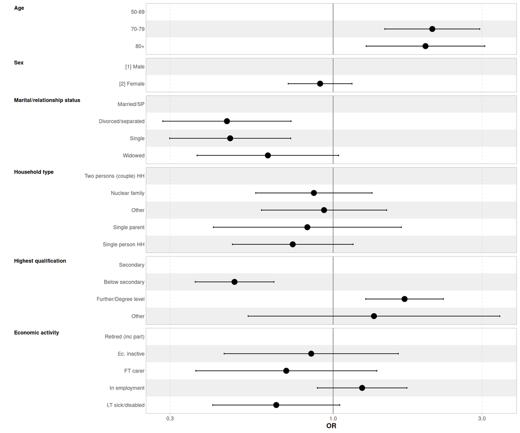

**6.2 SEV + IVS**

#### Stepwise models

| **Characteristic** | **M1** **OR**<sup>1</sup> | **M1** **95% CI** | **M2** **OR**<sup>1</sup> | **M2** **95% CI** | **M3** **OR**<sup>1</sup> | **M3** **95% CI** | **M4** **OR**<sup>1</sup> | **M4** **95% CI** | **M5** **OR**<sup>1</sup> | **M5** **95% CI** | **M6** **OR**<sup>1</sup> | **M6** **95% CI** | **M7** **OR**<sup>1</sup> | **M7** **95% CI** | **M8** **OR**<sup>1</sup> | **M8** **95% CI** | **M9** **OR**<sup>1</sup> | **M9** **95% CI** | **M10** **OR**<sup>1</sup> | **M10** **95% CI** | **M11** **OR**<sup>1</sup> | **M11** **95% CI** | **M12** **OR**<sup>1</sup> | **M12** **95% CI** | **M12** **OR**<sup>1</sup> | **M12** **95% CI** |
| --- | --- | --- | --- | --- | --- | --- | --- | --- | --- | --- | --- | --- | --- | --- | --- | --- | --- | --- | --- | --- | --- | --- | --- | --- | --- | --- |
| Nr of health problems |  |  |  |  |  |  |  |  |  |  |  |  |  |  |  |  |  |  |  |  |  |  |  |  |  |  |
| None | — | — | — | — | — | — | — | — | — | — | — | — | — | — | — | — | — | — | — | — | — | — | — | — | — | — |
| 3-4 | 1.08 | 0.65, 1.78 | 1.22 | 0.72, 2.06 | 1.21 | 0.72, 2.05 | 1.29 | 0.76, 2.21 | 1.44 | 0.84, 2.46 | 1.44 | 0.84, 2.46 | 1.44 | 0.84, 2.47 | 1.46 | 0.84, 2.53 | 1.42 | 0.81, 2.47 | 1.33 | 0.77, 2.32 | 1.31 | 0.75, 2.28 | 1.13 | 0.64, 2.00 | 1.10 | 0.62, 1.95 |
| 5+ | 1.0 | 0.49, 2.02 | 1.10 | 0.51, 2.36 | 1.23 | 0.57, 2.66 | 1.24 | 0.56, 2.71 | 1.37 | 0.62, 3.04 | 1.27 | 0.57, 2.83 | 1.27 | 0.57, 2.84 | 1.35 | 0.59, 3.12 | 1.26 | 0.54, 2.93 | 1.24 | 0.52, 2.92 | 1.23 | 0.52, 2.90 | 0.76 | 0.32, 1.84 | 0.72 | 0.30, 1.74 |
| One | 1.75*** | 1.28, 2.40 | 1.94*** | 1.41, 2.68 | 1.91*** | 1.38, 2.63 | 1.93*** | 1.39, 2.67 | 1.86*** | 1.34, 2.58 | 1.76*** | 1.26, 2.45 | 1.76*** | 1.26, 2.45 | 1.84*** | 1.32, 2.58 | 1.83*** | 1.30, 2.56 | 1.77*** | 1.26, 2.49 | 1.74** | 1.24, 2.44 | 1.71** | 1.21, 2.41 | 1.71** | 1.21, 2.41 |
| Two | 0.89 | 0.62, 1.28 | 1.02 | 0.70, 1.50 | 1.08 | 0.73, 1.59 | 1.08 | 0.73, 1.60 | 1.12 | 0.76, 1.67 | 1.05 | 0.70, 1.57 | 1.05 | 0.70, 1.57 | 1.09 | 0.73, 1.64 | 1.02 | 0.68, 1.54 | 0.99 | 0.65, 1.50 | 0.97 | 0.64, 1.47 | 1.01 | 0.66, 1.54 | 1.01 | 0.66, 1.54 |
| Self-rated health |  |  |  |  |  |  |  |  |  |  |  |  |  |  |  |  |  |  |  |  |  |  |  |  |  |  |
| Very good/good |  |  | — | — | — | — | — | — | — | — | — | — | — | — | — | — | — | — | — | — | — | — | — | — | — | — |
| Fair |  |  | 0.60*** | 0.45, 0.80 | 0.62** | 0.46, 0.83 | 0.67** | 0.50, 0.90 | 0.66** | 0.48, 0.89 | 0.68* | 0.50, 0.92 | 0.68* | 0.50, 0.93 | 0.66** | 0.49, 0.91 | 0.68* | 0.50, 0.93 | 0.69* | 0.51, 0.95 | 0.73 | 0.53, 1.00 | 0.80 | 0.58, 1.11 | 0.82 | 0.59, 1.13 |
| Poor |  |  | 0.76 | 0.49, 1.18 | 0.79 | 0.51, 1.24 | 0.90 | 0.57, 1.41 | 0.95 | 0.59, 1.51 | 1.09 | 0.67, 1.75 | 1.08 | 0.67, 1.74 | 1.02 | 0.63, 1.67 | 1.06 | 0.65, 1.73 | 1.07 | 0.66, 1.75 | 1.10 | 0.67, 1.81 | 1.39 | 0.84, 2.31 | 1.47 | 0.88, 2.47 |
| Subj. financial situation |  |  |  |  |  |  |  |  |  |  |  |  |  |  |  |  |  |  |  |  |  |  |  |  |  |  |
| Coping on present income |  |  |  |  | — | — | — | — | — | — | — | — | — | — | — | — | — | — | — | — | — | — | — | — | — | — |
| Living comfortably on present income |  |  |  |  | 1.37* | 1.04, 1.79 | 1.31 | 0.99, 1.72 | 1.38* | 1.04, 1.82 | 1.39* | 1.05, 1.84 | 1.39* | 1.05, 1.84 | 1.27 | 0.95, 1.69 | 1.27 | 0.95, 1.69 | 1.29 | 0.97, 1.73 | 1.32 | 0.99, 1.76 | 1.25 | 0.93, 1.68 | 1.24 | 0.93, 1.67 |
| Difficult on present income |  |  |  |  | 0.91 | 0.61, 1.36 | 0.93 | 0.63, 1.40 | 0.95 | 0.63, 1.43 | 0.93 | 0.62, 1.40 | 0.94 | 0.62, 1.41 | 0.89 | 0.58, 1.36 | 0.92 | 0.60, 1.40 | 0.95 | 0.62, 1.45 | 0.99 | 0.64, 1.51 | 0.92 | 0.60, 1.42 | 0.93 | 0.60, 1.43 |
| Very difficult on present income |  |  |  |  | 0.77 | 0.38, 1.56 | 0.91 | 0.45, 1.87 | 1.18 | 0.57, 2.47 | 1.29 | 0.62, 2.70 | 1.27 | 0.61, 2.66 | 1.38 | 0.65, 2.93 | 1.41 | 0.66, 2.99 | 1.41 | 0.66, 3.01 | 1.52 | 0.71, 3.25 | 1.25 | 0.58, 2.69 | 1.25 | 0.58, 2.71 |
| Feels lonely? |  |  |  |  |  |  |  |  |  |  |  |  |  |  |  |  |  |  |  |  |  |  |  |  |  |  |
| None/almost none of the time |  |  |  |  |  |  | — | — | — | — | — | — | — | — | — | — | — | — | — | — | — | — | — | — | — | — |
| Most/all of the time |  |  |  |  |  |  | 0.55* | 0.34, 0.89 | 0.63 | 0.38, 1.03 | 0.68 | 0.41, 1.13 | 0.69 | 0.41, 1.14 | 0.69 | 0.41, 1.16 | 0.70 | 0.42, 1.18 | 0.72 | 0.42, 1.22 | 0.70 | 0.41, 1.19 | 0.74 | 0.43, 1.26 | 0.72 | 0.43, 1.23 |
| Some of the time |  |  |  |  |  |  | 0.45*** | 0.34, 0.60 | 0.43*** | 0.32, 0.57 | 0.44*** | 0.33, 0.59 | 0.43*** | 0.32, 0.58 | 0.44*** | 0.33, 0.59 | 0.43*** | 0.32, 0.58 | 0.42*** | 0.31, 0.57 | 0.42*** | 0.31, 0.57 | 0.42*** | 0.31, 0.57 | 0.43*** | 0.31, 0.58 |
| Feels happy? |  |  |  |  |  |  |  |  |  |  |  |  |  |  |  |  |  |  |  |  |  |  |  |  |  |  |
| 1st quartile - least happy |  |  |  |  |  |  |  |  | — | — | — | — | — | — | — | — | — | — | — | — | — | — | — | — | — | — |
| 2nd qtile |  |  |  |  |  |  |  |  | 2.28*** | 1.49, 3.47 | 2.34*** | 1.53, 3.58 | 2.31*** | 1.51, 3.54 | 2.43*** | 1.58, 3.75 | 2.47*** | 1.60, 3.81 | 2.60*** | 1.67, 4.04 | 2.73*** | 1.75, 4.26 | 2.42*** | 1.54, 3.80 | 2.43*** | 1.55, 3.81 |
| 3rd qtile |  |  |  |  |  |  |  |  | 1.83** | 1.22, 2.76 | 1.83** | 1.22, 2.75 | 1.81** | 1.20, 2.73 | 1.92** | 1.27, 2.90 | 1.94** | 1.29, 2.93 | 1.94** | 1.28, 2.94 | 2.03*** | 1.33, 3.09 | 1.86** | 1.21, 2.84 | 1.87** | 1.22, 2.87 |
| 4th qtile |  |  |  |  |  |  |  |  | 1.37 | 0.93, 2.03 | 1.35 | 0.91, 2.00 | 1.33 | 0.90, 1.98 | 1.38 | 0.93, 2.06 | 1.39 | 0.93, 2.07 | 1.38 | 0.92, 2.06 | 1.43 | 0.95, 2.15 | 1.40 | 0.93, 2.11 | 1.41 | 0.93, 2.13 |
| Meet friends/relatives? |  |  |  |  |  |  |  |  |  |  |  |  |  |  |  |  |  |  |  |  |  |  |  |  |  |  |
| Daily or less |  |  |  |  |  |  |  |  |  |  | — | — | — | — | — | — | — | — | — | — | — | — | — | — | — | — |
| Monthly or less |  |  |  |  |  |  |  |  |  |  | 0.70* | 0.51, 0.97 | 0.71* | 0.51, 0.97 | 0.73 | 0.53, 1.02 | 0.75 | 0.54, 1.04 | 0.76 | 0.54, 1.05 | 0.82 | 0.59, 1.15 | 0.88 | 0.63, 1.24 | 0.89 | 0.63, 1.25 |
| Weekly or less |  |  |  |  |  |  |  |  |  |  | 1.22 | 0.91, 1.65 | 1.22 | 0.91, 1.65 | 1.23 | 0.91, 1.67 | 1.27 | 0.94, 1.73 | 1.24 | 0.91, 1.69 | 1.31 | 0.96, 1.79 | 1.31 | 0.95, 1.79 | 1.30 | 0.95, 1.78 |
| Religious attendence |  |  |  |  |  |  |  |  |  |  |  |  |  |  |  |  |  |  |  |  |  |  |  |  |  |  |
| Rarely or never |  |  |  |  |  |  |  |  |  |  |  |  | — | — | — | — | — | — | — | — | — | — | — | — | — | — |
| Less than weekly |  |  |  |  |  |  |  |  |  |  |  |  | 1.21 | 0.83, 1.76 | 1.34 | 0.91, 1.97 | 1.31 | 0.88, 1.93 | 1.36 | 0.91, 2.01 | 1.28 | 0.86, 1.91 | 1.27 | 0.85, 1.90 | 1.25 | 0.84, 1.87 |
| Once a week or more |  |  |  |  |  |  |  |  |  |  |  |  | 0.95 | 0.64, 1.39 | 1.04 | 0.70, 1.54 | 1.04 | 0.70, 1.53 | 1.08 | 0.73, 1.61 | 1.04 | 0.70, 1.55 | 1.07 | 0.71, 1.61 | 1.09 | 0.72, 1.64 |
| Trade-union etc member? |  |  |  |  |  |  |  |  |  |  |  |  |  |  |  |  |  |  |  |  |  |  |  |  |  |  |
| No |  |  |  |  |  |  |  |  |  |  |  |  |  |  | — | — | — | — | — | — | — | — | — | — | — | — |
| Yes, currently |  |  |  |  |  |  |  |  |  |  |  |  |  |  | 4.46*** | 2.52, 7.89 | 4.54*** | 2.56, 8.04 | 5.02*** | 2.80, 8.99 | 5.16*** | 2.87, 9.28 | 5.46*** | 3.00, 9.93 | 5.52*** | 3.04, 10.0 |
| Yes, previously |  |  |  |  |  |  |  |  |  |  |  |  |  |  | 2.00*** | 1.50, 2.68 | 1.96*** | 1.46, 2.62 | 2.08*** | 1.54, 2.82 | 2.12*** | 1.57, 2.88 | 2.12*** | 1.56, 2.88 | 2.11*** | 1.55, 2.87 |
| Whether does caring/housework? |  |  |  |  |  |  |  |  |  |  |  |  |  |  |  |  |  |  |  |  |  |  |  |  |  |  |
| Did not report |  |  |  |  |  |  |  |  |  |  |  |  |  |  |  |  | — | — | — | — | — | — | — | — | — | — |
| Did housework/cared for someone |  |  |  |  |  |  |  |  |  |  |  |  |  |  |  |  | 2.50* | 1.16, 5.40 | 2.43* | 1.12, 5.29 | 2.52* | 1.15, 5.52 | 2.25* | 1.00, 5.08 | 2.26* | 1.01, 5.10 |
| Organisation works/worked for |  |  |  |  |  |  |  |  |  |  |  |  |  |  |  |  |  |  |  |  |  |  |  |  |  |  |
| Private sector |  |  |  |  |  |  |  |  |  |  |  |  |  |  |  |  |  |  | — | — | — | — | — | — | — | — |
| Government (inc. local) |  |  |  |  |  |  |  |  |  |  |  |  |  |  |  |  |  |  | 1.75* | 1.05, 2.90 | 1.73* | 1.04, 2.87 | 1.80* | 1.08, 3.02 | 1.82* | 1.09, 3.04 |
| Other public |  |  |  |  |  |  |  |  |  |  |  |  |  |  |  |  |  |  | 0.75 | 0.52, 1.06 | 0.77 | 0.54, 1.09 | 0.74 | 0.52, 1.06 | 0.74 | 0.52, 1.07 |
| Other/DNA |  |  |  |  |  |  |  |  |  |  |  |  |  |  |  |  |  |  | 0.98 | 0.49, 1.95 | 0.91 | 0.46, 1.83 | 0.82 | 0.40, 1.65 | 0.81 | 0.40, 1.64 |
| Self-employed |  |  |  |  |  |  |  |  |  |  |  |  |  |  |  |  |  |  | 1.76* | 1.08, 2.88 | 1.74* | 1.07, 2.85 | 1.52 | 0.92, 2.51 | 1.52 | 0.92, 2.51 |
| State-owned |  |  |  |  |  |  |  |  |  |  |  |  |  |  |  |  |  |  | 0.84 | 0.33, 2.16 | 0.84 | 0.32, 2.15 | 0.64 | 0.25, 1.61 | 0.60 | 0.24, 1.53 |
| Whether volunteers |  |  |  |  |  |  |  |  |  |  |  |  |  |  |  |  |  |  |  |  |  |  |  |  |  |  |
| Yes |  |  |  |  |  |  |  |  |  |  |  |  |  |  |  |  |  |  |  |  | — | — | — | — | — | — |
| No |  |  |  |  |  |  |  |  |  |  |  |  |  |  |  |  |  |  |  |  | 0.60** | 0.42, 0.85 | 0.68* | 0.48, 0.98 | 0.69* | 0.48, 0.99 |
| Interest in politics |  |  |  |  |  |  |  |  |  |  |  |  |  |  |  |  |  |  |  |  |  |  |  |  |  |  |
| Interested in politics |  |  |  |  |  |  |  |  |  |  |  |  |  |  |  |  |  |  |  |  |  |  | — | — | — | — |
| Not interested in politics |  |  |  |  |  |  |  |  |  |  |  |  |  |  |  |  |  |  |  |  |  |  | 0.41*** | 0.31, 0.55 | 0.42*** | 0.32, 0.55 |
| Internet usage |  |  |  |  |  |  |  |  |  |  |  |  |  |  |  |  |  |  |  |  |  |  |  |  |  |  |
| Most days/ every day |  |  |  |  |  |  |  |  |  |  |  |  |  |  |  |  |  |  |  |  |  |  |  |  | — | — |
| Never |  |  |  |  |  |  |  |  |  |  |  |  |  |  |  |  |  |  |  |  |  |  |  |  | 0.78 | 0.50, 1.20 |
| Occasionally/ a few times a week |  |  |  |  |  |  |  |  |  |  |  |  |  |  |  |  |  |  |  |  |  |  |  |  | 1.14 | 0.71, 1.82 |
| AIC | 1,827 |  | 1,820 |  | 1,817 |  | 1,791 |  | 1,776 |  | 1,768 |  | 1,771 |  | 1,727 |  | 1,723 |  | 1,715 |  | 1,709 |  | 1,674 |  | 1,675 |  |
| Log-likelihood | -891 |  | -886 |  | -882 |  | -866 |  | -856 |  | -850 |  | -849 |  | -826 |  | -823 |  | -813 |  | -810 |  | -791 |  | -790 |  |
| No. Obs. | 821 |  | 821 |  | 821 |  | 821 |  | 821 |  | 821 |  | 821 |  | 821 |  | 821 |  | 821 |  | 821 |  | 821 |  | 821 |  |

<sup>1</sup> *p<0.05; **p<0.01;*** p<0.001  
Abbreviations: CI = Confidence Interval, OR = Odds Ratio

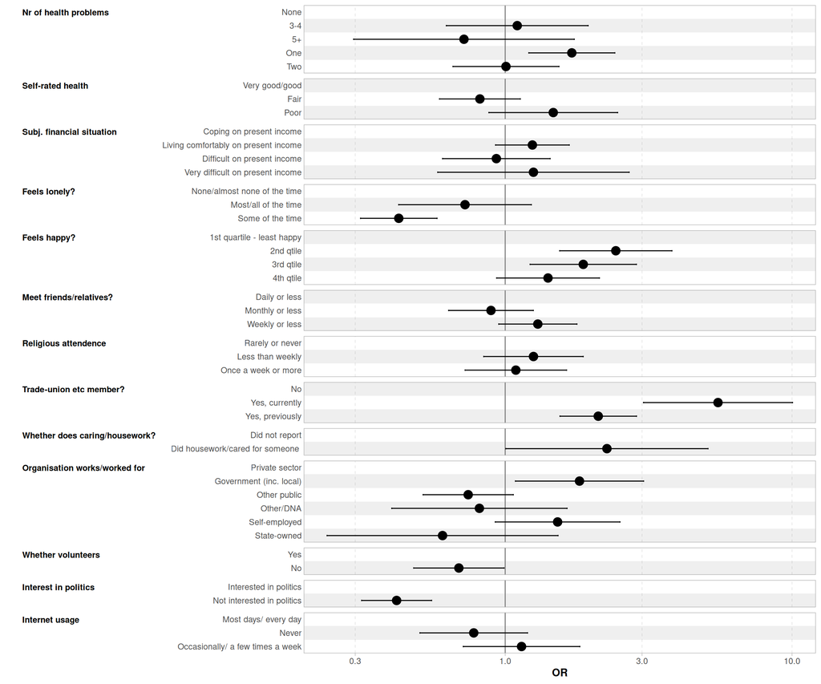

**6.3 SEV + IVS + interactions**

#### Stepwise models

| **Characteristic** | **M1** **OR**<sup>1</sup> | **M1** **95% CI** | **M2** **OR**<sup>1</sup> | **M2** **95% CI** | **M3** **OR**<sup>1</sup> | **M3** **95% CI** | **M4** **OR**<sup>1</sup> | **M4** **95% CI** | **M5** **OR**<sup>1</sup> | **M5** **95% CI** | **M6** **OR**<sup>1</sup> | **M6** **95% CI** | **M7** **OR**<sup>1</sup> | **M7** **95% CI** | **M8** **OR**<sup>1</sup> | **M8** **95% CI** | **M9** **OR**<sup>1</sup> | **M9** **95% CI** | **M10** **OR**<sup>1</sup> | **M10** **95% CI** | **M11** **OR**<sup>1</sup> | **M11** **95% CI** | **M12** **OR**<sup>1</sup> | **M12** **95% CI** | **M13** **OR**<sup>1</sup> | **M13** **95% CI** |
| --- | --- | --- | --- | --- | --- | --- | --- | --- | --- | --- | --- | --- | --- | --- | --- | --- | --- | --- | --- | --- | --- | --- | --- | --- | --- | --- |
| Age |  |  |  |  |  |  |  |  |  |  |  |  |  |  |  |  |  |  |  |  |  |  |  |  |  |  |
| 50-69 | — | — | — | — | — | — | — | — | — | — | — | — | — | — | — | — | — | — | — | — | — | — | — | — | — | — |
| 70-79 | 2.26** | 1.35, 3.79 | 2.42*** | 1.44, 4.06 | 2.51*** | 1.49, 4.24 | 2.91*** | 1.70, 4.96 | 2.78*** | 1.63, 4.75 | 2.87*** | 1.67, 4.91 | 2.84*** | 1.66, 4.86 | 2.73*** | 1.59, 4.70 | 2.75*** | 1.60, 4.73 | 2.55*** | 1.48, 4.39 | 2.38** | 1.37, 4.13 | 2.37** | 1.35, 4.13 | 2.43** | 1.38, 4.26 |
| 80+ | 1.13 | 0.65, 1.94 | 1.14 | 0.66, 1.97 | 1.15 | 0.67, 2.00 | 1.30 | 0.74, 2.27 | 1.26 | 0.72, 2.21 | 1.32 | 0.75, 2.33 | 1.32 | 0.75, 2.34 | 1.31 | 0.74, 2.34 | 1.29 | 0.73, 2.31 | 1.17 | 0.65, 2.10 | 1.10 | 0.61, 1.98 | 1.15 | 0.64, 2.09 | 1.23 | 0.67, 2.26 |
| Age by sex |  |  |  |  |  |  |  |  |  |  |  |  |  |  |  |  |  |  |  |  |  |  |  |  |  |  |
| 70-79 * [2] Female | 0.79 | 0.43, 1.45 | 0.74 | 0.40, 1.37 | 0.72 | 0.39, 1.34 | 0.63 | 0.34, 1.19 | 0.69 | 0.37, 1.31 | 0.64 | 0.34, 1.22 | 0.66 | 0.34, 1.24 | 0.84 | 0.44, 1.61 | 0.85 | 0.44, 1.63 | 0.95 | 0.49, 1.84 | 1.00 | 0.52, 1.94 | 1.01 | 0.52, 1.97 | 0.99 | 0.51, 1.94 |
| 80+ * [2] Female | 2.04 | 0.99, 4.22 | 1.98 | 0.96, 4.10 | 1.96 | 0.94, 4.06 | 1.89 | 0.90, 3.96 | 1.89 | 0.90, 3.98 | 1.67 | 0.79, 3.54 | 1.71 | 0.81, 3.63 | 2.30* | 1.06, 4.95 | 2.38* | 1.10, 5.14 | 2.62* | 1.20, 5.71 | 2.65* | 1.21, 5.81 | 2.32* | 1.05, 5.14 | 2.42* | 1.09, 5.40 |
| Nr of health problems |  |  |  |  |  |  |  |  |  |  |  |  |  |  |  |  |  |  |  |  |  |  |  |  |  |  |
| None | — | — | — | — | — | — | — | — | — | — | — | — | — | — | — | — | — | — | — | — | — | — | — | — | — | — |
| 3-4 | 1.06 | 0.64, 1.76 | 1.20 | 0.71, 2.04 | 1.20 | 0.71, 2.03 | 1.27 | 0.74, 2.17 | 1.41 | 0.82, 2.43 | 1.41 | 0.82, 2.43 | 1.42 | 0.82, 2.44 | 1.43 | 0.83, 2.48 | 1.39 | 0.79, 2.42 | 1.30 | 0.74, 2.26 | 1.27 | 0.73, 2.22 | 1.10 | 0.62, 1.94 | 1.06 | 0.60, 1.88 |
| 5+ | 1.02 | 0.50, 2.08 | 1.12 | 0.52, 2.41 | 1.25 | 0.58, 2.70 | 1.23 | 0.56, 2.71 | 1.37 | 0.62, 3.03 | 1.27 | 0.57, 2.83 | 1.27 | 0.57, 2.84 | 1.35 | 0.59, 3.11 | 1.26 | 0.54, 2.92 | 1.25 | 0.53, 2.95 | 1.24 | 0.53, 2.94 | 0.77 | 0.32, 1.86 | 0.72 | 0.30, 1.75 |
| One | 1.73*** | 1.27, 2.37 | 1.93*** | 1.40, 2.66 | 1.89*** | 1.37, 2.61 | 1.93*** | 1.39, 2.67 | 1.86*** | 1.34, 2.58 | 1.76*** | 1.27, 2.46 | 1.76*** | 1.26, 2.45 | 1.82*** | 1.30, 2.55 | 1.80*** | 1.28, 2.52 | 1.73** | 1.23, 2.44 | 1.69** | 1.20, 2.38 | 1.67** | 1.18, 2.36 | 1.66** | 1.17, 2.35 |
| Two | 0.88 | 0.61, 1.27 | 1.01 | 0.69, 1.49 | 1.06 | 0.72, 1.57 | 1.06 | 0.71, 1.57 | 1.11 | 0.75, 1.65 | 1.04 | 0.70, 1.55 | 1.04 | 0.69, 1.56 | 1.08 | 0.72, 1.62 | 1.01 | 0.67, 1.52 | 0.97 | 0.64, 1.48 | 0.95 | 0.63, 1.45 | 0.99 | 0.64, 1.51 | 0.99 | 0.64, 1.51 |
| Self-rated health |  |  |  |  |  |  |  |  |  |  |  |  |  |  |  |  |  |  |  |  |  |  |  |  |  |  |
| Very good/good |  |  | — | — | — | — | — | — | — | — | — | — | — | — | — | — | — | — | — | — | — | — | — | — | — | — |
| Fair |  |  | 0.60*** | 0.45, 0.79 | 0.61*** | 0.46, 0.82 | 0.66** | 0.49, 0.88 | 0.64** | 0.47, 0.88 | 0.66** | 0.49, 0.90 | 0.67* | 0.49, 0.91 | 0.65** | 0.48, 0.89 | 0.67* | 0.49, 0.92 | 0.69* | 0.50, 0.95 | 0.73 | 0.53, 1.00 | 0.80 | 0.58, 1.11 | 0.81 | 0.59, 1.13 |
| Poor |  |  | 0.77 | 0.50, 1.19 | 0.80 | 0.51, 1.25 | 0.91 | 0.58, 1.43 | 0.95 | 0.59, 1.51 | 1.08 | 0.67, 1.74 | 1.07 | 0.66, 1.73 | 1.03 | 0.63, 1.68 | 1.07 | 0.65, 1.75 | 1.09 | 0.66, 1.79 | 1.12 | 0.68, 1.85 | 1.40 | 0.84, 2.34 | 1.49 | 0.89, 2.50 |
| Subj. financial situation |  |  |  |  |  |  |  |  |  |  |  |  |  |  |  |  |  |  |  |  |  |  |  |  |  |  |
| Coping on present income |  |  |  |  | — | — | — | — | — | — | — | — | — | — | — | — | — | — | — | — | — | — | — | — | — | — |
| Living comfortably on present income |  |  |  |  | 1.37* | 1.05, 1.80 | 1.31 | 1.00, 1.73 | 1.38* | 1.04, 1.83 | 1.39* | 1.05, 1.84 | 1.39* | 1.05, 1.84 | 1.27 | 0.95, 1.70 | 1.27 | 0.95, 1.70 | 1.29 | 0.97, 1.73 | 1.32 | 0.98, 1.77 | 1.25 | 0.93, 1.68 | 1.24 | 0.92, 1.67 |
| Difficult on present income |  |  |  |  | 0.90 | 0.61, 1.35 | 0.92 | 0.62, 1.38 | 0.93 | 0.62, 1.40 | 0.91 | 0.61, 1.38 | 0.92 | 0.61, 1.39 | 0.88 | 0.58, 1.34 | 0.90 | 0.59, 1.38 | 0.94 | 0.61, 1.44 | 0.98 | 0.64, 1.50 | 0.92 | 0.59, 1.41 | 0.93 | 0.60, 1.43 |
| Very difficult on present income |  |  |  |  | 0.81 | 0.40, 1.66 | 0.99 | 0.48, 2.04 | 1.25 | 0.60, 2.62 | 1.38 | 0.65, 2.89 | 1.35 | 0.64, 2.85 | 1.43 | 0.67, 3.05 | 1.46 | 0.69, 3.11 | 1.45 | 0.68, 3.09 | 1.55 | 0.72, 3.32 | 1.27 | 0.59, 2.74 | 1.28 | 0.59, 2.76 |
| Feels lonely? |  |  |  |  |  |  |  |  |  |  |  |  |  |  |  |  |  |  |  |  |  |  |  |  |  |  |
| None/almost none of the time |  |  |  |  |  |  | — | — | — | — | — | — | — | — | — | — | — | — | — | — | — | — | — | — | — | — |
| Most/all of the time |  |  |  |  |  |  | 0.56* | 0.34, 0.91 | 0.63 | 0.38, 1.04 | 0.69 | 0.41, 1.14 | 0.69 | 0.42, 1.15 | 0.70 | 0.41, 1.17 | 0.71 | 0.42, 1.19 | 0.72 | 0.42, 1.22 | 0.70 | 0.41, 1.19 | 0.74 | 0.43, 1.26 | 0.72 | 0.42, 1.23 |
| Some of the time |  |  |  |  |  |  | 0.44*** | 0.33, 0.59 | 0.42*** | 0.32, 0.57 | 0.43*** | 0.32, 0.58 | 0.43*** | 0.32, 0.57 | 0.44*** | 0.32, 0.59 | 0.43*** | 0.32, 0.58 | 0.42*** | 0.31, 0.57 | 0.42*** | 0.31, 0.57 | 0.42*** | 0.31, 0.58 | 0.43*** | 0.31, 0.58 |
| Feels happy? |  |  |  |  |  |  |  |  |  |  |  |  |  |  |  |  |  |  |  |  |  |  |  |  |  |  |
| 1st quartile - least happy |  |  |  |  |  |  |  |  | — | — | — | — | — | — | — | — | — | — | — | — | — | — | — | — | — | — |
| 2nd qtile |  |  |  |  |  |  |  |  | 2.23*** | 1.46, 3.41 | 2.29*** | 1.50, 3.51 | 2.26*** | 1.48, 3.47 | 2.41*** | 1.56, 3.72 | 2.45*** | 1.58, 3.79 | 2.61*** | 1.67, 4.06 | 2.76*** | 1.77, 4.32 | 2.46*** | 1.56, 3.86 | 2.47*** | 1.57, 3.89 |
| 3rd qtile |  |  |  |  |  |  |  |  | 1.78** | 1.18, 2.69 | 1.77** | 1.18, 2.67 | 1.76** | 1.16, 2.65 | 1.89** | 1.25, 2.86 | 1.91** | 1.26, 2.89 | 1.92** | 1.26, 2.92 | 2.02** | 1.32, 3.08 | 1.86** | 1.21, 2.85 | 1.87** | 1.22, 2.88 |
| 4th qtile |  |  |  |  |  |  |  |  | 1.35 | 0.91, 2.00 | 1.33 | 0.90, 1.97 | 1.31 | 0.88, 1.94 | 1.38 | 0.92, 2.05 | 1.38 | 0.93, 2.07 | 1.38 | 0.92, 2.07 | 1.44 | 0.95, 2.16 | 1.41 | 0.93, 2.13 | 1.42 | 0.94, 2.15 |
| Meet friends/relatives? |  |  |  |  |  |  |  |  |  |  |  |  |  |  |  |  |  |  |  |  |  |  |  |  |  |  |
| Daily or less |  |  |  |  |  |  |  |  |  |  | — | — | — | — | — | — | — | — | — | — | — | — | — | — | — | — |
| Monthly or less |  |  |  |  |  |  |  |  |  |  | 0.71* | 0.51, 0.98 | 0.71* | 0.51, 0.98 | 0.75 | 0.54, 1.04 | 0.77 | 0.55, 1.07 | 0.78 | 0.56, 1.09 | 0.85 | 0.60, 1.19 | 0.91 | 0.64, 1.27 | 0.92 | 0.65, 1.29 |
| Weekly or less |  |  |  |  |  |  |  |  |  |  | 1.21 | 0.90, 1.63 | 1.21 | 0.90, 1.63 | 1.22 | 0.90, 1.65 | 1.26 | 0.93, 1.71 | 1.23 | 0.90, 1.67 | 1.30 | 0.95, 1.77 | 1.28 | 0.94, 1.76 | 1.28 | 0.93, 1.75 |
| Religious attendence |  |  |  |  |  |  |  |  |  |  |  |  |  |  |  |  |  |  |  |  |  |  |  |  |  |  |
| Rarely or never |  |  |  |  |  |  |  |  |  |  |  |  | — | — | — | — | — | — | — | — | — | — | — | — | — | — |
| Less than weekly |  |  |  |  |  |  |  |  |  |  |  |  | 1.21 | 0.83, 1.76 | 1.36 | 0.92, 2.01 | 1.33 | 0.90, 1.97 | 1.39 | 0.94, 2.07 | 1.32 | 0.89, 1.97 | 1.31 | 0.87, 1.95 | 1.29 | 0.86, 1.92 |
| Once a week or more |  |  |  |  |  |  |  |  |  |  |  |  | 0.94 | 0.64, 1.38 | 1.03 | 0.69, 1.52 | 1.02 | 0.69, 1.51 | 1.07 | 0.72, 1.59 | 1.03 | 0.69, 1.53 | 1.06 | 0.71, 1.59 | 1.08 | 0.72, 1.62 |
| Trade-union etc member? |  |  |  |  |  |  |  |  |  |  |  |  |  |  |  |  |  |  |  |  |  |  |  |  |  |  |
| No |  |  |  |  |  |  |  |  |  |  |  |  |  |  | — | — | — | — | — | — | — | — | — | — | — | — |
| Yes, currently |  |  |  |  |  |  |  |  |  |  |  |  |  |  | 4.55*** | 2.57, 8.05 | 4.64*** | 2.62, 8.22 | 5.17*** | 2.89, 9.27 | 5.34*** | 2.97, 9.60 | 5.64*** | 3.10, 10.3 | 5.72*** | 3.14, 10.4 |
| Yes, previously |  |  |  |  |  |  |  |  |  |  |  |  |  |  | 2.03*** | 1.52, 2.73 | 1.99*** | 1.48, 2.67 | 2.14*** | 1.58, 2.91 | 2.19*** | 1.61, 2.98 | 2.17*** | 1.59, 2.96 | 2.17*** | 1.59, 2.96 |
| Whether does caring/housework? |  |  |  |  |  |  |  |  |  |  |  |  |  |  |  |  |  |  |  |  |  |  |  |  |  |  |
| Did not report |  |  |  |  |  |  |  |  |  |  |  |  |  |  |  |  | — | — | — | — | — | — | — | — | — | — |
| Did housework/cared for someone |  |  |  |  |  |  |  |  |  |  |  |  |  |  |  |  | 2.56* | 1.18, 5.56 | 2.52* | 1.15, 5.51 | 2.60* | 1.18, 5.74 | 2.32* | 1.02, 5.24 | 2.33* | 1.03, 5.27 |
| Organisation works/worked for |  |  |  |  |  |  |  |  |  |  |  |  |  |  |  |  |  |  |  |  |  |  |  |  |  |  |
| Private sector |  |  |  |  |  |  |  |  |  |  |  |  |  |  |  |  |  |  | — | — | — | — | — | — | — | — |
| Government (inc. local) |  |  |  |  |  |  |  |  |  |  |  |  |  |  |  |  |  |  | 1.76* | 1.06, 2.92 | 1.75* | 1.05, 2.90 | 1.82* | 1.09, 3.05 | 1.84* | 1.10, 3.08 |
| Other public |  |  |  |  |  |  |  |  |  |  |  |  |  |  |  |  |  |  | 0.75 | 0.52, 1.07 | 0.77 | 0.54, 1.10 | 0.74 | 0.52, 1.07 | 0.75 | 0.52, 1.07 |
| Other/DNA |  |  |  |  |  |  |  |  |  |  |  |  |  |  |  |  |  |  | 1.02 | 0.52, 2.04 | 0.95 | 0.48, 1.91 | 0.85 | 0.42, 1.72 | 0.85 | 0.42, 1.72 |
| Self-employed |  |  |  |  |  |  |  |  |  |  |  |  |  |  |  |  |  |  | 1.81* | 1.10, 2.97 | 1.80* | 1.09, 2.94 | 1.57 | 0.95, 2.59 | 1.57 | 0.95, 2.60 |
| State-owned |  |  |  |  |  |  |  |  |  |  |  |  |  |  |  |  |  |  | 0.80 | 0.32, 2.05 | 0.80 | 0.31, 2.04 | 0.61 | 0.24, 1.54 | 0.58 | 0.23, 1.45 |
| Whether volunteers |  |  |  |  |  |  |  |  |  |  |  |  |  |  |  |  |  |  |  |  |  |  |  |  |  |  |
| Yes |  |  |  |  |  |  |  |  |  |  |  |  |  |  |  |  |  |  |  |  | — | — | — | — | — | — |
| No |  |  |  |  |  |  |  |  |  |  |  |  |  |  |  |  |  |  |  |  | 0.60** | 0.42, 0.85 | 0.68* | 0.47, 0.98 | 0.69* | 0.48, 0.99 |
| Interest in politics |  |  |  |  |  |  |  |  |  |  |  |  |  |  |  |  |  |  |  |  |  |  |  |  |  |  |
| Interested in politics |  |  |  |  |  |  |  |  |  |  |  |  |  |  |  |  |  |  |  |  |  |  | — | — | — | — |
| Not interested in politics |  |  |  |  |  |  |  |  |  |  |  |  |  |  |  |  |  |  |  |  |  |  | 0.42*** | 0.32, 0.56 | 0.43*** | 0.32, 0.57 |
| Internet usage |  |  |  |  |  |  |  |  |  |  |  |  |  |  |  |  |  |  |  |  |  |  |  |  |  |  |
| Most days/ every day |  |  |  |  |  |  |  |  |  |  |  |  |  |  |  |  |  |  |  |  |  |  |  |  | — | — |
| Never |  |  |  |  |  |  |  |  |  |  |  |  |  |  |  |  |  |  |  |  |  |  |  |  | 0.75 | 0.49, 1.15 |
| Occasionally/ a few times a week |  |  |  |  |  |  |  |  |  |  |  |  |  |  |  |  |  |  |  |  |  |  |  |  | 1.14 | 0.71, 1.82 |
| AIC | 1,825 |  | 1,818 |  | 1,815 |  | 1,788 |  | 1,774 |  | 1,767 |  | 1,770 |  | 1,725 |  | 1,721 |  | 1,712 |  | 1,706 |  | 1,673 |  | 1,673 |  |
| Log-likelihood | -889 |  | -883 |  | -879 |  | -863 |  | -853 |  | -847 |  | -847 |  | -822 |  | -819 |  | -810 |  | -806 |  | -788 |  | -787 |  |
| No. Obs. | 821 |  | 821 |  | 821 |  | 821 |  | 821 |  | 821 |  | 821 |  | 821 |  | 821 |  | 821 |  | 821 |  | 821 |  | 821 |  |

<sup>1</sup> *p<0.05; **p<0.01;*** p<0.001  
Abbreviations: CI = Confidence Interval, OR = Odds Ratio

#### Coefficient plots of model 13

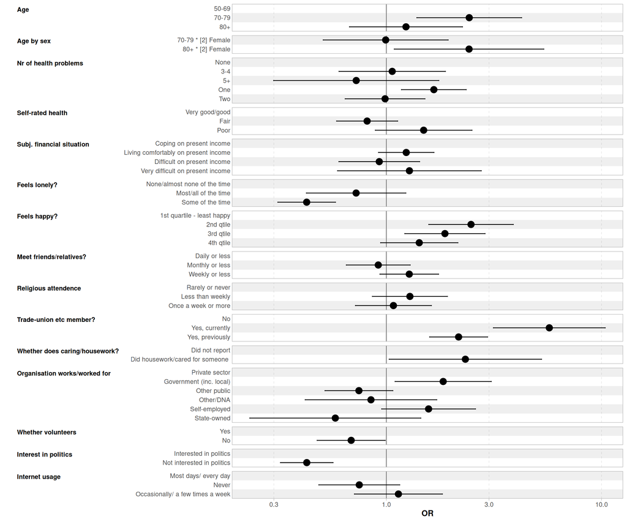

**6.4 SEV & interaction**

#### Stepwise models

| **Characteristic** | **M1** **OR**<sup>1</sup> | **M1** **95% CI** | **M2** **OR**<sup>1</sup> | **M2** **95% CI** | **M3** **OR**<sup>1</sup> | **M3** **95% CI** | **M4** **OR**<sup>1</sup> | **M4** **95% CI** | **M5** **OR**<sup>1</sup> | **M5** **95% CI** | **M6** **OR**<sup>1</sup> | **M6** **95% CI** | **M7** **OR**<sup>1</sup> | **M7** **95% CI** |
| --- | --- | --- | --- | --- | --- | --- | --- | --- | --- | --- | --- | --- | --- | --- |
| Age |  |  |  |  |  |  |  |  |  |  |  |  |  |  |
| 50-69 | — | — | — | — | — | — | — | — | — | — | — | — | — | — |
| 70-79 | 1.79*** | 1.36, 2.36 | 1.78*** | 1.35, 2.34 | 1.79*** | 1.34, 2.39 | 1.83*** | 1.37, 2.45 | 2.05*** | 1.52, 2.76 | 2.08*** | 1.46, 2.95 | 2.24** | 1.38, 3.64 |
| 80+ | 1.27 | 0.92, 1.77 | 1.26 | 0.91, 1.76 | 1.49* | 1.02, 2.17 | 1.58* | 1.07, 2.32 | 1.99*** | 1.34, 2.95 | 1.98** | 1.28, 3.06 | 1.30 | 0.77, 2.21 |
| Age by sex |  |  |  |  |  |  |  |  |  |  |  |  |  |  |
| 70-79 * [2] Female |  |  |  |  |  |  |  |  |  |  |  |  | 0.88 | 0.49, 1.56 |
| 80+ * [2] Female |  |  |  |  |  |  |  |  |  |  |  |  | 2.51* | 1.24, 5.10 |
| Sex |  |  |  |  |  |  |  |  |  |  |  |  |  |  |
| [1] Male |  |  | — | — | — | — | — | — | — | — | — | — | — | — |
| [2] Female |  |  | 0.87 | 0.70, 1.09 | 0.97 | 0.77, 1.22 | 0.94 | 0.75, 1.19 | 0.88 | 0.70, 1.11 | 0.91 | 0.72, 1.15 | 0.83 | 0.62, 1.11 |
| Marital/relationship status |  |  |  |  |  |  |  |  |  |  |  |  |  |  |
| Married/SP |  |  |  |  | — | — | — | — | — | — | — | — | — | — |
| Divorced/separated |  |  |  |  | 0.36*** | 0.27, 0.49 | 0.45*** | 0.28, 0.71 | 0.43*** | 0.27, 0.69 | 0.46** | 0.28, 0.73 | 0.46** | 0.28, 0.73 |
| Single |  |  |  |  | 0.37*** | 0.27, 0.51 | 0.45*** | 0.30, 0.70 | 0.45*** | 0.29, 0.70 | 0.47*** | 0.30, 0.73 | 0.45*** | 0.29, 0.71 |
| Widowed |  |  |  |  | 0.41*** | 0.28, 0.59 | 0.52* | 0.31, 0.87 | 0.61 | 0.36, 1.02 | 0.62 | 0.37, 1.04 | 0.57* | 0.34, 0.96 |
| Household type |  |  |  |  |  |  |  |  |  |  |  |  |  |  |
| Two persons (couple) HH |  |  |  |  |  |  | — | — | — | — | — | — | — | — |
| Nuclear family |  |  |  |  |  |  | 0.98 | 0.65, 1.48 | 0.91 | 0.60, 1.39 | 0.87 | 0.56, 1.33 | 0.88 | 0.57, 1.34 |
| Other |  |  |  |  |  |  | 0.93 | 0.60, 1.45 | 0.89 | 0.57, 1.39 | 0.94 | 0.59, 1.49 | 0.95 | 0.60, 1.50 |
| Single parent |  |  |  |  |  |  | 1.05 | 0.54, 2.05 | 0.92 | 0.47, 1.80 | 0.83 | 0.41, 1.65 | 0.87 | 0.43, 1.73 |
| Single person HH |  |  |  |  |  |  | 0.70 | 0.46, 1.08 | 0.74 | 0.48, 1.14 | 0.74 | 0.48, 1.16 | 0.74 | 0.47, 1.15 |
| Highest qualification |  |  |  |  |  |  |  |  |  |  |  |  |  |  |
| Secondary |  |  |  |  |  |  |  |  | — | — | — | — | — | — |
| Below secondary |  |  |  |  |  |  |  |  | 0.46*** | 0.34, 0.61 | 0.48*** | 0.36, 0.65 | 0.48*** | 0.36, 0.65 |
| Further/Degree level |  |  |  |  |  |  |  |  | 1.77*** | 1.33, 2.34 | 1.69*** | 1.27, 2.26 | 1.69*** | 1.27, 2.26 |
| Other |  |  |  |  |  |  |  |  | 1.45 | 0.57, 3.67 | 1.35 | 0.53, 3.42 | 1.41 | 0.55, 3.57 |
| Economic activity |  |  |  |  |  |  |  |  |  |  |  |  |  |  |
| Retired (inc part) |  |  |  |  |  |  |  |  |  |  | — | — | — | — |
| Ec. inactive |  |  |  |  |  |  |  |  |  |  | 0.85 | 0.45, 1.62 | 0.83 | 0.44, 1.58 |
| FT carer |  |  |  |  |  |  |  |  |  |  | 0.71 | 0.36, 1.38 | 0.72 | 0.37, 1.40 |
| In employment |  |  |  |  |  |  |  |  |  |  | 1.24 | 0.89, 1.72 | 1.22 | 0.88, 1.70 |
| LT sick/disabled |  |  |  |  |  |  |  |  |  |  | 0.66 | 0.41, 1.05 | 0.66 | 0.41, 1.06 |
| AIC | 2,103 |  | 2,103 |  | 2,039 |  | 2,042 |  | 1,969 |  | 1,967 |  | 1,962 |  |
| Log-likelihood | -1,048 |  | -1,048 |  | -1,012 |  | -1,010 |  | -971 |  | -966 |  | -961 |  |
| No. Obs. | 869 |  | 869 |  | 869 |  | 869 |  | 869 |  | 869 |  | 869 |  |

<sup>1</sup> *p<0.05; **p<0.01;*** p<0.001  
Abbreviations: CI = Confidence Interval, OR = Odds Ratio

#### Coefficient plot of Models 6

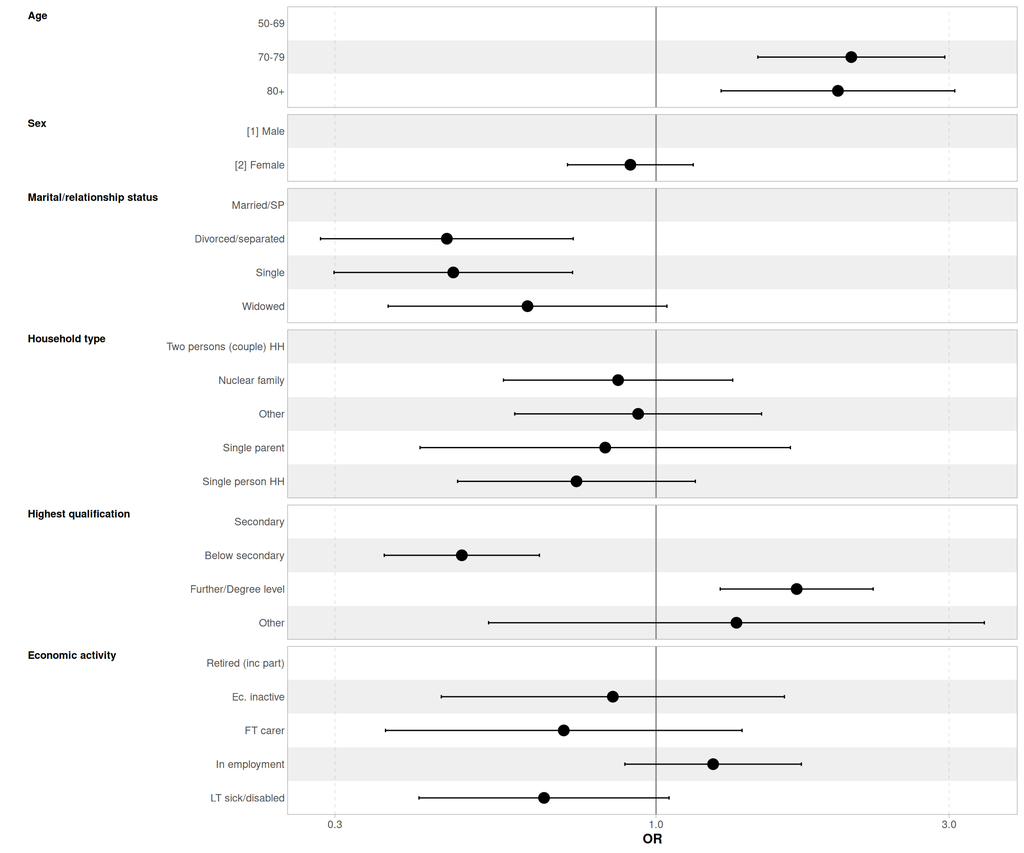

## Document version history

Version 3 - UK-only analysis on a separate page

Version 2:

- Amended reference categories for marital status and education in regression tables to match those fromn ELSA
- Changed health problems mention to impairing health problems mentioned
- Added two regression tables with the interaction between Age 3 categories and sex included

Initial version

#### *To do*:

1. Check if control for simplified country blocks hass an impact;
2. Improve landing page.

## Footnotes

[^1]: Israel, the Russian Federation and Turkey were not included in this analysis.
[^2]: Respondents aged 50 and over]